# Notebook

```python
from IPython import parallel

clients = parallel.Client() #a lightweight handle on all the engines of a cluster
clients.block = True  # use synchronous computations
print(clients.ids)

dview = clients[:] #dview = clients.direct_view()
dview.block = True
print(dview)

#from ggplot import * # does not work with python 3.4
from collections import OrderedDict
from scipy.stats.kde import gaussian_kde

import time
import getpass
import re
%pylab inline
```

```
[0, 1, 2, 3, 4, 5, 6, 7, 8, 9, 10, 11, 12, 13, 14, 15, 16, 17, 18, 19, 20, 21, 22, 23, 24, 25]
<DirectView [0, 1, 2, 3,...]>
```

```python
# do this from time to time, for clearing the memory!
dview.results.clear()
clients.results.clear()
clients.metadata.clear()
# check or replace ipcontroller_config.py for NoDB etc. options.
```

```python
%%px --local
from collections import Counter
from operator import itemgetter
from __future__ import division

import pandas as pd
import numpy as np
import datetime
import decimal
import getpass
import math
import glob
import copy
import re
import os

import warnings

from itertools import chain, combinations

warnings.filterwarnings('ignore')
pd.set_option('display.max_colwidth',2000)
```

```python
from datetime import datetime as dtdt
```

```python
etimedict= {'ajaaz_f11':dtdt(2011, 10, 15, 18, 45), 'ajaaz_f12':dtdt(2012, 8, 12, 16, 30), 'ajaaz_s11': dtdt(2011, 3, 6, 16, 30),\
 'ajafey_f11': dtdt(2011, 10, 23, 12, 30), 'ajafey_s11': dtdt(2011, 1, 19, 20, 45), 'ajapsv_f12': dtdt(2012, 12, 1, 20, 45),\
 'ajapsv_s12': dtdt(2012, 3, 25, 16, 30), 'ajatwe_f11': dtdt(2011, 9, 24, 20, 45), 'ajatwe_f12': dtdt(2012, 9, 29, 20, 45),\
 'ajatwe_s11': dtdt(2011, 5, 15, 14, 30), 'ajautr_f12': dtdt(2012, 10, 7, 12, 30), 'ajautr_s12': dtdt(2012, 2, 5, 12, 30),\
 'azaja_s12': dtdt(2012, 1, 22, 14, 30), 'azfey_f11': dtdt(2011, 9, 25, 12, 30), 'azfey_f12': dtdt(2012, 11, 25, 14, 30),\
 'azpsv_f11': dtdt(2011, 8, 7, 12, 30), 'azpsv_s11': dtdt(2011, 2, 12, 20, 45), 'aztwe_s11': dtdt(2011, 2, 27, 14, 30),\
 'aztwe_s12': dtdt(2012, 4, 11, 19, 0), 'azutr_f11': dtdt(2011, 11, 25, 20, 0), 'feyaja_f12': dtdt(2012, 10, 28, 12, 30),\
 'feyaja_s12': dtdt(2012, 1, 29, 12, 30), 'feyaz_s11': dtdt(2011, 4, 2, 20, 45), 'feyaz_s12': dtdt(2012, 4, 29, 14, 30),\
 'feypsv_f11': dtdt(2011, 12, 4, 12, 30), 'feypsv_s11': dtdt(2011, 4, 24, 14, 30), 'feytwe_f11': dtdt(2011, 12, 18, 14, 30),\
 'feyutr_s12': dtdt(2012, 3, 11, 14, 30), 'kondag12': dtdt(2012, 4, 30, 15, 0), 'pp12': dtdt(2012, 5, 26, 20, 0),\
 'psvaja_f11': dtdt(2011, 9, 18, 12, 30), 'psvaja_s11': dtdt(2011, 2, 27, 14, 30), 'psvaz_f12': dtdt(2012, 9, 2, 14, 30),\
 'psvaz_s12': dtdt(2012, 4, 14, 18, 45), 'psvfey_f12': dtdt(2012, 9, 23, 16, 30), 'psvfey_s12': dtdt(2012, 2, 26, 14, 30),\
 'psvtwe_f12': dtdt(2012, 12, 9, 16, 30), 'psvtwe_s12': dtdt(2012, 3, 4, 16, 30), 'psvutr_f11': dtdt(2011, 10, 15, 20, 45),\
 'psvutr_s11': dtdt(2011, 3, 20, 14, 30), 'tweaja_s12': dtdt(2012, 4, 29, 14, 30), 'tweaz_f11': dtdt(2011, 8, 13, 18, 45),\
 'tweaz_f12': dtdt(2012, 10, 7, 16, 30), 'twefey_f12': dtdt(2012, 11, 4, 14, 30), 'twefey_s11': dtdt(2011, 1, 30, 14, 30),\
 'twefey_s12': dtdt(2012, 3, 18, 14, 30), 'twepsv_f11': dtdt(2011, 10, 29, 20, 45), 'twepsv_s11': dtdt(2011, 4, 2, 18, 45),\
 'tweutr_s12': dtdt(2012, 2, 26, 14, 30), 'utraja_f11': dtdt(2011, 11, 6, 12, 30), 'utraja_s11': dtdt(2011, 1, 23, 12, 30),\
 'utraz_f12': dtdt(2012, 12, 2, 14, 30), 'utraz_s11': dtdt(2011, 5, 15, 14, 30), 'utraz_s12': dtdt(2012, 2, 19, 14, 30),\
 'utrfey_f11': dtdt(2011, 12, 11, 14, 30), 'utrfey_f12': dtdt(2012, 8, 12, 12, 30), 'utrfey_s11': dtdt(2011, 4, 10, 14, 30),\
 'utrpsv_f12': dtdt(2012, 9, 16, 14, 30), 'utrpsv_s12': dtdt(2012, 1, 22, 16, 30), 'utrtwe_f11': dtdt(2011, 12, 4, 14, 30),\
 'utrtwe_f12': dtdt(2012, 11, 18, 14, 30), 'utrtwe_s11': dtdt(2011, 2, 6, 14, 30), \
 'jayz20131029':dtdt(2013,10,29,19,45)}

concert_dict={'brunomars_20131015':dtdt(2013,10,15,20),'ironmaiden_20110608':dtdt(2011,6,8,20),
'johnmayer_20131022':dtdt(2013,10,22,19,15),'maroon5_20140120':dtdt(2014,1,20,19,30),'onedirection_20130503':dtdt(2013,5,3,19,30),\
'pink_20130419':dtdt(2013,4,19,20),'placebo_20131208':dtdt(2013,12,8,20),'rihanna_20111109':dtdt(2011,11,9,20),\
'rogerwaters_20130718':dtdt(2013,7,18,20,15),'sting_20120703':dtdt(2012,7,3,20),'systemofadown_20130821':dtdt(2013,8,21,19,50)}

l_concert_dict = {"blacksabbath_20131128":dtdt(2013, 11, 28, 20, 0),"kyteman_20140403":dtdt(2014, 4, 3, 20, 0),\
"drake_20140305":dtdt(2014, 3, 5, 20, 0),"britneyspears_20111019":dtdt(2011, 10, 19, 20, 0),\
"rogerwaters_20130908":dtdt(2013, 9, 8, 20, 0),"paulmccartney_20120324":dtdt(2012, 3, 24, 20, 0),\
"muse_20130604":dtdt(2013, 6, 4, 19, 0),"theboss_20121116":dtdt(2012, 11, 16, 21, 0),
"depechemode_20131207":dtdt(2013, 12, 7, 20, 30), "brucespringsteen_20130622":dtdt(2013, 6, 22, 16, 30),
"nickelback_20131118":dtdt(2013, 11, 18, 19, 30), "jeroen_20110813":dtdt(2011,8,13,12,33,1)}

l_m_concert_dict = {'anouk_20110812':dtdt(2011,8,12,18,41),'anouk_20110708':dtdt(2011,7,8,9,41),
'elbow_20110611':dtdt(2011,6,11,21,15,1), 'guusmeeuwis_20111014':dtdt(2011,10,14,14),
'bløf_20110827':dtdt(2011,8,27,20,30), 'ilsedelange_20120714':dtdt(2012,7,14,15), 'ilsedelange_20120907':dtdt(2012,9,7,10,4),\
'ilsedelange_20130721':dtdt(2013,7,21,20), 'kane_20120714':dtdt(2012,7,14,15), 'kane_20120120':dtdt(2012,1,20, 11,13,1),\
'kane_20110909':dtdt(2011,9,9,15,31,1),'kane_20111020':dtdt(2011,10,20,21,51,1),'kane_20130323':dtdt(2013,3,23, 20), \
'philipglass_20130407':dtdt(2013,4,7,15), 'racoon_20121119':dtdt(2012,11,19,0,29),'racoon_20110505':dtdt(2011,5,5,16,26,1),\
'racoon_20110813':dtdt(2011,8,13,12,33,1),'racoon_20110617':dtdt(2011,6,17,10,40),'racoon_20111202':dtdt(2011,12,2,20,30), \
'gerardjoling_20120811':dtdt(2012,8,11,13,37,1), "goldenearring_20111029":dtdt(2011,10,29,20,30),\
"goldenearring_20110611":dtdt(2011,6,11,21,17,1), "goldenearring_20130329":dtdt(2013,3,29,20),\
"goldenearring_20130726":dtdt(2013,7,26,13,55,1), "goldenearring_20130913":dtdt(2013,9,13,19,29,1),\
"goldenearring_20120207":dtdt(2012,2,7,20),"goldenearring_20110502":dtdt(2011,5,2,12,2,1),\
"goldenearring_20120629":dtdt(2012,6,29,23,23,1), "agnesabel_20110526":dtdt(2011,5,26,20,30),\
"agnesabel_20110901":dtdt(2011,9,1,19,18,1), "andyburrows_20130716":dtdt(2013,7,16,20), "bertheerink_20121208":dtdt(2012,12,8,21),\
"destaat_20111204":dtdt(2011,12,4,10,19,1),"destaat_20120708":dtdt(2012,7,8,17,38,1), "deus_20120630":dtdt(2012,6,30,11,55,1),\
"deus_20130921":dtdt(2013,9,21,20),"deus_20111209":dtdt(2011,12,9,21,26,1), "frankboeijen_20130629":dtdt(2013,6,29,12,4,1),\
"frankboeijen_20130316":dtdt(2013,3,16,23,29,1), "frankboeijen_20110813":dtdt(2011,8,13,12,33,1), \
"hooverphonic_20110813":dtdt(2011,8,13,20,26,1), "jansmit_20110813":dtdt(2011,8,13,12,33,1),\
"selahsue_20110819":dtdt(2011,8,19,11,50,1),"selahsue_20110709":dtdt(2011,7,9,13,48,1), "skrillex_20110819":dtdt(2011,8,19,11,50,1),\
"volbeat_20111115":dtdt(2011,11,15,20), "volbeat_20110611":dtdt(2011,6,11,21,15,1), "waylon_20120706":dtdt(2012,7,6,10,55,1),\
"waylon_20130119":dtdt(2013,1,19,23,26,1),"waylon_20130319":dtdt(2013,3,19,15,52,1),"waylon_20110821":dtdt(2011,8,21,15),
"wende_20130419":dtdt(2013,4,19,21),"wende_20130913":dtdt(2013,9,13,19,29,1), "withintemptation_20110819":dtdt(2011,8,19,11,50,1),\
"withintemptation_20120720":dtdt(2012,7,20,17,45,1),"withintemptation_20120907":dtdt(2012,9,7,10,4,1), \
"withintemptation_20120405":dtdt(2012,4,5,12,15,1), "aballadeer_20121116":dtdt(2012,11,16,20,30),
"annekevangiersbergen_20120915":dtdt(2012,9,15,20,45,1),"annekevangiersbergen_20121117":dtdt(2012,11,17,20),
"annekevangiersbergen_20130115":dtdt(2013,1,15,20,48,1), "arminvanbuuren_20131116":dtdt(2013,11,16,22),
"arminvanbuuren_20120331":dtdt(2012,3,31,22),"arminvanbuuren_20110409":dtdt(2011,4,9,22),\
"arminvanbuuren_20110730":dtdt(2011,7,30,10,52,1), "casemayfield_20120907":dtdt(2012,9,7,20,50,1),\
"casemayfield_20110901":dtdt(2011,9,1,19,18,1),"casemayfield_20121116":dtdt(2012,11,16,20),"hadewychminis_20130623":dtdt(2013,6,23,11,56,1),\
"hadewychminis_20120624":dtdt(2012,6,24,15), "hardwell_20130706":dtdt(2013,7,6,21,43,1),"hardwell_20120527":dtdt(2012,5,27,15,26,1),\
"hardwell_20110612":dtdt(2011,6,12,15,18,1),"hardwell_20120714":dtdt(2012,7,14,13,39,1), "residentieorkest_20130531":dtdt(2013,5,31,20),
"residentieorkest_20130209":dtdt(2013,2,9,20), "residentieorkest_20110819":dtdt(2011,8,19,11,50,1),\
"rigby_20120708":dtdt(2012,7,8,11,19,1), "rigby_20111014":dtdt(2011,10,14,21),"rigby_20110910":dtdt(2011,9,10,20,30),\
"splendid_20111014":dtdt(2011,10,14,14,0,1),"splendid_20110806":dtdt(2011,8,6,20,25,1),\
"twodoorcinemaclub_20110611":dtdt(2011,6,11,21,15,1), "wolterkroes_20110827":dtdt(2011,8,27,17,33,1),\
"wolterkroes_20120406":dtdt(2012,4,6,19,18,1)}


etimedict.update(concert_dict)
etimedict.update(l_concert_dict)
etimedict.update(l_m_concert_dict)

dev_set = ["ajautr_f12", "ajapsv_s12", "psvtwe_s12", "aztwe_s11", "ajaaz_f12", "ajapsv_f12", "utrfey_f11", "twepsv_s11", "feyaz_s11"]

#'jayz-201310291945.csv'
concertlist = ['brunomars-201310152000.csv', 'ironmaiden-201106082000.csv',
               'johnmayer-201310221915.csv','maroon5-201401201930.csv',
               'onedirection-201305031930.csv','pink-201304192000.csv','placebo-201312082000.csv','rihanna-201111092000.csv',
               'rogerwaters-201307182015.csv','sting-201207032000.csv','systemofadown-201308211950.csv']

concertlist2 = [c[:-8] for c in concertlist]

toReplaceDict = OrderedDict({'!!*':' ! ','\?':' ? ', '\"':' " ',"“":" “ ","”":" ” ", "\'\'*":"'","\' ":" ' "
," \'":" ' ",'&amp;':'&','&gt;':'>','&lt;':'<',"&":" & ", '~~*':' ~ ',"¿¿*":" ¿ ",'\.\.\.':' ... ','\.\.':' .. '
,'…':' … ',"\(\(*":'(',"\)\)*":')',"\+\+*":'+',"\*\**":'*',"\|\|*":"|","\$\$*":"$","%%*":"%",">>*":">","<<*":"<","--*":"-"
,"\/\/\/*":"//","(:d)(:d)*":":d",":ddd*":" :d ",":ppp*":" :p ",";;;*":";",":\* ":" :* ",":\(":" :( ","\(:":" (: ",":\)":" :) ",
'\):':' ): ',";\)":" ;) ","\+\+":" + ",":\|":" :| ",":-\)":" :-) ",";-\)":" ;-) ",":-\(":" :-( ",":\'\(":" :'( ",":p ":" :p "
,";p ":" ;p ",":d ":" :d ","-_-":" -_- ",":o\)":" :o) ",":\$":" :$ ","\.@":". @",'#':' #','\. ': ' . ',' \.': ' . ','    ':' '
,'   ':' ','   ':' ','  ':' ',"😡😡*":" :( ","☺️☺️*":" :) ","😄😄*":" :d ","😃😃*":" :d ","😆😆*":" :d ","😷😷*":" :d "
,"😅😅*":" :d ","😋😋*":" :d ","😜😜*":" :p " ,"😝😝*":" :p ","😂😂*":" :'( ","😢😢*":" :'( ","😁😁*":" :( ","😞😞*":" :( "
,"😖😖*":" :( " ,"😥😥*":" :( ","😩😩*":" :( ","😊😊*":" :) ","😉😉*":" :) ","😎😎*":" :) " ,"😇😇*":" :) ","😭😭*":" :'d "
,"😨😨*":" :| ","😏😏*":" :| " ,"😔😔*":" :| ","😒😒*":" :| ","😫😫*":" :( ","😪😪*":" :'( "
,"😰😰*":" :'( " ,"😍😍*":" <3 ","😘😘*":" <3 ","<33*":" <3 ","<3(<3)*":" <3 ","😳😳*":" 😳 "})
```

```python
soccer_loo_list = [x for x in list(etimedict) if x not in dev_set+concertlist2+['pp12', 'kondag12', 'jayz20131029']]
```

```python
def tokenize(tw):
    newtw = ''
    lentw = len(tw)
    for i, c in enumerate(tw):
        if (c in "'`´’‘") and ((i+1 != lentw) and (i!=0)) and ((tw[i-1].isalpha()) or tw[i-1] in "0123456789") and (tw[i+1].isalpha()):
            newtw += ' '+c+' '
        elif (c in "'`´’()+*-") and ((lentw>i+1) and (i>0)) and (tw[i-1] in ' 0123456789') and (tw[i+1].isalpha()):
            newtw += c+' '
        elif (c in '();>') and ((lentw>i+1) and (i!=0)) and ((tw[i-1].isalpha()) or (tw[i-1] in '0123456789')) and ((tw[i+1] == ' ') or (i == lentw-1)):
            newtw += ' '+c
        elif (c in "'`´’‘()+*->") and (i==0) and (lentw > 1) and ((tw[1].isalpha()) or tw[1] in "0123456789"):
            newtw += c+' '
        elif (c in "'`´’‘()+*->") and (i+1 == lentw) and (lentw > 1) and ((tw[i-1].isalpha()) or tw[i-1] in "0123456789"):
            newtw += ' '+c
        elif (c in ",") and ((i != 0) and (i+1 != lentw)) and tw[i-1].isdigit() and tw[i+1].isdigit(): # for 3,5 7,5
            newtw += c
        elif (c in ","):
            newtw += " "+c+" "
        elif (c in "â"):
            newtw += "a"
        elif (c in "ê"):
            newtw += "e"
        elif (c in "î"):
            newtw += "i"
        elif (c in "ú"):
            newtw += "ü"
        else:
            newtw += c
        #print(c in "'`´’()+*-", lentw>i+1, i>0, tw[i-1] == ' 0123456789', tw[i+1].isalpha())

    return newtw
```

```python
dtc = datetime.datetime.combine # for time difference
dty = datetime.date.today() # for day difference

def getlinelist(filename, striplines=True):
    with open(filename) as f:
        linelist = f.read().splitlines()

    if striplines:
        linelist = [l.strip() for l in linelist]

    return [l for l in linelist if len(l)>0] # Exclude blank lines!


def writelinelist(filename, mylist):
    with open(filename, 'w') as fw:
        for l in mylist[:-1]: # Write lines with new line, except the last line.
            fw.write(str(l)+'\n')
        fw.write(str(mylist[-1])) # Do not put new line for the last line!

def isMweAlpha(mwe): # True for mwe's which does not have any numbers in them
    for m in mwe.split():
        if not m.isalpha():
            return False
    return True

def is_outlier(points, thresh=3):
    """
    Returns a boolean array with True if points are outliers and False otherwise.

    Parameters:
    -----------
        points : An numobservations by numdimensions array of observations
        thresh : The modified z-score to use as a threshold. Observations with
            a modified z-score (based on the median absolute deviation) greater
            than this value will be classified as outliers.

    Returns:
    --------
        mask : A numobservations-length boolean array.

    References:
    ----------
        Boris Iglewicz and David Hoaglin (1993), "Volume 16: How to Detect and Handle Outliers", The ASQC Basic
        References in Quality Control: Statistical Techniques, Edward F. Mykytka, Ph.D., Editor.
    """
    if len(points.shape) == 1:
        points = points[:,None]
    median = np.median(points, axis=0)
    diff = np.sum((points - median)**2, axis=-1)
    diff = np.sqrt(diff)
    med_abs_deviation = np.median(diff)

    modified_z_score = 0.6745 * diff / med_abs_deviation

    return modified_z_score > thresh

def scatter_dict(view, name, d):
    """partition a dictionary across the engines of a view"""
    # Ex use: scatter_dict(dview, 'test', test_dict)
    ntargets = len(view)
    keys = list(d.keys()) # d.keys() in Python 2
    for i, target in enumerate(view.targets):
        subd = {}
        for key in keys[i::ntargets]:
            subd[key] = d[key]
        view.client[target][name] = subd

def gather_dict(view, name):
    """gather dictionaries from a DirectView"""
    #Ex. use: gather_dict(dv, 'test')
    merged = {}
    for d in view.pull(name):
        merged.update(d)
    return merged

#Eliminate RT's
def getNonRT(etable):
    return etable[~etable.ttext.str.contains("rt @", case=False)].copy() # ~ not
# Get just RT's
def getRT(etable):
    return etable[table.ttext.str.contains("rt @", case=False)].copy() # ~ not

# calculate time to event
def time_to_event(groupForEvent, def_etimedict = etimedict):
    t_toevent = def_etimedict[groupForEvent.name] - groupForEvent.dt_etime
    groupForEvent['time_to_event'] = t_toevent

    return groupForEvent

def getBasicWordSet(mylist):
    # input: list of strings
    # output: set of words in this list
    myset = set()
    for tw in mylist:
        if isinstance(tw, str):
            tw = tw.split()
        for w in tw:
            myset.add(w)
    return myset

def listoverlap(t1, t2):
    for t in t1:
        if t in t2:
            return True
    return False

def getWordSet(elimPlace=True,elimStop=True,elimForeign=True, elimTmx=False):
    # Place names
    geonamesNL = pd.read_table('../timexNelleke/geonamesNL.txt', sep='\t', usecols=[1], names=['pName'])
    geonamesNL.pName = geonamesNL.pName.str.lower()

    otbasisongekeurd = getlinelist('../timexNelleke/OpenTaal-210G-basis-ongekeurd.txt')
    otbasisongekeurd = [otbg.lower() for otbg in otbasisongekeurd] # place names to exclude

    manualPlaceNames = getlinelist("../timexNelleke/20140318-placeNames.txt") # place names to exclude

    geonamesNL_list = list(geonamesNL.pName) + manualPlaceNames + otbasisongekeurd

    #stop and foreign words
    foreignWords = getlinelist("../timexNelleke/20140318-foreignWords.txt")
    stopwords = getlinelist('../timexNelleke/20140318-stopwords.txt') + foreignWords

    # Read the Lexicon
    otbasisgekeurd = getlinelist('../timexNelleke/OpenTaal-210G-basis-gekeurd.txt')
    otflexiformen = getlinelist('../timexNelleke/OpenTaal-210G-flexievormen.txt')
    otset =  set([otbg.lower() for otbg in otbasisgekeurd+otflexiformen])

    occTmx = getlinelist("../timexNelleke/20140318-occTmxAllEvAndTime.txt")

    # Eliminate various word subsets
    if elimPlace:
        otset = otset - set(geonamesNL_list) # eliminate place names from geonames NL

    if elimStop:
        otset = otset - set(stopwords) # use content words only, eliminate stop words

    if elimForeign:
        otset = otset - set(foreignWords)

    if elimTmx:
        otset = otset - set(occTmx) # eliminate occurred time expressions

    return otset

def getOccWords(etable, otset, thres=1):
    # Find word frequencies if they occur in opentaal list
    # FAST:use dict, counter, set intersection.
    word_set = set()
    word_counter = Counter()
    for w_list in etable.ttextlist:
        for w in w_list:
            word_set.add(w)
    occ_w_list = list(otset & word_set)

    word_counter = Counter()
    for w in occ_w_list:
        word_counter[w] = 0 # needed to not to include words which are not in occ_w_list

    for word_list in etable.ttextlist:
        for w in word_list:
            if w in word_counter: #is alpha eliminates multi word expressions
                word_counter[w] += 1

    return [k for k, v in word_counter.most_common() if v>thres] # eliminate 1 time occurring words

def extractFeats(experiment, use_wlist):
    use_wlist = list(set(use_wlist))
    use_wlist = sorted(use_wlist, key=len, reverse=True)
    use_wlist = [tx.replace('.','\.') for tx in use_wlist] # not to match anything with . (dot)
    wlist_ptrn = re.compile('\\b'+'\\b|\\b'.join(use_wlist)+'\\b')

    # Do parallel extraction
    dview.scatter("experiment", experiment)
    dview["wlist_ptrn"] = wlist_ptrn
    dview.execute("experiment['allFeats'] = experiment.ttext.str.findall(wlist_ptrn)")
    return pd.concat(dview.gather("experiment"))

def creaWserie(wList, lComb):# = lenComb
    ''' Provide all combinations in the same order up to length of lcomb'''
    allFeatures = chain.from_iterable([combinations(wList,i) for i in range(1, lComb+1)]) # not all lengths:range(1,len(wList)+1)
    allFeatures = ["_".join(x) for x in allFeatures]
    return allFeatures

def getTrainFeatures(trainData, thresQuantile=0.90, thresOcc=1, excAmbTemp=False, rulelist=[]):

    excWFile="/home/hurrial/Dropbox/timexNelleke/20140601-excludeTmx.txt"
    if getpass.getuser() == 'alihurriyetoglu':
        excWFile="/Users/alihurriyetoglu/Dropbox/timexNelleke/20140601-excludeTmx.txt"

    #print(excWFile)
    exclude_words_set=set(getlinelist(excWFile))
    #exclude_words_set=set(["al","zo","dan","nog"])
    featCnt = Counter()
    for tc in trainData["featComb"]:
        for t in tc:
            featCnt[t] += 1
    print("len features 1:", len(featCnt))

    #print("Rule List:",rulelist)
    #if a feature occur more than 1, include it
    featDict = {}
    for k, v in featCnt.most_common():
        if v>thresOcc: # featSelect == 0 cause the quantile based elimination to behave strange due to many 0's
            if (excAmbTemp and len(set(k.split('_')) - exclude_words_set)==0) or (k in rulelist):
                #exclude temporal features which consist only ambiguous items!
                # do not do any calculation for the features which has rules.
                continue
            featDict[k] = []
    print("len features 2:", len(featDict))
    featDictStd, featDictMedAD, featDictMed, featDictMea, featDictTSerie = {}, {}, {}, {}, {}

    # gather tte for the features
    for wCmb, tHF in zip(trainData.featComb, trainData.time_to_eventhF):
        for wC in wCmb:
            if wC in featDict:
                featDict[wC].append(tHF)

    for feat, wtserie in featDict.items():
        wtserie = np.array(wtserie)
        featDictStd[feat] = np.std(wtserie)
        featDictMedAD[feat] = np.median(np.fabs(wtserie - np.median(wtserie)))

    featSelect = pd.Series(featDictStd)
    featSelectMedAD = pd.Series(featDictMedAD)

    featSelect = featSelect[featSelect > 0] # should be done before quantile based elimination!!!
    featSelectMedAD = featSelectMedAD[featSelectMedAD > 0]

    #workon5
    if thresQuantile < 1:
        train_thresQuantile = featSelect.quantile(thresQuantile)

        if False:
            print("cut-off std is:",train_thresQuantile)
            elimFeats = featSelect[featSelect>train_thresQuantile]
            print("\neliminated:",len(elimFeats))
            for k, v in featCnt.most_common():
                if k in elimFeats.index:
                    print(k, elimFeats.ix[k], v)

            usedFeats=featSelect[featSelect<train_thresQuantile]
            print("\nUsed Features:",len(usedFeats))
            for k, v in featCnt.most_common():
                if k in usedFeats.index:
                    print(k, usedFeats.ix[k], v)

        featSelect = featSelect[featSelect<train_thresQuantile]

        train_thresQuantile = featSelectMedAD.quantile(thresQuantile)
        featSelectMedAD = featSelectMedAD[featSelectMedAD<train_thresQuantile]

    print("len features 3,std, medAD:", len(featSelect), len(featSelectMedAD))

    featDict2 = {}
    for fs in featSelect.index:
        featDict2[fs] = featDict[fs]
    #featDict = {fs:featDict[fs] for fs in featSelect.index}

    featDict3 = {}
    for fs in featSelectMedAD.index:
        featDict3[fs] = featDict[fs]

#     #featuresDF = pd.DataFrame(dict([(k,pd.Series(v)) for k,v in featDict.items()]))
    for feat, wtserie in featDict2.items():
    #for feat, wtserie in featDict3.items():
        featDictTSerie[feat] = np.array(wtserie)
        featDictMed[feat] = np.median(featDictTSerie[feat])
        featDictMea[feat] = np.mean(featDictTSerie[feat])
        featDictTSerie[feat] = np.round(featDictTSerie[feat],2)

        #featDictMea[feat] = np.sqrt(np.dot(np_wtserie,np_wtserie)/len(np_wtserie))

    return pd.DataFrame({"meanTTE":featDictMea, "medianTTE":featDictMed, "TSerie":featDictTSerie})
```

```python
def elimAmbTemp(featCounter, excWFile="../timexNelleke/20140601-excludeTmx.txt"):
    tmpCntr = Counter()
    exclude_words = getlinelist(excWFile)
    exclude_words_set = set(exclude_words)

    for fc, v in featCounter.most_common():
        if len(set(fc.split('_')) - exclude_words_set)>0:
            tmpCntr[fc] = v
    return tmpCntr

assert elimAmbTemp(Counter({"al_al":6,"morgen_zo":8,"avond":10,"zo_zo_zo":3})) == Counter({'avond': 10, 'morgen_zo': 8})
```

```python
def multiFunc(featValues):
    return pd.Series({"estMea":np.mean(featValues), "estMed":np.median(featValues)})

def multiFunc2(featValues):
    #return pd.Series({"medMea":9, "medMed":5,"meaMea":8, "meaMed":7})
    return pd.Series({"medMea":np.mean(featValues.medianTTE), "medMed":np.median(featValues.medianTTE), \
                      "meaMea":np.mean(featValues.meanTTE), "meaMed":np.median(featValues.meanTTE)})


def run_one_split_ORIGINAL(trainDF, tstDF, stdThreshold=0.90, thresocc=1, excAmbTmp=False):
    trainFeatures = getTrainFeatures(trainDF, thresQuantile=stdThreshold, thresOcc=thresocc, excAmbTemp=excAmbTmp) #, excAmbTemp=excAmbTmp
    meanBase = trainDF.time_to_eventhF.mean()
    medianBase = trainDF.time_to_eventhF.median()

#     tstDF[["medMeaEstim","medMedEstim"]] = tstDF.featComb.apply(lambda x: multiFunc(trainFeatures.ix[x]["medianTTE"]))
#     tstDF[["meaMeaEstim","meaMedEstim"]] = tstDF.featComb.apply(lambda x: multiFunc(trainFeatures.ix[x]["meanTTE"]))

#     tstDF[["medMeaEstim","medMedEstim", "meaMeaEstim","meaMedEstim"]] = \
#     tstDF.featComb.apply(lambda x: multiFunc2(trainFeatures.ix[x][["medianTTE","meanTTE"]]))
    medmedList,medmeaList,meamedList,meameaList = [],[],[],[]
    medmedListOut = []
    meameaListOut = []
    for fcList in tstDF.featComb:
        medmedTmp = trainFeatures.ix[fcList]["medianTTE"].median()
        medmeaTmp = trainFeatures.ix[fcList]["medianTTE"].mean()
        meamedTmp = trainFeatures.ix[fcList]["meanTTE"].median()
        meameaTmp = trainFeatures.ix[fcList]["meanTTE"].mean()

        medmedList.append(medmedTmp)
        medmeaList.append(medmeaTmp)
        meamedList.append(meamedTmp)
        meameaList.append(meameaTmp)


        trnFeatsTst = trainFeatures.ix[fcList]["medianTTE"]
        trnFeatsTst = trnFeatsTst[(trnFeatsTst.notnull())]
        medmedListOut.append(np.median(trnFeatsTst[~is_outlier(trnFeatsTst)])) # [is_outlier(trnFeatsTst)]

        trnFeatsTst = trainFeatures.ix[fcList]["meanTTE"]
        trnFeatsTst = trnFeatsTst[(trnFeatsTst.notnull())]
        meameaListOut.append(np.mean(trnFeatsTst[~is_outlier(trnFeatsTst)]))

    tstDF["medMedEstim"] = medmedList
    tstDF["medMeaEstim"] = medmeaList
    tstDF["meaMedEstim"] = meamedList
    tstDF["meaMeaEstim"] = meameaList
    tstDF["medmedOutEstim"] = medmedListOut
    tstDF["meameaOutEstim"] = meameaListOut
    tstDF["meanBase"] = meanBase
    tstDF["medianBase"] = medianBase

#     tstDF[["medMeaEstim","medMedEstim", "meaMeaEstim","meaMedEstim"]] = \
#     tstDF.featComb.apply(lambda x: multiFunc2(trainFeatures.ix[x][["medianTTE","meanTTE"]]))

    return tstDF

def run_one_split(trainDF, tstDF, stdThreshold=0.85, thresocc=1, excAmbTmp=False, elimRulesFromTrain=False, useBefMed=0):

    file_pre_sfx="/home/hurrial/"
    if getpass.getuser() == 'alihurriyetoglu':
        file_pre_sfx="/Users/alihurriyetoglu/"

    meanBase = trainDF.time_to_eventhF.mean()
    medianBase = trainDF.time_to_eventhF.median()

    exactTTEs = pd.read_excel(file_pre_sfx+'Dropbox/timexNelleke/20140120-tmxRulesToReplaceMean.xls', parse_cols=[1,2], sheetname='exactTTE2',  index_col='tmxJoined') # , index_col='tmxJoined'
    #exactTTEs=exactTTEs[exactTTEs.index.map(lambda x: "_" not in x)] # use just 1 length rules

    dynHours = pd.read_excel(file_pre_sfx+'Dropbox/timexNelleke/20140120-tmxRulesToReplaceMean.xls', parse_cols=[1,2], sheetname='dynHours2', index_col='tmxJoined')
    #dynHours=dynHours[dynHours.index.map(lambda x: "_" not in x)]
    dynHours["distractTwTimeFrom"] = dynHours.distractTwTimeFrom.apply(lambda tx: datetime.datetime.combine(datetime.date.today(),tx))

    dynDays = pd.read_excel(file_pre_sfx+'Dropbox/timexNelleke/20140120-tmxRulesToReplaceMean.xls', parse_cols=[1,2,3], sheetname='dynDays', index_col='tmxJoined')
    dynDays = dynDays[dynDays.index.map(lambda x: "_" not in x)]

    def getNextWDayDTime(txJoined):
        mydt= datetime.datetime.combine(datetime.date.today(),txJoined.ix["distractFromHour"])
        daydiff = (txJoined.ix["distractFromDay"] - mydt.weekday()) % 7
        return pd.Series({"distractTwDTimeFrom":mydt+datetime.timedelta(days=daydiff)})

    dynDays = dynDays.apply(getNextWDayDTime, 1)

    dynMonths = pd.read_excel(file_pre_sfx+'Dropbox/timexNelleke/20140120-tmxRulesToReplaceMean.xls', parse_cols=[1,2,3,4], sheetname='dynMonths', index_col='tmxJoined')
    #dynMonths = dynMonths[dynMonths.index.map(lambda x: "_" not in x)]

    def getReferredDT(txJ):
        tyear, tmon, tday = datetime.date.today().year, txJ.ix["monthOrder"], txJ.ix["distractDayFrom"]
        if (tmon == 2) and (tday == 29):
            tyear = tyear+(tyear%4) # for 29 feb!
        dateRef = datetime.date(tyear,tmon,tday)
        return pd.Series({"distractDTfrom": datetime.datetime.combine(dateRef, txJ.ix["distractHourFrom"])})

    dynMonths = dynMonths.apply(getReferredDT,1)
    feb29Correction = datetime.datetime(2012,2,26,15,0) # this is for this data set! 26,15, NOT 29,0: to take periods which contain 29 into account

    if elimRulesFromTrain:
        myruleList = list(set(list(exactTTEs.index) + list(dynHours.index) +  list(dynDays.index)+ list(dynMonths.index))) # if dev_set without rules do not eliminate any feature which has a rule
    else:
        myruleList = []
#     print("dynhours",dynHours)
#     print("dynDays",dynDays)
#     print("dynMonths",dynMonths)
#     return
    trainFeatures = getTrainFeatures(trainDF, thresQuantile=stdThreshold, thresOcc=thresocc, excAmbTemp=excAmbTmp, rulelist=myruleList)
#     tstDF[["medMeaEstim","medMedEstim"]] = tstDF.featComb.apply(lambda x: multiFunc(trainFeatures.ix[x]["medianTTE"]))
#     tstDF[["meaMeaEstim","meaMedEstim"]] = tstDF.featComb.apply(lambda x: multiFunc(trainFeatures.ix[x]["meanTTE"]))

#     tstDF[["medMeaEstim","medMedEstim", "meaMeaEstim","meaMedEstim"]] = \
#     tstDF.featComb.apply(lambda x: multiFunc2(trainFeatures.ix[x][["medianTTE","meanTTE"]]))
    medmedList,medmeaList,meamedList,meameaList = [],[],[],[]
    medmedListOut, meameaListOut = [], []
    exactTTEmeaList, dynHoursTTEList, dynDaysTTEList, dynMonthsTTEList = [], [], [], []
    rulesMeaEstimList = []
    usedFeaturesList=[]

    feature_set=set(trainFeatures.index)

    for fcList, twDT in zip(tstDF.featComb, tstDF.dt_etime):
#         feb29periodKey=False
#         for fl in fcList:
#             if ('mrt' in fl) or ('maart' in fl):
#                 feb29periodKey=True
        medmedTmp = trainFeatures.ix[fcList]["medianTTE"].median()
        medmeaTmp = trainFeatures.ix[fcList]["medianTTE"].mean()
        meamedTmp = trainFeatures.ix[fcList]["meanTTE"].median()
        meameaTmp = trainFeatures.ix[fcList]["meanTTE"].mean()
        #workon2
        exctTTETmp = exactTTEs.ix[fcList]["xtime_to_eventh"].mean()
        diffHours = -(((dynHours.ix[fcList]["distractTwTimeFrom"] - twDT)/np.timedelta64(1,'h')).mean()%24) # day range
        diffDays = -(((dynDays.ix[fcList]["distractTwDTimeFrom"] - twDT)/np.timedelta64(1,'h')).mean()%168) # week range
        diffMonths = -(((dynMonths.ix[fcList]["distractDTfrom"] - twDT)/np.timedelta64(1,'h')).mean()%8760) # year range

        if (twDT < feb29Correction):# and (not feb29periodKey):
           diffMonths += 24 # 29 Feb 2012 correction
        if (diffMonths < -192) or (diffMonths > 192):
            #print("nan - diff months:", diffMonths)
            #print(fcList, twDT)
            diffMonths = np.nan

        if (exctTTETmp < -192) or (exctTTETmp > 192):
            #print("nan - diff months:", diffMonths)
            #print(fcList, twDT)
            exctTTETmp = np.nan

        if (diffHours < -192) or (diffHours > 192):
            #print("nan - diff months:", diffMonths)
            #print(fcList, twDT)
            diffHours = np.nan

        if (diffDays < -192) or (diffDays > 192):
            #print("nan - diff months:", diffMonths)
            #print(fcList, twDT)
            diffDays = np.nan

        # Do not allow any estimation bigger than median!
        estimDict = {'diffH':diffHours, 'diffD':diffDays, 'diffM':diffMonths, 'medmed':medmedTmp, 'medmea':medmeaTmp,
                     'meamed':meamedTmp, 'meamea':meameaTmp, 'xctTTE':exctTTETmp}
       # estimations = [diffHours, diffDays, diffMonths, medmedTmp, medmeaTmp, meamedTmp, meameaTmp, exctTTETmp]
       # diffHours, diffDays, diffMonths, medmedTmp, medmeaTmp, meamedTmp, meameaTmp, exctTTETmp = [x if useBefMed > x else np.nan for x in estimations]
#         print("1v.:", estimDict)
#         for t,e in estimDict.items():
#             if (useBefMed < e) and (0>e):
#                 estimDict[t] = np.nan

#         print("2v.:", estimDict)
        medmedList.append(estimDict["medmed"])
        medmeaList.append(estimDict["medmea"])
        meamedList.append(estimDict["meamed"])
        meameaList.append(estimDict["meamea"])
        exactTTEmeaList.append(estimDict["xctTTE"])
        dynHoursTTEList.append(estimDict["diffH"])
        dynDaysTTEList.append(estimDict["diffD"])
        dynMonthsTTEList.append(estimDict["diffM"])

        usedFeaturesList.append(list(feature_set & set(fcList)))

#         medmedList.append(medmedTmp)
#         medmeaList.append(medmeaTmp)
#         meamedList.append(meamedTmp)
#         meameaList.append(meameaTmp)
#         exactTTEmeaList.append(exctTTETmp)
#         dynHoursTTEList.append(diffHours)
#         dynDaysTTEList.append(diffDays)
#         dynMonthsTTEList.append(diffMonths)

        rulesMeaEstimList.append(np.mean([exctTTETmp,diffHours, diffDays, diffMonths]))


        #for tmx, dTTE in dynHours.to_dict()["distractTwTimeFrom"].iteritems():
         #   for rindex, tweet in tstDF[tstDF.tmxJoined == tmx].iterrows():
          #      ttime = tweet.ix['dt_etime'].time()
           #     diffTime = dtc(dty,dTTE) - dtc(dty,ttime)
            #    diffHours = diffTime.seconds/3600
             #   if (diffHours >= 22) and (tmx in ["vanavond","vanmorgen","vanmiddag","vandaag","vannacht"]):
              #      diffHours = 0 # Give +2 hour coverage to these items
               # tstDF["estimation"][tstDF.tnumber == tweet.ix['tnumber']] = -diffHours
                #tstDF['EstimationType'][tstDF.tnumber == tweet.ix['tnumber']] = 'DynHourRules'

        trnFeatsTst = trainFeatures.ix[fcList]["medianTTE"]
        trnFeatsTst = trnFeatsTst[(trnFeatsTst.notnull())]
        medmedListOut.append(np.median(trnFeatsTst[~is_outlier(trnFeatsTst)])) # [is_outlier(trnFeatsTst)]

        trnFeatsTst = trainFeatures.ix[fcList]["meanTTE"]
        trnFeatsTst = trnFeatsTst[(trnFeatsTst.notnull())]
        meameaListOut.append(np.mean(trnFeatsTst[~is_outlier(trnFeatsTst)]))

    tstDF["medMedEstim"] = medmedList
    tstDF["medMeaEstim"] = medmeaList
    tstDF["meaMedEstim"] = meamedList
    tstDF["meaMeaEstim"] = meameaList
    tstDF["exactTTEmea"] = exactTTEmeaList
    tstDF["dynHoursTTEmea"] = dynHoursTTEList
    tstDF["dynDaysTTEmea"] = dynDaysTTEList
    tstDF["dynMonthsTTEmea"] = dynMonthsTTEList
    tstDF["rulesMeaEstim"] = rulesMeaEstimList
    tstDF["medmedOutEstim"] = medmedListOut
    tstDF["meameaOutEstim"] = meameaListOut
    tstDF["meanBase"] = meanBase
    tstDF["medianBase"] = medianBase
    tstDF["usedFeats"]=usedFeaturesList

#     tstDF[["medMeaEstim","medMedEstim", "meaMeaEstim","meaMedEstim"]] = \
#     tstDF.featComb.apply(lambda x: multiFunc2(trainFeatures.ix[x][["medianTTE","meanTTE"]]))

    return tstDF
```

```python
def run_loo_experimentLOCAL(myexperiment, lenComb, stdThreshold):

    myexperiment["featComb"] = myexperiment.allFeats.apply(creaWserie, args=((lenComb,)))

    soccer_events = list(myexperiment.event.unique())
    resultDF = pd.DataFrame()

    for i, event in enumerate(soccer_events):
        trainDF = myexperiment[~myexperiment.event.isin([event])]
        tstDF = myexperiment[myexperiment.event.isin([event])]
        tstDF.sort('dt_etime',inplace=True)

        tmp_resultDF = run_one_split(trainDF, tstDF, stdThreshold)
        resultDF=pd.concat([tmp_resultDF, resultDF], ignore_index=True)
        print(i, end=",")

    print("\n")
    return resultDF
```

```python
def run_loo_experiment(myexperiment, lComb=1, stdThresh=0.85,throcc=1, excambtmp=False, elimRulesFromTrain=False, usebefmed=0):
    startLComb = lComb

    newFeats = []
    for fa in myexperiment.allFeats:
        tmpFeats = []
        for i in range(1,lComb+1):
            tmpFeats = tmpFeats + ["_".join(x) for x in chain.from_iterable([combinations(fa,i)])]
        newFeats.append(tmpFeats)

    myexperiment["featComb"] = newFeats.copy()
#     lComb -= 1
#     if lComb > 0:
#         myexperiment["featComb"] = myexperiment.featComb.apply(lambda wList: wList+["_".join(x) for x in chain.from_iterable([combinations(wList,2)])])

    soccer_events = list(myexperiment.event.unique())
    resultDF = pd.DataFrame()

    for i, event in enumerate(soccer_events):
        trainDF = myexperiment[~myexperiment.event.isin([event])]
        tstDF = myexperiment[myexperiment.event.isin([event])]
        tstDF.sort('dt_etime',inplace=True)

        tmp_resultDF = run_one_split(trainDF, tstDF, stdThreshold=stdThresh, thresocc=throcc,excAmbTmp=excambtmp, elimRulesFromTrain=elimRulesFromTrain, useBefMed=usebefmed) #, excAmbTemp=excAmbTmp
        resultDF=pd.concat([tmp_resultDF, resultDF], ignore_index=True)
        print(i, end=",")
        #break
    resultDF["featLen"] = startLComb
    resultDF["quants"] = stdThresh

    return resultDF
```

```python
def run_loo_experimentP(myexperiment, lComb=1, stdThresh=0.85,throcc=1, excambtmp=False, elimRulesFromTrain=False, usebefmed=0):
    startLComb = lComb

    newFeats = []
    for fa in myexperiment.allFeats:
        tmpFeats = []
        for i in range(1,lComb+1):
            tmpFeats = tmpFeats + ["_".join(x) for x in chain.from_iterable([combinations(fa,i)])]
        newFeats.append(list(set(tmpFeats)))

    myexperiment["featComb"] = newFeats.copy()
#     lComb -= 1
#     if lComb > 0:
#         myexperiment["featComb"] = myexperiment.featComb.apply(lambda wList: wList+["_".join(x) for x in chain.from_iterable([combinations(wList,2)])])

    soccer_events = list(myexperiment.event.unique())
    resultDF = pd.DataFrame()

    trainDFList=[]
    tstDFList=[]

    for i, event in enumerate(soccer_events):
        trainDFList.append(myexperiment[~myexperiment.event.isin([event])])
        tstDF=myexperiment[myexperiment.event.isin([event])]
        tstDF.sort('dt_etime',inplace=True)
        tstDFList.append(tstDF)

    lenTrnTst=len(tstDFList)
    resultDF = pd.DataFrame()

    ma=dview.map_async(run_one_split, trainDFList, tstDFList,[stdThresh]*lenTrnTst,[throcc]*lenTrnTst,[excambtmp]*lenTrnTst,[elimRulesFromTrain]*lenTrnTst,[usebefmed]*lenTrnTst)
    ma.wait_interactive()
    #tmp_resultDF = run_one_split(trainDF, tstDF, stdThreshold=stdThresh, thresocc=throcc,excAmbTmp=excambtmp, elimRulesFromTrain=elimRulesFromTrain, useBefMed=usebefmed) #, excAmbTemp=excAmbTmp

    resultDF=pd.concat(ma.get(), ignore_index=True)

    resultDF["featLen"] = startLComb
    resultDF["quants"] = stdThresh

    return resultDF
```

```python
def run_trnTst_CrossDom(trn_dat, tst_dat, lComb=1, stdThresh=0.85, throcc=1, excambtmp=False, elimRulesFromTrn=False):
    startLComb=lComb

    newFeats = []
    for fa in trn_dat.allFeats:
        tmpFeats = []
        for i in range(1,lComb+1):
            tmpFeats = tmpFeats + ["_".join(x) for x in chain.from_iterable([combinations(fa,i)])]
        newFeats.append(tmpFeats)

    trn_dat["featComb"] = newFeats.copy()

    newFeats = []
    for fa in tst_dat.allFeats: # dublicate code, but the parallel processing does not work with a function, try it later again!
        tmpFeats = []
        for i in range(1,lComb+1):
            tmpFeats = tmpFeats + ["_".join(x) for x in chain.from_iterable([combinations(fa,i)])]
        newFeats.append(tmpFeats)

    tst_dat["featComb"] = newFeats.copy()

    tst_dat.sort('dt_etime',inplace=True)
    tmp_resultDF = run_one_split(trn_dat, tst_dat, stdThreshold=stdThresh, thresocc=throcc,excAmbTmp=excambtmp,elimRulesFromTrain=elimRulesFromTrn) #, excAmbTemp=excAmbTmp

    tmp_resultDF["featLen"] = startLComb
    tmp_resultDF["quants"] = stdThresh

    return tmp_resultDF
```

```python
def addResults(resultDF, myma):
    for i in range(0,len(myma.get())): #ma.get_dict().items(): #get():

        espRes, resDict  = myma.get()[i], {}
        resTTE = espRes.time_to_eventhF

        resDict["featLen"], resDict["quants"] = espRes.featLen.values[0], espRes.quants.values[0]
        resDict["revQuants"], resDict["totalTwCnt"] = 1-espRes.quants.values[0], len(espRes)
        resDict["totalEstCnt"] = espRes.medMedEstim.count()
        resDict["coverage"] = espRes.medMedEstim.count()/len(espRes)

        resDict["medmedMAE"] = np.mean(np.abs(resTTE - espRes.medMedEstim))
        resDict["medmeaMAE"] = np.mean(np.abs(resTTE - espRes.medMeaEstim))
        resDict["meamedMAE"] = np.mean(np.abs(resTTE - espRes.meaMedEstim))
        resDict["meameaMAE"] = np.mean(np.abs(resTTE - espRes.meaMeaEstim))
        resDict["meanbaseMAE"] = np.mean(np.abs(resTTE - espRes.meanBase))
        resDict["medianbaseMAE"] = np.mean(np.abs(resTTE - espRes.medianBase))

        resDict["medmedOutMAE"] = np.mean(np.abs(resTTE - espRes.medmedOutEstim))

        resDict["medmedRMSE"] = numpy.sqrt(((resTTE - espRes.medMedEstim)**2).mean())
        resDict["medmeaRMSE"] = numpy.sqrt(((resTTE - espRes.medMeaEstim)**2).mean())
        resDict["meamedRMSE"] = numpy.sqrt(((resTTE - espRes.meaMedEstim)**2).mean())
        resDict["meameaRMSE"] = numpy.sqrt(((resTTE - espRes.meaMeaEstim)**2).mean())
        resDict["meanbaseRMSE"] = numpy.sqrt(((resTTE - espRes.meanBase)**2).mean())
        resDict["medianbaseRMSE"] = numpy.sqrt(((resTTE - espRes.medianBase)**2).mean())

        resultDF = pd.concat([resultDF,pd.DataFrame(resDict, index=[0])], ignore_index=True)
    return resultDF

def addResultsWithR(resultDF, myma):
    for i in range(0,len(myma.get())): #ma.get_dict().items(): #get():

        espRes, resDict  = myma.get()[i], {}
        resTTE = espRes.time_to_eventhF

        resDict["featLen"], resDict["quants"] = espRes.featLen.values[0], espRes.quants.values[0]
        resDict["revQuants"], resDict["totalTwCnt"] = 1-espRes.quants.values[0], len(espRes)
        resDict["totalEstCnt"] = espRes.medMedEstim.count()
        resDict["coverage"] = espRes.medMedEstim.count()/len(espRes)

        resDict["medmedMAE"] = np.mean(np.abs(resTTE - espRes.medMedEstim))
        resDict["medmeaMAE"] = np.mean(np.abs(resTTE - espRes.medMeaEstim))
        resDict["meamedMAE"] = np.mean(np.abs(resTTE - espRes.meaMedEstim))
        resDict["meameaMAE"] = np.mean(np.abs(resTTE - espRes.meaMeaEstim))
        resDict["meanbaseMAE"] = np.mean(np.abs(resTTE - espRes.meanBase))
        resDict["medianbaseMAE"] = np.mean(np.abs(resTTE - espRes.medianBase))

        resDict["medmedOutMAE"] = np.mean(np.abs(resTTE - espRes.medmedOutEstim))

        resDict["medmedRMSE"] = numpy.sqrt(((resTTE - espRes.medMedEstim)**2).mean())
        resDict["medmeaRMSE"] = numpy.sqrt(((resTTE - espRes.medMeaEstim)**2).mean())
        resDict["meamedRMSE"] = numpy.sqrt(((resTTE - espRes.meaMedEstim)**2).mean())
        resDict["meameaRMSE"] = numpy.sqrt(((resTTE - espRes.meaMeaEstim)**2).mean())
        resDict["meanbaseRMSE"] = numpy.sqrt(((resTTE - espRes.meanBase)**2).mean())
        resDict["medianbaseRMSE"] = numpy.sqrt(((resTTE - espRes.medianBase)**2).mean())

        resultDF = pd.concat([resultDF,pd.DataFrame(resDict, index=[0])], ignore_index=True)
    return resultDF
```

```python
def calcWinBasedEstim2(group):# for mean
    resDF = pd.DataFrame()
    group = group.sort("dt_etime")
    estimGroup = group[group.meaMeaEstim.notnull()]

    for wlen in range(2,61):
        rolMea = np.mean(np.abs(estimGroup.time_to_eventhF - pd.rolling_mean(estimGroup.meaMeaEstim, wlen)))
        resDF = pd.concat([resDF,pd.DataFrame({'winLen':wlen,"MAE":rolMea, "calcType":"rolmean", "event":group.event.values[0]}, index=[0])], ignore_index=True)

        rolMed = np.mean(np.abs(estimGroup.time_to_eventhF - pd.rolling_median(estimGroup.meaMeaEstim, wlen)))
        resDF = pd.concat([resDF,pd.DataFrame({'winLen':wlen,"MAE":rolMed, "calcType":"rolmedian", "event":group.event.values[0]}, index=[0])], ignore_index=True)

        for winMtd in ['boxcar','triang','blackman','hamming','bartlett','parzen','bohman','blackmanharris','nuttall','barthann']:
            rolWin = pd.rolling_window(estimGroup.meaMeaEstim, wlen, winMtd)
            rolRes = np.mean(np.abs(estimGroup.time_to_eventhF - rolWin))
            resDF = pd.concat([resDF,pd.DataFrame({'winLen':wlen, 'MAE':rolRes, "calcType":winMtd, "event":group.event.values[0]}, index=[0])], ignore_index=True)

    return resDF
```

```python
def calcWinBasedEstim(group):
    resDF = pd.DataFrame()
    group = group.sort("dt_etime")
    estimGroup = group[group.medMeaEstim.notnull()]

    for wlen in range(2,61):
        rolMea = np.mean(np.abs(estimGroup.time_to_eventhF - pd.rolling_mean(estimGroup.medMeaEstim, wlen)))
        resDF = pd.concat([resDF,pd.DataFrame({'winLen':wlen,"MAE":rolMea, "calcType":"rolmean", "event":group.event.values[0]}, index=[0])], ignore_index=True)

        rolMed = np.mean(np.abs(estimGroup.time_to_eventhF - pd.rolling_median(estimGroup.medMeaEstim, wlen)))
        resDF = pd.concat([resDF,pd.DataFrame({'winLen':wlen,"MAE":rolMed, "calcType":"rolmedian", "event":group.event.values[0]}, index=[0])], ignore_index=True)

        for winMtd in ['boxcar','triang','blackman','hamming','bartlett','parzen','bohman','blackmanharris','nuttall','barthann']:
            rolWin = pd.rolling_window(estimGroup.medMeaEstim, wlen, winMtd)
            rolRes = np.mean(np.abs(estimGroup.time_to_eventhF - rolWin))
            resDF = pd.concat([resDF,pd.DataFrame({'winLen':wlen, 'MAE':rolRes, "calcType":winMtd, "event":group.event.values[0]}, index=[0])], ignore_index=True)

    return resDF

def calcWinBasedEstim3(group):
    resDF = pd.DataFrame()
    group = group.sort("dt_etime")
    estimGroup = group[group.rulesTFeatsWFeats.notnull()]

    for wlen in range(2,61):
        rolMea = np.mean(np.abs(estimGroup.time_to_eventhF - pd.rolling_mean(estimGroup.rulesTFeatsWFeats, wlen)))
        resDF = pd.concat([resDF,pd.DataFrame({'winLen':wlen,"MAE":rolMea, "calcType":"rolmean", "event":group.event.values[0]}, index=[0])], ignore_index=True)

        rolMed = np.mean(np.abs(estimGroup.time_to_eventhF - pd.rolling_median(estimGroup.rulesTFeatsWFeats, wlen)))
        resDF = pd.concat([resDF,pd.DataFrame({'winLen':wlen,"MAE":rolMed, "calcType":"rolmedian", "event":group.event.values[0]}, index=[0])], ignore_index=True)

        for winMtd in ['boxcar','triang','blackman','hamming','bartlett','parzen','bohman','blackmanharris','nuttall','barthann']:
            rolWin = pd.rolling_window(estimGroup.rulesTFeatsWFeats, wlen, winMtd)
            rolRes = np.mean(np.abs(estimGroup.time_to_eventhF - rolWin))
            resDF = pd.concat([resDF,pd.DataFrame({'winLen':wlen, 'MAE':rolRes, "calcType":winMtd, "event":group.event.values[0]}, index=[0])], ignore_index=True)

    return resDF
# The following is not what we want exactly!
# TRD = tstResultDFTR[["rulesTFeatsWFeats","time_to_eventhF","dt_etime", "event"]].copy()
# rolTRD = TRD.groupby("event").apply(calcWinBasedEstim3)
# rolTRD.reset_index(drop=True,level=0,inplace=True)

# ggplot(aes(x='winLen', y='MAE'), data=rolTRD.groupby(["calcType","winLen"]).mean().reset_index()) + \
# geom_point() + facet_wrap("calcType")
```

```python
# get the short list and eliminate timexs which has non-occurred(in tweets) timex-Essential words
def getTweetsWithTxFeats(experiment, tmxEssent="../timexNelleke/20140215-EssentTmx"):
    tmxEssent = sorted(getlinelist(tmxEssent), key=len, reverse=True)
    # these words occur just in the time expressions.
    uniqTmxEssent = list(getBasicWordSet(tmxEssent) - getBasicWordSet(experiment.ttextlist))

    #Therefore there is not any chance for the timexs which contain them to occur.
    tmxEssent = [txe for txe in tmxEssent if not listoverlap(txe.split(), uniqTmxEssent)]

    tmxessent = [tx.replace('.','\.') for tx in tmxEssent]
    tmxEssent_ptrn = re.compile(r'\\b'+'\\b|\\b'.join(tmxEssent)+'\\b')

    dview.scatter("experiment", experiment)
    dview["tmxEssent_ptrn"] = tmxEssent_ptrn
    # eliminate tweets which does not have an essential element
    dview.execute("experiment = experiment[experiment.ttext.str.contains(tmxEssent_ptrn)]")
    return pd.concat(dview.gather("experiment"))
```

```python
def getMAE(actual, estim):
    ''' actual and estim are pd.Series'''
    return np.mean(np.abs(actual-estim))
```

```python
def run_dev_set(expDF, throcc=1, maxFeatLen=7, excambtmp=False, elimRulesFromTrain=False, usebefmed=0):
    #dview['myexperiment'] = expDF

    thresList = [1, 0.975, 0.95, 0.925, 0.9, 0.875, 0.85, 0.825, 0.8, 0.775, 0.75, 0.725, 0.7, 0.675, 0.65, 0.625,0.6,0.575\
                 ,0.55,0.525,0.50,0.475,0.45,0.425,0.4,0.375,0.35,0.325,0.30,0.275,0.25,0.225,0.2,0.175,0.15,0.125,0.1,0.075,\
                 0.05][:17]
    lthlst = len(thresList)
    resultsDF = pd.DataFrame()
    for i in range(1,maxFeatLen+1):
        #run_loo_experiment(lComb=1, stdThresh=0.85,throcc=1, excambtmp=False, elimRulesFromTrain=True)
        ma = dview.map_async(run_loo_experiment, [expDF]*lthlst, [i]*lthlst, thresList, [throcc]*lthlst, [excambtmp]*lthlst, [elimRulesFromTrain]*lthlst, [usebefmed]*lthlst)
        ma.wait_interactive()
        resultsDF = addResults(resultsDF,ma)
        print(i, end=",")

    return resultsDF
```

```python
# medWTRdf.plot(grid=False, ax=ax, ylim=(0,24), style=myLineStyles)
def getDevSetQntFtLnFig(resDF, myYlim=(5,20)):
    fig, axes = plt.subplots(nrows=2, ncols=2)

    covVSquants = resDF.groupby("revQuants")["coverage"].mean()
    covVSquants.index.name = "Quantile Cut-off"
    covVSquants.plot(ax=axes[0,0], ylim=(0,1), grid=False); axes[0,0].set_title("Coverage vs. Quantile")

    covVSfeatLen = resDF.groupby("featLen")["coverage"].mean()
    covVSfeatLen.index.name = "Feature Length"
    covVSfeatLen.plot(ax=axes[0,1], ylim=(0,1), grid=False); axes[0,1].set_title("Coverage vs. Feature Length")

    quantVSCov = resDF.groupby("revQuants")[["meameaMAE","medmedMAE"]].mean()
    quantVSCov.columns = ["mean", "median"]
    quantVSCov.index.name = "Quantile Cut-off"
    quantVSCov.plot(style=['b--', 'r-'], ax= axes[1,0], grid=False,  ylim=myYlim); axes[1,0].set_title("MAE vs. quantile"); axes[1,0].legend(prop={'size':8})

    featLenVSCov = resDF.groupby("featLen")[["meameaMAE","medmedMAE"]].mean()
    featLenVSCov.columns = ["mean", "median"]
    featLenVSCov.index.name = "Feature Length"
    featLenVSCov.plot(style=['b--', 'r-'], ax= axes[1,1], grid=False, ylim=myYlim); axes[1,1].set_title("MAE vs. Feature Length"); axes[1,1].legend(prop={'size':8})

    plt.tight_layout()
    # plt.legend(prop={'size':3})
    return fig, plt.gcf()
```

```python
def getRMSE(actual, estim):
    ''' actual and estim are pd.Series'''
    return np.sqrt(((actual-estim)**2).mean())
```

```python
def calcExpandHistNorm(histDF, estSerie, wlen):
    if 1>wlen:
        raise Exception("window length (wlen) should be at least 1!")

    histDF = histDF[histDF[estSerie].notnull()] # window function does not operate on null values
    histDF = histDF.sort("dt_etime") # estimations should be sorted in time

    histnormEstMedTs, histnormEstMeaTs = histDF[estSerie][0:1], histDF[estSerie][0:1]



    for r in range(2,len(histDF)):
        if r<wlen:
            winDt=histDF.dt_etime[0:r]
            winEst=histDF[estSerie][0:r]
        else:
            winDt=histDF.dt_etime[r-wlen:r]
            winEst=histDF[estSerie][r-wlen:r]

        tdiffDt = winDt.max()-winDt
        tdiffDt = tdiffDt.apply(lambda x: x/np.timedelta64(1,'h'))
        normEst = winEst + tdiffDt
        normMed = normEst.median()
        normMea = normEst.mean()


        try:
            if isinstance(winDt.index[-1], tuple):
                print('Multi Index detected:',winDt.index[-1])
                #break
                histnormEstMedTs.set_value(winDt.index[-1][1], normMed)
                histnormEstMeaTs.set_value(winDt.index[-1][1], normMea)
            else:
                histnormEstMedTs.set_value(winDt.index[-1], normMed)
                histnormEstMeaTs.set_value(winDt.index[-1], normMea)
        except:
            print('histDF.index:', histDF.index)
            print('the DF:',histnormEstMedTs, end='\n\n')
            print('index of new DF:', histnormEstMedTs.index, end='\n\n')
            print('r:',type(r),r, end='\n\n')
            print(type(normMed), normMed)
            print('winDt index npdim and value and length:', np.ndim(winDt.index[-1]), winDt.index[-1], len(winDt.index[-1]), end='\n\n')
            print('All winDt index npdim and value:', winDt.index, end='\n\n')
            print(type(normMea), normMea)

            print('tuple error!!')
            break

    histDF["histMed_"+estSerie] = histnormEstMedTs
    histDF["histMea_"+estSerie] = histnormEstMeaTs
    return histDF
```

```python
def getErrorPerTTEFig(tte_dtime, actualSerie, estimSerie, meaBaseSerie, medBaseSerie, gather_period=1):
    allResDF = pd.DataFrame() # index=range(0, -24*8, -1)
    allResDF.index.name = "Time to Event"

    fieldName = "time_to_event"+str(gather_period)+"h"

    tstResultDF = pd.DataFrame({"meaBaseErr":np.abs(actualSerie-meaBaseSerie), "medBaseErr":np.abs(actualSerie-medBaseSerie), \
                                "error":np.abs(actualSerie-estimSerie),\
                               fieldName: tte_dtime.apply(lambda x: int(-x/np.timedelta64(gather_period, 'h')))})

    allResDF['MAE'] = tstResultDF.groupby(fieldName)["error"].mean()
    allResDF['RMSE'] = tstResultDF.groupby(fieldName)["error"].apply(lambda x: np.sqrt(((x)**2).mean()))
    allResDF['Mean Baseline'] = tstResultDF.groupby(fieldName)["meaBaseErr"].mean()
    allResDF['Median Baseline'] = tstResultDF.groupby(fieldName)["medBaseErr"].mean()

    mystyles = ['k:', 'r-.', 'b--','g-']
    mylegends = ["r","f","k","z"]

    allResDF.index = allResDF.index*gather_period
    fig, ax = plt.subplots()
    for col, style, legs in zip(allResDF.columns, mystyles, mylegends):
        allResDF[col].plot(style=style, ax=ax, legend=legs, grid=False)

    #ax.set_xlim((-192,0))
    plt.xlabel('time to event in hours', fontsize=13) #, fontweight='bold')
    plt.ylabel("estimation error", fontsize=13) #, fontweight='bold')

    return fig, allResDF
```

```python
def getRMSEPerTTEFig(actualSerie, estimSerie, meaBaseSerie, medBaseSerie):
    allResDF = pd.DataFrame(index=range(0, -24*8, -1))
    allResDF.index.name = "Time to Event"

    tstResultDF = pd.DataFrame({"meaBaseErr":np.abs(actualSerie-meaBaseSerie), "medBaseErr":np.abs(actualSerie-medBaseSerie), \
                                "error":np.abs(actualSerie-estimSerie),\
                               "time_to_eventh": actualSerie.astype(int)})

    allResDF['RMSE'] = tstResultDF.groupby("time_to_eventh")["error"].apply(lambda x: np.sqrt(((x)**2).mean()))

    allResDF['Mean Baseline'] = tstResultDF.groupby("time_to_eventh")["meaBaseErr"].apply(lambda x: np.sqrt(((x)**2).mean()))
    allResDF['Median Baseline'] = tstResultDF.groupby("time_to_eventh")["medBaseErr"].apply(lambda x: np.sqrt(((x)**2).mean()))

    mystyles = ['k:', 'r-.', 'b--','g-']
    mylegends = ["r","f","k","z"]

    fig, ax = plt.subplots()
    for col, style, legs in zip(allResDF.columns, mystyles, mylegends):
        allResDF[col].plot(style=style, ax=ax, legend=legs)

    plt.xlim = ((-192,0))
    plt.xlabel('hours before an event', fontsize=13) #, fontweight='bold')
    plt.ylabel("root mean square error", fontsize=13) #, fontweight='bold')

    return plt.gcf(), allResDF
```

```python
# extract used features and check how much do they contribute to the performance!
def getFeatPerfDF(resultDF, colname):
    resultDF["error"] = resultDF.time_to_eventhF - resultDF[colname]
    usedFeatDict={}
    for usFts, estErr in zip(resultDF.usedFeats,resultDF.error):
        for uf in usFts:
            if uf not in usedFeatDict:
                usedFeatDict[uf]=[]
                #print(uf)
            usedFeatDict[uf].append(estErr)
    #tstResultDFW_usedFeats. [["featComb","usedFeats","error"]]

    usedFeatPerfDF = pd.DataFrame()#{"mean_error":300,"frequency":1}, index=['startxxx']
    for usedFeat, featErrs in usedFeatDict.items():
        usedFeatPerfDF=usedFeatPerfDF.append(pd.DataFrame({"mean_error":numpy.mean(numpy.abs(featErrs)), "frequency":len(featErrs)}, index=[usedFeat]))

    try:
        usedFeatPerfDF["mean_error_int"]=usedFeatPerfDF.mean_error.astype(int)
        return usedFeatPerfDF.sort(["mean_error_int", "frequency"], ascending=[1,0])
    except:
        return usedFeatPerfDF
```

```python
dview['is_outlier'] = is_outlier
dview['getlinelist']=getlinelist
dview['multiFunc2'] = multiFunc2
```

```python
dview['run_one_split'] = run_one_split
dview['run_loo_experiment'] = run_loo_experiment
dview['getTrainFeatures'] = getTrainFeatures
dview['run_dev_set'] = run_dev_set


if getpass.getuser() == 'alihurriyetoglu':
    dview['excWFile']="/Users/alihurriyetoglu/Dropbox/timexNelleke/20140601-excludeTmx.txt"
else:
    dview['excWFile']="../timexNelleke/20140601-excludeTmx.txt"
```

# Read The Data

## Read The Soccer Match Events Table

```python
if getpass.getuser() != 'alihurriyetoglu':
    event_table = pd.read_table('/vol/bigdata/users/hurrial/data/DutchSoccer11_12/tweets_converted.txt', parse_dates = [[3,4]], usecols=[0,1,2,3,4,5], encoding='utf-8', names=['event', 'twID', 'user', 'dt','etime', 'ttext'])
else:
    event_table = pd.read_table('../data/soccer/tweets_converted.txt', parse_dates = [[3,4]], usecols=[0,1,2,3,4,5], encoding='utf-8', names=['event', 'twID', 'user', 'dt','etime', 'ttext'])

event_table.drop_duplicates()
event_table = event_table.groupby("event").apply(time_to_event)
event_table["time_to_eventhF"] = event_table.time_to_event.apply(lambda x: -x/np.timedelta64(1, 'h'))
event_table["ttextlist"] = event_table.ttext.str.split()
print("Table Length:",len(event_table))
event_table.head(2)
```

```
Table Length: 703767
```

|  | dt_etime | event | twID | user | ttext | time_to_event | time_to_eventhF | ttextlist |
| --- | --- | --- | --- | --- | --- | --- | --- | --- |
| 0 | 2012-03-04 03:50:47 | ajapsv_s12 | 176137584106409984 | KimHogeweg8 | @maaaiiikkee maar deze gekkind gast een #poging wagen om te slapen we spreken wel elkaar als #25maart2012 #ajapsv erop zit goed :p | 21 days, 12:39:13 | -516.653611 | [@maaaiiikkee, maar, deze, gekkind, gast, een, #poging, wagen, om, te, slapen, we, spreken, wel, elkaar, als, #25maart2012, #ajapsv, erop, zit, goed, :p] |
| 1 | 2012-03-04 12:35:51 | ajapsv_s12 | 176269723913302016 | Riekeltloosman | @franklinbode ok makker je gaat tog wel 25 maart weer naar ajax tog #ajapsv | 21 days, 03:54:09 | -507.902500 | [@franklinbode, ok, makker, je, gaat, tog, wel, 25, maart, weer, naar, ajax, tog, #ajapsv] |

## Read the Music Events Table

```python
concert_table_BACKUP = concert_table.copy()
```

```python
concert_table = pd.DataFrame()

concertFileDict={'brunomars_20131015':'brunomars-201310152000.csv','ironmaiden_20110608':'ironmaiden-201106082000.csv',\
                 'johnmayer_20131022':'johnmayer-201310221915.csv','maroon5_20140120':'maroon5-201401201930.csv',\
                 'onedirection_20130503':'onedirection-201305031930.csv','pink_20130419':'pink-201304192000.csv',\
                 'placebo_20131208':'placebo-201312082000.csv','rihanna_20111109':'rihanna-201111092000.csv',\
                 'rogerwaters_20130718':'rogerwaters-201307182015.csv','sting_20120703':'sting-201207032000.csv',\
                 'systemofadown_20130821':'systemofadown-201308211950.csv'}

for k,v in concertFileDict.items():
    a_concert = pd.read_table('../data/'+v, parse_dates=[[0,1]], usecols=[2,3,6,7], encoding='utf-8',\
                               names=['dt','etime', 'user', 'ttext'], skiprows=1)
    a_concert["event"]=k
    print(k, end="...")

    concert_table = pd.concat([concert_table, a_concert], ignore_index=True)
```

```
rihanna_20111109...brunomars_20131015...maroon5_20140120...onedirection_20130503...pink_20130419...ironmaiden_20110608...systemofadown_20130821...johnmayer_20131022...sting_20120703...placebo_20131208...rogerwaters_20130718...
```

```python
l_concert_table = pd.DataFrame()
lmConcertFileDict = {'britneyspears_20111019':'britneyspears2011091909-2011111906','theboss_20121116':'theboss2012101710-2012121707',
 'blacksabbath_20131128':'blacksabbath2013102909-2013122906','drake_20140305':'drake2014020309-2014040506',
 'brucespringsteen_20130622':'brucespringsteen2013052306-2013072302','kyteman_20140403':'kyteman2014030409-2014050406',
 'paulmccartney_20120324':'paulmccartney2012022223-2012042320','muse_20130604':'muse2013050508-2013070505',
 'depechemode_20131207':'depechemode2013110710-2014010706','rogerwaters_20130908':'rogerwaters2013080909-2013100906',
 'nickelback_20131118':'nickelback2013101909-2013121905', "jeroen_20110813":"jeroen2011071402-2011091223"}

for k,v in lmConcertFileDict.items():
    l_concert = pd.read_table('../data/lmConcerts/onetimeconcerts/'+v, parse_dates=[[0,1]], usecols=[2,3,6,7], encoding='utf-8',\
                                   names=['dt','etime', 'user', 'ttext'], skiprows=1)

    l_concert["event"]=k
    print(k, end='...')
    l_concert_table = pd.concat([l_concert_table, l_concert], ignore_index=True)

l_concert.head(3)
```

```
brucespringsteen_20130622...jeroen_20110813...britneyspears_20111019...kyteman_20140403...rogerwaters_20130908...depechemode_20131207...blacksabbath_20131128...drake_20140305...paulmccartney_20120324...muse_20130604...nickelback_20131118...theboss_20121116...
```

|  | dt_etime | user | ttext | event |
| --- | --- | --- | --- | --- |
| 0 | 2012-10-17 23:35:04 | dejongvrouw | @jamaarneemaar Want? Hoge stem? Te vrolijk liedje? Hij is het echt hoor. http://t.co/TUi1QXos #theboss #hungryheart | theboss_20121116 |
| 1 | 2012-10-18 09:28:40 | Jim1701 | #LanceArmstrong &gt; Macht van #TheBoss wordt stukje bij beetje afgebroken. Weer de zoveelste coup in de wielersport | theboss_20121116 |
| 2 | 2012-10-19 00:14:12 | SiebeSietsma | Wat je muzikale en politieke voorkeur ook is, de blijvende betrokkenheid van zo'n superster dwingt respect af. #theboss | theboss_20121116 |

```python
concert_table = pd.concat([concert_table, l_concert_table], ignore_index=True)
```

```python
mypath='../data/lmConcerts/multimeconcerts2/'

lm_concert_table2 = pd.DataFrame()
for myfilename in glob.glob(mypath+"concert-*"):
    myfilesize= os.path.getsize(myfilename)
    if myfilesize>1000:
        print(myfilename[8:-21], end='...') # ,myfilesize, end='...'
        try:
            a_concert = pd.read_table(myfilename, parse_dates=[[2,3]], usecols=[0,1,2,3,4,5,6,7], encoding='utf-8',\
                                   names=["user_id","tweet_id",'dt','etime',"reply_to_tw_id","rt_to__tw_id", 'user', 'ttext'], skiprows=1)
        except:
            print("\n...Error in:",myfilename)

        lm_concert_table2 = pd.concat([lm_concert_table2, a_concert], ignore_index=True)

lm_concert_table2 = lm_concert_table2.drop_duplicates()
lm_concert_table2 = lm_concert_table2[~lm_concert_table2.ttext.isnull()]
lm_concert_table2["dt_etime"] = pd.to_datetime(lm_concert_table2.dt_etime)
len(lm_concert_table2)
```

```
lmConcerts/multimeconcerts2/concert-vandikhout...lmConcerts/multimeconcerts2/concert-revamp...lmConcerts/multimeconcerts2/concert-agnesobel...lmConcerts/multimeconcerts2/concert-thedubliners...lmConcerts/multimeconcerts2/concert-annekevangiersbergen...lmConcerts/multimeconcerts2/concert-milow...lmCo…
...Error in: ../data/lmConcerts/multimeconcerts2/concert-splendid2011072820-2014060719
lmConcerts/multimeconcerts2/concert-wilco...lmConcerts/multimeconcerts2/concert-valerius...lmConcerts/multimeconcerts2/concert-wende...lmConcerts/multimeconcerts2/concert-marikejager...lmConcerts/multimeconcerts2/concert-krach...lmConcerts/multimeconcerts2/concert-luik...lmConcerts/multimeconcerts2/…
```

```
551528
```

```python
mypath='../data/lmConcerts/multimeconcerts2/'

def evnt_name(en):
    return (en[0][1:]+'_'+''.join(en[1].split()[0].split('-')),datetime.datetime.strptime(en[1],'%Y-%m-%d %H:%M:%S'))

con_evnt_times = pd.read_table(mypath+'LfAPImultiINFO9Days',usecols=[0,1])
con_evnt_times['event_names']=con_evnt_times.apply(evnt_name, axis=1)

con_etimedict= {}
for i,et in con_evnt_times.event_names.iteritems():
    con_etimedict[et[0]]=et[1]

etimedict.update(con_etimedict)
len(con_evnt_times)
```

```
754
```

```python
lm_concert_table3 = pd.DataFrame()
for k, v in con_etimedict.items():
    temp_table = lm_concert_table2[lm_concert_table2.ttext.str.contains("#"+k.split('_')[0], case=False)]
    temp_table=temp_table[(v>temp_table.dt_etime) & (temp_table.dt_etime > v-datetime.timedelta(days=9))]
    temp_table["event"]=k

    if len(temp_table)>10:
        lm_concert_table3 = pd.concat([lm_concert_table3, temp_table], ignore_index=True)
        print(k,"..",v,"..", len(temp_table), end='\t')
len(lm_concert_table3)
```

```
editors_20130708 .. 2013-07-08 20:00:00 .. 289	ilsedelange_20120907 .. 2012-09-07 10:04:01 .. 24	vanvelzen_20120120 .. 2012-01-20 11:13:01 .. 89	racoon_20131128 .. 2013-11-28 22:21:01 .. 51	theboxerrebellion_20130914 .. 2013-09-14 18:38:01 .. 16	vanvelzen_20121013 .. 2012-10-13 23:12:01 .. 35	hardwe…
```

```
13494
```

```python
concert_table = pd.concat([concert_table, lm_concert_table3], ignore_index=True)
```

```python
len(concert_table), len(set(concert_table.event.values))
```

```
(104140, 161)
```

```python
#Eliminate events which contain conflict like overlapping similar event, vague terms, etc. in them.
elimEvents1=['koffie_20110626', 'vakantie_20120204','vakantie_20110912','vakantie_20110912','anouk_20110617', 'anouk_20110708', 'bastille_20130614',
            'racoon_20130913','kane_20111020', 'kane_20110909', 'deus_20110901', 'ilsedelange_20110617', 'jeroen_20110813', 'racoon_20131128',\
             'racoon_20121119', 'anouk_20110812', 'guusmeeuwis_20111014', 'luik_20120526', 'bløf_20130706', 'waylon_20110821'\
             'wende_20130419', 'ilsedelange_20110715', 'bløf_20140416', 'deus_20110819', 'hermanvanveen_20110317', \
             'racoon_20111202', 'skrillex_20110819', 'rigby_20110910', 'withintemptation_20110819', 'destaat_20111204',\
             'goldenearring_20110502', 'guusmeeuwis_20130628', 'kane_20110813', 'racoon_20130712', 'frankboeijen_20130316', \
             'racoon_20110505', 'dewolff_20111126', 'destaat_20131020', 'willandthepeople_20120908', 'volbeat_20110611' \
             'racoon_20110813', 'bløf_20110827', 'arminvanbuuren_20110730', 'jansmit_20110813']
concert_table = concert_table[~concert_table.event.isin(elimEvents1)]
len(concert_table), len(set(concert_table.event.values))
```

```
(95190, 123)
```

```python
# inappropriate events, their tweet distribution signal inconsistencies such as another event in the same period!
elimEvents2=['goldenearring_20130129','goldenearring_20140225','stromae_20140124','vandikhout_20140208','ilsedelange_20130721',\
            'vanvelzen_20130118','wende_20130419','hardwell_20120714','kane_20120714','waylon_20110821','vakantie_20140104',\
            'ilsedelange_20120714','splendid_20130628','garedunord_20120324','withintemptation_20120405','dewolff_20120922',\
            'racoon_20130901','splendid_20110806','gerspardoel_20121027','wolterkroes_20110528','racoon_20120120',\
            'sepultura_20120708','vandikhout_20110814','goldenearring_20130913','moss_20120428','rigby_20110813',\
            'racoon_20121109','racoon_20120907','waylon_20130319','vanvelzen_20111014','kane_20130323','goldenearring_20111029',\
            'selahsue_20110819','luik_20111006','frankboeijen_20120407','wolterkroes_20110827','bløf_20120908','racoon_20110813',\
            'hermanvanveen_20110825','edsheeran_20111118','money_20130621','withintemptation_20140201','vanvelzen_20120120',\
            'vanvelzen_20121013','wende_20140314','dewolff_20111021','hardwell_20120527','frankboeijen_20130629',\
            'frankboeijen_20130307','kane_20120120','wende_20130913','hermanvanveen_20120512','paulmccartney_20120324',\
            'krach_20110304','doemaar_20120927','ilsedelange_20110813','volbeat_20110611','bløf_20130913','bløf_20130913',\
            'eefjedevisser_20130906','jansmit_20120120','theboss_20121116','audio_20110601','goldenearring_20130312',\
            'racoon_20120810','giovanca_20131101','vanvelzen_20110218','vakantie_20130907','balthazar_20130621','editors_20130816',\
            'vakantie_20110912','hermanvanveen_20121208','vanvelzen_20120629','goldenearring_20130215']
concert_table = concert_table[~concert_table.event.isin(elimEvents2)]
len(concert_table), len(set(concert_table.event.values))
```

```
(92561, 53)
```

```python
# use tweets which has the hashtag not just the name of the singer
twCntHTag = []
for n, ct in concert_table.iterrows():
#     print(n, ct.event, ct.ttext)
#     break
    if '#'+ct.event.split('_')[0] in ct.ttext:
        twCntHTag.append(n)

len(twCntHTag), len(concert_table)

concert_table = concert_table.ix[twCntHTag].copy() # use just the hashtagged tweets
len(concert_table), len(set(concert_table.event.values))
```

[output not shown]

```python
concert_table2 = concert_table.copy()
concert_table2.to_csv('../timexNelleke/concerts_20141021', sep="\t", index=False, columns=["event","dt_etime","ttext","user"], encoding="utf-8")
```

```python
concert_table = pd.read_table('../timexNelleke/concerts_20140917', parse_dates=1)
concert_table.dropna()
concert_table["dt_etime"] = concert_table.dt_etime.astype(datetime64)


mypath='../data/lmConcerts/multimeconcerts2/'

def evnt_name(en):
    return (en[0][1:]+'_'+''.join(en[1].split()[0].split('-')),datetime.datetime.strptime(en[1],'%Y-%m-%d %H:%M:%S'))

con_evnt_times = pd.read_table(mypath+'LfAPImultiINFO9Days',usecols=[0,1])
con_evnt_times['event_names']=con_evnt_times.apply(evnt_name, axis=1)

con_etimedict= {}
for i,et in con_evnt_times.event_names.iteritems():
    con_etimedict[et[0]]=et[1]

etimedict.update(con_etimedict)
len(con_evnt_times)

concert_table.head(1)
```

|  | event | dt_etime | ttext | user |
| --- | --- | --- | --- | --- |
| 0 | ironmaiden_20110608 | 2011-05-10 11:35:14 | Iemand nog een tweederangs zitplaats voor Iron Maiden (met korting) voor 8 juni in het Gelredome? #ironmaiden #Gelredome #concert | jmscheepers |

```python
#concert_table.drop_duplicates()
concert_table.ttext = concert_table.ttext.str.lower()

concert_table['texttok'] = concert_table.ttext.replace(toReplaceDict, regex=True)
concert_table["texttok"][concert_table.texttok.str.endswith(".")] = concert_table[concert_table.texttok.str.endswith(".")]["texttok"].apply(lambda tw: tw[:-1]+' .')
concert_table["texttok"][concert_table.texttok.str.endswith(".'")] = concert_table[concert_table.texttok.str.endswith(".'")]["texttok"].apply(lambda tw: tw[:-2]+" . '")
concert_table["texttok"][concert_table.texttok.str.startswith("'")] = concert_table[concert_table.texttok.str.startswith("'")]["texttok"].apply(lambda tw: "' "+tw[1:])

concert_table["texttok"] = concert_table.texttok.apply(tokenize)
concert_table['ttextlist'] = concert_table.texttok.str.split()
print(len(concert_table))
concert_table.head(1)
```

```
10710
```

|  | event | dt_etime | ttext | user | texttok | ttextlist |
| --- | --- | --- | --- | --- | --- | --- |
| 0 | ironmaiden_20110608 | 2011-05-10 11:35:14 | iemand nog een tweederangs zitplaats voor iron maiden (met korting) voor 8 juni in het gelredome? #ironmaiden #gelredome #concert | jmscheepers | iemand nog een tweederangs zitplaats voor iron maiden ( met korting ) voor 8 juni in het gelredome ? #ironmaiden #gelredome #concert | [iemand, nog, een, tweederangs, zitplaats, voor, iron, maiden, (, met, korting, ), voor, 8, juni, in, het, gelredome, ?, #ironmaiden, #gelredome, #concert] |

```python
concert_table = concert_table.groupby("event").apply(time_to_event)
concert_table["time_to_eventhF"] = concert_table.time_to_event.apply(lambda x: -x/np.timedelta64(1, 'h'))
concert_table["ttextlist"] = concert_table.texttok.str.split()
print("Table Length:",len(concert_table))
concert_table.head(1)
```

```
Table Length: 10710
```

|  | event | dt_etime | ttext | user | texttok | ttextlist | time_to_event | time_to_eventhF |
| --- | --- | --- | --- | --- | --- | --- | --- | --- |
| 0 | ironmaiden_20110608 | 2011-05-10 11:35:14 | iemand nog een tweederangs zitplaats voor iron maiden (met korting) voor 8 juni in het gelredome? #ironmaiden #gelredome #concert | jmscheepers | iemand nog een tweederangs zitplaats voor iron maiden ( met korting ) voor 8 juni in het gelredome ? #ironmaiden #gelredome #concert | [iemand, nog, een, tweederangs, zitplaats, voor, iron, maiden, (, met, korting, ), voor, 8, juni, in, het, gelredome, ?, #ironmaiden, #gelredome, #concert] | 29 days, 08:24:46 | -704.412778 |

## Data Set Statistics

```python
dataSizeStats={"FM All":{},"FM without retweets":{},"MC All":{},"MC without retweets":{}}
# FMALL - FM All
# FMNRT - FM without retweets
# CNALL - MC All
# CNNRT - MC without retweets
```

```python
# Soccer Match Events
experiment_soccer = event_table.copy()
experiment_soccer = experiment_soccer[(experiment_soccer.time_to_event < np.timedelta64(8,'D')) & (experiment_soccer.time_to_event > np.timedelta64(0,'D'))]

dataSizeStats["FM All"]["Total"]=len(experiment_soccer)
print("Tweet count before the event:",dataSizeStats["FM All"]["Total"])

soccerSize = experiment_soccer.groupby("event").size()
dataSizeStats["FM All"]["Minimum"],dataSizeStats["FM All"]["Median"],dataSizeStats["FM All"]["Maximum"],dataSizeStats["FM All"][""]=\
soccerSize.min(), soccerSize.median(),soccerSize.max(),len(soccerSize)
print("total, min, median and max tweet count of concert events with RT:")
print(dataSizeStats["FM All"]["Total"],dataSizeStats["FM All"]["Minimum"],dataSizeStats["FM All"]["Median"],dataSizeStats["FM All"]["Maximum"],dataSizeStats["FM All"][""])

experiment_soccer = getNonRT(experiment_soccer) # eliminate RT's
dataSizeStats["FM without retweets"]["Total"]=len(experiment_soccer)
print("Tweet count before the event without RT:",dataSizeStats["FM without retweets"]["Total"])

soccerSize = experiment_soccer.groupby("event").size()
dataSizeStats["FM without retweets"]["Minimum"],dataSizeStats["FM without retweets"]["Median"],dataSizeStats["FM without retweets"]["Maximum"],dataSizeStats["FM without retweets"][""]=\
soccerSize.min(), soccerSize.median(),soccerSize.max(),len(soccerSize)
print("total, min, median and max tweet count of concert events without RT, 8 day:")
print(dataSizeStats["FM without retweets"]["Total"],dataSizeStats["FM without retweets"]["Minimum"],dataSizeStats["FM without retweets"]["Median"],dataSizeStats["FM without retweets"]["Maximum"],dataSizeStats["FM without retweets"][""])
```

```
Tweet count before the event: 139537
total, min, median and max tweet count of concert events with RT:
139537 191 1345.5 23976 60
Tweet count before the event without RT: 139537
total, min, median and max tweet count of concert events without RT, 8 day:
139537 191 1345.5 23976 60
```

```python
# Concert Events
experiment_concert = concert_table.copy()
experiment_concert = experiment_concert[(experiment_concert.time_to_event < np.timedelta64(8,'D')) & (experiment_concert.time_to_event > np.timedelta64(0,'D'))]

concertSize = experiment_concert.groupby("event").size()
twThres=15
print("Eliminate events which has less than",twThres,"tweets:")
concertSize = concertSize[concertSize>=twThres]
experiment_concert = experiment_concert[experiment_concert.event.isin(list(concertSize.index))]

dataSizeStats["MC All"]["Total"]=len(experiment_concert)
print("Tweet count before the event:",dataSizeStats["MC All"]["Total"])

concertSize = experiment_concert.groupby("event").size()
dataSizeStats["MC All"]["Minimum"],dataSizeStats["MC All"]["Median"],dataSizeStats["MC All"]["Maximum"],dataSizeStats["MC All"][""]=\
concertSize.min(), concertSize.median(),concertSize.max(),len(concertSize)
print("total, min, median and max tweet count of concert events with RT:")
print(dataSizeStats["MC All"]["Total"],dataSizeStats["MC All"]["Minimum"],dataSizeStats["MC All"]["Median"],dataSizeStats["MC All"]["Maximum"],dataSizeStats["MC All"][""])

experiment_concert = getNonRT(experiment_concert) # eliminate RT's

concertSize = experiment_concert.groupby("event").size()
twThres=15
print("Eliminate events which has less than",twThres,"tweets:")
concertSize = concertSize[concertSize>=twThres]
experiment_concert = experiment_concert[experiment_concert.event.isin(list(concertSize.index))]

dataSizeStats["MC without retweets"]["Total"]=len(experiment_concert)
print("Tweet count before the event without RT:",dataSizeStats["MC without retweets"]["Total"])

dataSizeStats["MC without retweets"]["Minimum"],dataSizeStats["MC without retweets"]["Median"],dataSizeStats["MC without retweets"]["Maximum"],dataSizeStats["MC without retweets"][""]=\
concertSize.min(), concertSize.median(),concertSize.max(),len(concertSize)

print("total, min, median and max tweet count of concert events without RT, 8 day:")
print(dataSizeStats["MC without retweets"]["Total"],dataSizeStats["MC without retweets"]["Minimum"],dataSizeStats["MC without retweets"]["Median"],dataSizeStats["MC without retweets"]["Maximum"],dataSizeStats["MC without retweets"][""])

# twThres=20
# print("Eliminate events which has less than",twThres,"tweets:")
# concertSize = concertSize[concertSize>=twThres]
# experiment_concert = experiment_concert[experiment_concert.event.isin(list(concertSize.index))]
# print("total, min, median and max tweet count of concert events eliminated small events:")
# print(len(experiment_concert), concertSize.min(), concertSize.median(),concertSize.max())
```

```
Eliminate events which has less than 15 tweets:
Tweet count before the event: 4363
total, min, median and max tweet count of concert events with RT:
4363 15 54.0 1074 35
Eliminate events which has less than 15 tweets:
Tweet count before the event without RT: 3479
total, min, median and max tweet count of concert events without RT, 8 day:
3479 15 55.5 674 32
```

```python
dataSizeStatsDF=pd.DataFrame(dataSizeStats).T
print(dataSizeStatsDF.to_latex(columns=["","Minimum","Median","Maximum","Total"], ))
```

```
\begin{tabular}{lrrrrr}
\toprule
{} &     &  Minimum &  Median &  Maximum &   Total \\
\midrule
FM All              &  60 &      191 &  1345.5 &    23976 &  139537 \\
FM without retweets &  60 &      191 &  1345.5 &    23976 &  139537 \\
MC All              &  35 &       15 &    54.0 &     1074 &    4363 \\
MC without retweets &  32 &       15 &    55.5 &      674 &    3479 \\
\bottomrule
\end{tabular}
```

```python
def getHTagPos(exptweets, pattern, pos="all"):

    if pos=='FIN':
        return exptweets[exptweets.ttext.str.contains(pattern)]
    elif pos=='NFI':
        return exptweets[~exptweets.ttext.str.contains(pattern)]

    return exptweets
```

```python
# socHTags should include used hashtags to collect tweets
socHTags = r'(#\s?(tweaja|feytwe|psvtwe|ajafey|ajapsv|feypsv|azaja|utraz|tweaz|utrtwe|azpsv|aztwe|feyaz|psvfey|twepsv|ajatwe|tweutr|psvaz|twefey|psvutr|feyutr|ajaaz|feyaja|azfey|ajautr|azutr|utraja|utrpsv|utrfey|psvaja))\s*(#[a-zA-Z]*)*$'

expr_soc_fin = getHTagPos(experiment_soccer, socHTags, pos='FIN')
expr_soc_nfi = getHTagPos(experiment_soccer, socHTags, pos='NFI')
print("Soccer FIN:",len(expr_soc_fin), ", NFI:",len(expr_soc_nfi))
```

```
Soccer FIN: 84533 , NFI: 53608
```

```python
# concHTags should include used hashtags to collect tweets
concHTags = r'(#\s?(beyonce|brunomars|ironmaiden|johnmayer|leonardcohen|maroon5|onedirection|pink|rihanna|rogerwaters|sting|systemofadown))\s*(#[a-zA-Z]*)*$'


expr_con_fin = getHTagPos(experiment_concert, concHTags, pos='FIN')
expr_con_nfi = getHTagPos(experiment_concert, concHTags, pos='NFI')
print("Concert FIN:",len(expr_con_fin),', NFI',len(expr_con_nfi))
```

[output not shown]

# Clean Tables for the Music Concerts

```python
twThres = 15
concert_table = concert_table[(concert_table.time_to_event < np.timedelta64(8,'D')) & (concert_table.time_to_event > np.timedelta64(0,'D'))]
concert_table = getNonRT(concert_table)

concertSize=concert_table.groupby("event").size()
concertSize = concertSize[concertSize>=twThres]

concert_table = concert_table[concert_table.event.isin(list(concertSize.index))]
len(concert_table), len(set(concert_table.event.values))
```

```
(3479, 32)
```

```python
concert_table.groupby("event").apply(lambda x: len(x)).max()
```

```
674
```

## Tweet and feature generation example

```python
twNo = 72 # example tweet No
print("Sample Tweet:",event_table[twNo:twNo+1]["ttext"].values, "\n")
print("Occurred appropriate words:", event_table[twNo:twNo+1]["allFeats"].values, "\n")
print("Up to 3 len Features:", creaWserie(list(event_table[twNo:twNo+1]["allFeats"][0:1])[0],3))
```

[output not shown]

## Define Features

```python
useWordSet = getWordSet(elimPlace=True,elimStop=True,elimForeign=True, elimTmx=False)
len(useWordSet)
```

```
317831
```

```python
wordsA = getlinelist('../timexNelleke/20140228-contentWordsA.txt')
wordsB = getlinelist('../timexNelleke/20140228-contentWordsB.txt')
wordsC = getlinelist('../timexNelleke/20140228-contentWordsC.txt')
wordsD = getlinelist('../timexNelleke/20140228-contentWordsD.txt')
use_wlistM = wordsA + wordsB + wordsC + wordsD
```

```python
use_wlistT = getlinelist('../timexNelleke/timexall9.txt')
```

```python
use_wlistT_wdsjd = getlinelist('../timexNelleke/wedstrijd_terms_withTmx.txt')
```

```python
# timexall7 = getlinelist('../timexNelleke/timexall7')
# wdsjd_terms = getlinelist('../timexNelleke/wedstrijd_terms.txt')
# print(len(timexall7),len(wdsjd_terms))
```

```python
# wdsjd_tmx = [tx for tx in timexall7 if [wt for wt in wdsjd_terms if wt in tx]]
# writelinelist('../timexNelleke/wedstrijd_terms_withTmx.txt', wdsjd_tmx)
```

```python
# just_tmx = [tx for tx in timexall7 if not [wt for wt in wdsjd_terms if wt in tx]]
# writelinelist('../timexNelleke/timexall8.txt', just_tmx)
# print(len(just_tmx))
```

# Parameter Optimization on Development Set

```python
experimentDev = event_table[event_table.event.isin(dev_set)] # just the devset!
experimentDev = getNonRT(experimentDev) # eliminate RT's

# 8, 0 is between event time and 8 day before. -8, 0 is between event time and 8 days after. Use a range!
experimentDev = experimentDev[(experimentDev.time_to_event < np.timedelta64(8,'D')) & (experimentDev.time_to_event > np.timedelta64(0,'D'))]
print(len(experimentDev))
```

```
18607
```

```python
experimentDevWithRT = event_table[event_table.event.isin(dev_set)] # just the devset!

# 8, 0 is between event time and 8 day before. -8, 0 is between event time and 8 days after. Use a range!
experimentDevWithRT = experimentDevWithRT[(experimentDevWithRT.time_to_event < np.timedelta64(8,'D')) & (experimentDevWithRT.time_to_event > np.timedelta64(0,'D'))]
print(len(experimentDevWithRT))
```

```
39405
```

```python
# be careful, run this after creating: experimentDevWithRT
event_table = event_table[(event_table.time_to_event < np.timedelta64(8,'D')) & (event_table.time_to_event > np.timedelta64(0,'D'))]
event_table = getNonRT(event_table)
len(event_table)
```

```
139537
```

```python
len(event_table)
```

```
139537
```

```python
#print length of unigram features for 0 and 1 occurrence thresholds
len(getOccWords(event_table, useWordSet, thres=0)),len(getOccWords(event_table, useWordSet, thres=1))
```

```
(17646, 10313)
```

```python
len(concert_table)
```

[output not shown]

```python
# occurred word counts with threshold 0 and 1
len(getOccWords(concert_table, useWordSet, thres=0)),len(getOccWords(concert_table, useWordSet, thres=1))
```

```
(2618, 1034)
```

## Tweet subset selection - Tweets With RT

```python
subsetScoresDict={"Non-RT MAE":{},"Non-RT RMSE":{}, "ALL-MAE":{},"ALL-RMSE":{}}
```

```python
experimentWDevWithRT = experimentDevWithRT.copy()

use_wlistW = getOccWords(experimentWDevWithRT, useWordSet, thres=1)

exp_withRTW = extractFeats(experimentWDevWithRT, use_wlistW)
exp_withRTM = extractFeats(experimentWDevWithRT, use_wlistM)
```

```python
res_exp_withRTW=run_loo_experimentP(exp_withRTW, lComb=2, stdThresh=0.80,throcc=1,excambtmp=False,elimRulesFromTrain=False)
```

```
   9/9 tasks finished after  190 s
done
```

```python
subsetScoresDict["ALL-MAE"]["WFeats"]=getMAE(res_exp_withRTW.time_to_eventhF, res_exp_withRTW.medMedEstim)
subsetScoresDict["ALL-RMSE"]["WFeats"]=getRMSE(res_exp_withRTW.time_to_eventhF, res_exp_withRTW.medMedEstim)
subsetScoresDict["ALL-MAE"]["WFeats"], subsetScoresDict["ALL-RMSE"]["WFeats"]
# 1. result: (17.125232525816951, 32.821100422230522)
# 2. non-RT (13.128463683134783, 30.992971671740133)
```

```
(17.125232525816958, 32.82110042223055)
```

```python
exp_withRTT = extractFeats(experimentWDevWithRT, use_wlistT)
```

```python
res_exp_withRTT_tf=run_loo_experimentP(exp_withRTT, lComb=2, stdThresh=0.75,throcc=1,excambtmp=True,elimRulesFromTrain=False)
```

```
   9/9 tasks finished after  175 s
done
```

```python
res_exp_withRTT_ff=run_loo_experimentP(exp_withRTT, lComb=2, stdThresh=0.75,throcc=1,excambtmp=False,elimRulesFromTrain=False)
```

```
   9/9 tasks finished after  174 s
done
```

```python
res_exp_withRTT_tt=run_loo_experimentP(exp_withRTT, lComb=2, stdThresh=0.75,throcc=1,excambtmp=True,elimRulesFromTrain=True)
```

```
   9/9 tasks finished after  173 s
done
```

```python
res_exp_withRTT = res_exp_withRTT_tt
subsetScoresDict["ALL-MAE"]["TFeats"]=getMAE(res_exp_withRTT.time_to_eventhF, res_exp_withRTT.medMedEstim)
subsetScoresDict["ALL-RMSE"]["TFeats"]=getRMSE(res_exp_withRTT.time_to_eventhF, res_exp_withRTT.medMedEstim)
subsetScoresDict["ALL-MAE"]["TFeats"], subsetScoresDict["ALL-RMSE"]["TFeats"]
# 1. result: (11.308302245064223, 27.617525664523392)
# 2. non-RT: (7.8553797812984767, 21.174707737014614)
```

```
(8.0734700391573124, 20.228790040724288)
```

```python
res_exp_withRTM=run_loo_experimentP(exp_withRTM, lComb=2, stdThresh=0.80,throcc=1,excambtmp=False,elimRulesFromTrain=False)
```

```
   9/9 tasks finished after  183 s
done
```

```python
subsetScoresDict["ALL-MAE"]["SFeats"]=getMAE(res_exp_withRTM.time_to_eventhF, res_exp_withRTM.medMedEstim)
subsetScoresDict["ALL-RMSE"]["SFeats"]=getRMSE(res_exp_withRTM.time_to_eventhF, res_exp_withRTM.medMedEstim)
subsetScoresDict["ALL-MAE"]["SFeats"], subsetScoresDict["ALL-RMSE"]["SFeats"]
# 1. result: 18.26, 33.24
# 2. non-RT (14.622423865425532, 33.607310272695891)
```

```
(18.25669394104434, 33.23856760871292)
```

## Tweet subset selection - Tweets Without RT

```python
experimentWDev = experimentDev.copy()

use_wlistW = getOccWords(experimentWDevWithRT, useWordSet, thres=1)

exp_withoutRTW = extractFeats(experimentWDev, use_wlistW)
exp_withoutRTM = extractFeats(experimentWDev, use_wlistM)
```

```python
res_exp_withoutRTW=run_loo_experimentP(exp_withoutRTW, lComb=2, stdThresh=0.80,throcc=1,excambtmp=False,elimRulesFromTrain=False)
```

```
   9/9 tasks finished after  105 s
done
```

```python
subsetScoresDict["Non-RT MAE"]["WFeats"]=getMAE(res_exp_withoutRTW.time_to_eventhF, res_exp_withoutRTW.medMedEstim)
subsetScoresDict["Non-RT RMSE"]["WFeats"]=getRMSE(res_exp_withoutRTW.time_to_eventhF, res_exp_withoutRTW.medMedEstim)
subsetScoresDict["Non-RT MAE"]["WFeats"], subsetScoresDict["Non-RT RMSE"]["WFeats"]
#1. result: (13.136254565518035, 31.001337589825557)
```

```
(13.13625456551812, 31.001337589825678)
```

```python
exp_withoutRTT = extractFeats(experimentWDev, use_wlistT)
```

```python
res_exp_withoutRTT_tt=run_loo_experimentP(exp_withoutRTT, lComb=2, stdThresh=0.75,throcc=1,excambtmp=True,elimRulesFromTrain=True)
```

```
   9/9 tasks finished after  100 s
done
```

```python
res_exp_withoutRTT_ff=run_loo_experimentP(exp_withoutRTT, lComb=2, stdThresh=0.75,throcc=1,excambtmp=False,elimRulesFromTrain=False)
```

```
   9/9 tasks finished after   98 s
done
```

```python
res_exp_withoutRTT_tf=run_loo_experimentP(exp_withoutRTT, lComb=2, stdThresh=0.75,throcc=1,excambtmp=True,elimRulesFromTrain=False)
```

```
   9/9 tasks finished after  103 s
done
```

```python
res_exp_withoutRTT = res_exp_withoutRTT_tt
subsetScoresDict["Non-RT MAE"]["TFeats"]=getMAE(res_exp_withoutRTT.time_to_eventhF, res_exp_withoutRTT.medMedEstim)
subsetScoresDict["Non-RT RMSE"]["TFeats"]=getRMSE(res_exp_withoutRTT.time_to_eventhF, res_exp_withoutRTT.medMedEstim)
subsetScoresDict["Non-RT MAE"]["TFeats"], subsetScoresDict["Non-RT RMSE"]["TFeats"]
#1. result: (8.996165920816777, 23.899496867644654)
```

```
(8.2415682283062051, 21.374353335325971)
```

```python
res_exp_withoutRTM=run_loo_experimentP(exp_withoutRTM, lComb=2, stdThresh=0.80,throcc=1,excambtmp=False,elimRulesFromTrain=False)
```

```
   9/9 tasks finished after   99 s
done
```

```python
subsetScoresDict["Non-RT MAE"]["SFeats"]=getMAE(res_exp_withoutRTM.time_to_eventhF, res_exp_withoutRTM.medMedEstim)
subsetScoresDict["Non-RT RMSE"]["SFeats"]=getRMSE(res_exp_withoutRTM.time_to_eventhF, res_exp_withoutRTM.medMedEstim)
subsetScoresDict["Non-RT MAE"]["SFeats"], subsetScoresDict["Non-RT RMSE"]["SFeats"]
#1. result: (14.622423865425448, 33.607310272695841)
```

```
(14.622423865425532, 33.607310272695891)
```

```python
subsetScoresTex=pd.DataFrame(subsetScoresDict).T
subsetScoresTex=subsetScoresTex.apply(lambda x: np.round(x,2))
print(subsetScoresTex.to_latex())
```

```
\begin{tabular}{lrrr}
\toprule
{} &  SFeats &  TFeats &  WFeats \\
\midrule
ALL-MAE     &   18.26 &    8.07 &   17.13 \\
ALL-RMSE    &   33.24 &   20.23 &   32.82 \\
Non-RT MAE  &   14.62 &    8.24 &   13.14 \\
Non-RT RMSE &   33.61 &   21.37 &   31.00 \\
\bottomrule
\end{tabular}
```

## Soccer - Dev. Set - WFeats(word features)

```python
experimentWDev = experimentDev.copy() # just the devset!

use_wlistW = getOccWords(experimentWDev, useWordSet, thres=1)

experimentWDev = extractFeats(experimentWDev, use_wlistW)
print("Tweet set Length:",len(experimentWDev))
experimentWDev.head(1)
```

```
Tweet set Length: 18607
```

|  | dt_etime | event | twID | user | ttext | time_to_event | time_to_eventhF | ttextlist | allFeats |
| --- | --- | --- | --- | --- | --- | --- | --- | --- | --- |
| 311 | 2012-03-17 21:52:23 | ajapsv_s12 | 181120819320209410 | centralpoint_nl | @jackvermonden morgen bij #adoaja wel borden van centralpoint.nl maar geen foto wedstrijd volgende week weer bij #ajapsv een fotowedstrijd | 7 days, 18:37:37 | -186.626944 | [@jackvermonden, morgen, bij, #adoaja, wel, borden, van, centralpoint.nl, maar, geen, foto, wedstrijd, volgende, week, weer, bij, #ajapsv, een, fotowedstrijd] | [morgen, foto, wedstrijd, volgende, week, weer, fotowedstrijd] |

```python
resultsDFWDev = run_dev_set(experimentWDev, elimRulesFromTrain=False)
restime = time.strftime("%Y%m%d-%H%M")
resultsDFWDev.to_pickle(restime+"-DevSetQntFtLn-WFeats")#20140330-resultDFBackUP is the complete results file
restime
```

```python
#resultsDFWDev = pd.read_pickle('20140914-0544-DevSetQntFtLn-WFeats')
```

```python
resultsDFWDev.head()
```

|  | coverage | featLen | meameaMAE | meameaRMSE | meamedMAE | meamedRMSE | meanbaseMAE | meanbaseRMSE | medianbaseMAE | medianbaseRMSE | medmeaMAE | medmeaRMSE | medmedMAE | medmedOutMAE | medmedRMSE | quants | revQuants | totalEstCnt | totalTwCnt |
| --- | --- | --- | --- | --- | --- | --- | --- | --- | --- | --- | --- | --- | --- | --- | --- | --- | --- | --- | --- |
| 0 | 0.941796 | 1 | 19.187837 | 30.064892 | 19.098507 | 31.107648 | 22.963493 | 35.181692 | 17.394042 | 38.156282 | 14.899190 | 31.105857 | 15.303169 | 15.414618 | 33.548006 | 1.000 | 0.000 | 17524 | 18607 |
| 1 | 0.940936 | 1 | 19.114428 | 30.410419 | 19.226543 | 31.754645 | 22.963493 | 35.181692 | 17.394042 | 38.156282 | 14.979728 | 31.867490 | 15.638066 | 15.752290 | 34.508789 | 0.975 | 0.025 | 17508 | 18607 |
| 2 | 0.940023 | 1 | 18.974185 | 30.392062 | 19.180664 | 31.825851 | 22.963493 | 35.181692 | 17.394042 | 38.156282 | 14.914805 | 31.870976 | 15.633843 | 15.727484 | 34.567554 | 0.950 | 0.050 | 17491 | 18607 |
| 3 | 0.937013 | 1 | 18.901798 | 30.927126 | 19.091315 | 32.063505 | 22.963493 | 35.181692 | 17.394042 | 38.156282 | 15.008574 | 32.559427 | 15.654282 | 15.745607 | 34.796253 | 0.925 | 0.075 | 17435 | 18607 |
| 4 | 0.934380 | 1 | 18.861036 | 31.290136 | 19.056382 | 32.276253 | 22.963493 | 35.181692 | 17.394042 | 38.156282 | 15.133382 | 33.075758 | 15.727842 | 15.811203 | 35.012528 | 0.900 | 0.100 | 17386 | 18607 |

```python
resultsDFWDev.head()
```

|  | coverage | featLen | meameaMAE | meameaRMSE | meamedMAE | meamedRMSE | meanbaseMAE | meanbaseRMSE | medianbaseMAE | medianbaseRMSE | medmeaMAE | medmeaRMSE | medmedMAE | medmedOutMAE | medmedRMSE | quants | revQuants | totalEstCnt | totalTwCnt |
| --- | --- | --- | --- | --- | --- | --- | --- | --- | --- | --- | --- | --- | --- | --- | --- | --- | --- | --- | --- |
| 0 | 0.941796 | 1 | 19.187837 | 30.064892 | 19.098507 | 31.107648 | 22.963493 | 35.181692 | 17.394042 | 38.156282 | 14.899190 | 31.105857 | 15.303169 | 15.414618 | 33.548006 | 1.000 | 0.0 | 17524 | 18607 |
| 1 | 0.940936 | 1 | 19.114428 | 30.410419 | 19.226543 | 31.754645 | 22.963493 | 35.181692 | 17.394042 | 38.156282 | 14.979728 | 31.867490 | 15.638066 | 15.752290 | 34.508789 | 0.975 | 0.025 | 17508 | 18607 |
| 2 | 0.940023 | 1 | 18.974185 | 30.392062 | 19.180664 | 31.825851 | 22.963493 | 35.181692 | 17.394042 | 38.156282 | 14.914805 | 31.870976 | 15.633843 | 15.727484 | 34.567554 | 0.950 | 0.05 | 17491 | 18607 |
| 3 | 0.937013 | 1 | 18.901798 | 30.927126 | 19.091315 | 32.063505 | 22.963493 | 35.181692 | 17.394042 | 38.156282 | 15.008574 | 32.559427 | 15.654282 | 15.745607 | 34.796253 | 0.925 | 0.075 | 17435 | 18607 |
| 4 | 0.934380 | 1 | 18.861036 | 31.290136 | 19.056382 | 32.276253 | 22.963493 | 35.181692 | 17.394042 | 38.156282 | 15.133382 | 33.075758 | 15.727842 | 15.811203 | 35.012528 | 0.900 | 0.1 | 17386 | 18607 |

[output not shown]

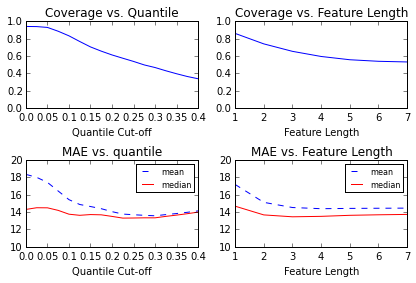

```python
resultsDFWDev["revQuants"] = resultsDFWDev.revQuants.apply(lambda x: str(x))

myfig, mygcf = getDevSetQntFtLnFig(resultsDFWDev, myYlim=(10,20))
restime=time.strftime("%Y%m%d-%H%M")
myfig.savefig("../timexNelleke/"+restime+"-DevSetQntFtLn-CovMae-WFeats.eps", format='eps')
restime
```

## Soccer - Dev. Set - MFeats(Manually selected Word Features)

```python
experimentMDev = experimentDev.copy()

print("Tweet set Length:",len(experimentMDev), "Manual words Length:", len(use_wlistM))
experimentMDev = extractFeats(experimentMDev, use_wlistM)
experimentMDev.head(1)
```

```python
resultsDFMDev = run_dev_set(experimentMDev, elimRulesFromTrain=False)
restime = time.strftime("%Y%m%d-%H%M")
resultsDFMDev.to_pickle(restime+"-DevSetQntFtLn-MFeats")#20140330-resultDFBackUP is the complete results file
restime
```

```
'20140707-1037'
```

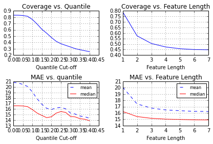

```python
myfig = getDevSetQntFtLnFig(resultsDFMDev)
restime=time.strftime("%Y%m%d-%H%M")
myfig.savefig("../timexNelleke/"+restime+"-DevSetQntFtLn-CovMae-MFeats")
restime
```

## Dev set for WFeats+TFeats (TFeats: temporal expressions)

```python
experimentWTDev = experimentDev.copy()

use_wlist = getOccWords(experimentWTDev, useWordSet, thres=1)

use_wlist = list(set(use_wlistW + use_wlistT))

experimentWTDev = extractFeats(experimentWTDev, use_wlist)
print("Tweet set Length:",len(experimentWTDev))
experimentWTDev.head(1)
```

```python
resultsDFWTDev = run_dev_set(experimentWTDev, elimRulesFromTrain=False)
restime = time.strftime("%Y%m%d-%H%M")
resultsDFWTDev.to_pickle(restime+"-DevSetQntFtLn-WTFeats")#20140330-resultDFBackUP is the complete results file
restime
```

```
'20140914-1153'
```

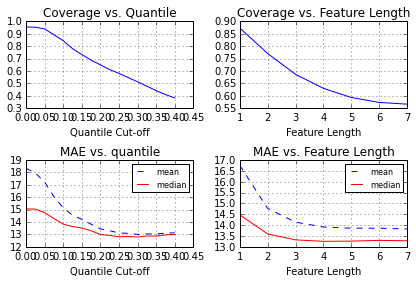

```python
myfig = getDevSetQntFtLnFig(resultsDFWTDev)
restime=time.strftime("%Y%m%d-%H%M")
myfig.savefig("../timexNelleke/"+restime+"-DevSetQntFtLn-CovMae-WTFeats")
restime
```

## Dev set for MFeats+TFeats

```python
experimentMTDev = experimentDev.copy()

use_wlist = list(set(use_wlistM + use_wlistT))

experimentMTDev = extractFeats(experimentMTDev, use_wlist)
print("Tweet set Length:",len(experimentMTDev))
experimentMTDev.head(1)
```

```python
resultsDFMTDev = run_dev_set(experimentMTDev, elimRulesFromTrain=False)
restime = time.strftime("%Y%m%d-%H%M")
resultsDFMTDev.to_pickle(restime+"-DevSetQntFtLn-MTFeats")#20140330-resultDFBackUP is the complete results file
restime
```

```
'20140716-1724'
```

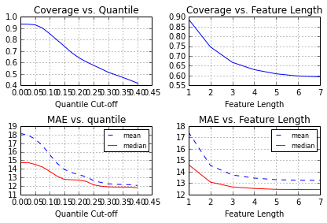

```python
myfig = getDevSetQntFtLnFig(resultsDFMTDev)
restime=time.strftime("%Y%m%d-%H%M")
myfig.savefig("../timexNelleke/"+restime+"-DevSetQntFtLn-CovMae-MTFeats")
restime
```

# Devset For TFeats only

```python
experimentTDev.to_csv("../timexNelleke/FootballMatchesDEV8DaysText", sep='\t', columns=['twID',"ttext"], index=False)
```

```python
experimentTDev = experimentDev.copy()

experimentTDev = extractFeats(experimentTDev, use_wlistT)
print("Tweet set Length:",len(experimentTDev))
experimentTDev.head(1)
```

```
Tweet set Length: 18607
```

|  | dt_etime | event | twID | user | ttext | time_to_event | time_to_eventhF | ttextlist | allFeats |
| --- | --- | --- | --- | --- | --- | --- | --- | --- | --- |
| 311 | 2012-03-17 21:52:23 | ajapsv_s12 | 181120819320209410 | centralpoint_nl | @jackvermonden morgen bij #adoaja wel borden van centralpoint.nl maar geen foto wedstrijd volgende week weer bij #ajapsv een fotowedstrijd | 7 days, 18:37:37 | -186.626944 | [@jackvermonden, morgen, bij, #adoaja, wel, borden, van, centralpoint.nl, maar, geen, foto, wedstrijd, volgende, week, weer, bij, #ajapsv, een, fotowedstrijd] | [morgen, volgende week, weer] |

```python
experimentTDev.to_pickle('experimentTDev_20141014')
```

```python
"Tweets which has a Temporal expression:", len(getTweetsWithTxFeats(experimentTDev))/len(experimentTDev)
```

```
('Tweets which has a Temporal expression:', 0.6840973827054334)
```

```python
resultsDFTDev = run_dev_set(experimentTDev, excambtmp=True,elimRulesFromTrain=True)
restime = time.strftime("%Y%m%d-%H%M")
resultsDFTDev.to_pickle(restime+"-DevSetQntFtLn-TFeats")#20140330-resultDFBackUP is the complete results file
restime
```

```
   0/17 tasks finished after   92 s
```

```python
resultsDFTDev = pd.read_pickle('20140915-0528-DevSetQntFtLn-TFeats')
```

```
'20141016-2237'
```

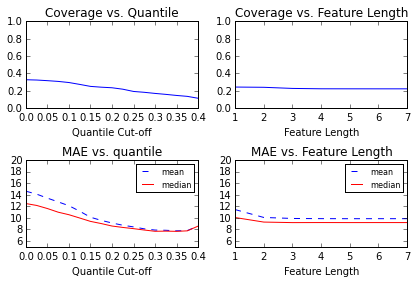

```python
resultsDFTDev['revQuants']=resultsDFTDev.revQuants.astype(str)

myfig, mygcf = getDevSetQntFtLnFig(resultsDFTDev, myYlim=(5,20))
restime=time.strftime("%Y%m%d-%H%M")
myfig.savefig("../timexNelleke/"+restime+"-DevSetQntFtLn-CovMae-TFeats.eps", format='eps')
restime
```

## Temporal Expressions List vs. Heideltime Tagger

in Dropbox/heideltime run: >> java -Dfile.encoding=UTF-8 -jar de.unihd.dbs.heideltime.standalone.jar ../timexNelleke/FootballMatchesDEV8DaysText -l DUTCH -t NEWS -dct 2014-10-10 -it > ../timexNelleke/FootballMatchesDEV8DaysText_TIMEX

- delete the warnings from the beginning of the file.
- delete last lines which contains and Nan
- tweet ID's should not be interpreted as temporal expression, check and clean such misinterpretations.

```python
heidelTimeDevDF = pd.read_table("../timexNelleke/FootballMatchesDEV8DaysText_TIMEX")
heidelTimeDevDF.dropna(inplace=True)

heidelTimeDevDF["twID"] = heidelTimeDevDF.twID.astype(str)
for tweetID in heidelTimeDevDF.twID:
    if len(tweetID)>20:
        print('Wrong tweet ID:',tweetID)
```

```python
heidelTimeDevDF.set_index("twID", inplace=True)
heidelTimeDevDF.tail()
```

| twID | ttext |
| --- | --- |
| 145857827565608960 | meestal noemen ze de half -1 wedstrijd de lunchwedstrijd <TIMEX3 tid="t15700" type="DATE" value="PRESENT_REF">nu</TIMEX3> lunch ik tijdens de half -3 wedstrijd #utrfey |
| 145857837988450304 | leuke actie bij f'n oord #vlaggen #utrfey |
| 145857844779036672 | daar gaan we #utrfey |
| 145857851204710400 | nou daar gaan we kijken of we de goede reeks kunnen voortzetten #utrfey |
| 145857861849845760 | daar gaan we #utrfey |

```python
def getTimexFromTimeML(tml):
    endTo = tml.find("</TIMEX3>")
    #startFrom = tml.f
    mytmxList = []
    while endTo != -1:
        startFrom = tml.find('>')
        mytmxList.append(tml[startFrom+1:endTo])

        tml = tml[endTo+9:]
        endTo = tml.find("</TIMEX3>")

    return mytmxList

heidelTimeDevDF["allFeats"] = heidelTimeDevDF.ttext.apply(getTimexFromTimeML) #x[x.find(">"):x.find("</TIMEX3>")]
heidelTimeDevDF["allFeats"].head()
```

```
twID
181120819320209410     [morgen, volgende week]
181340234422824960    [vrijdag, volgende week]
181344324057956354          [vandaag, vrijdag]
181364105922363392     [volgende week, zondag]
181366097499521024                          []
Name: allFeats, dtype: object
```

```python
experimentTDev = experimentDev.copy()

experimentTDev = extractFeats(experimentTDev, use_wlistT)
print("Tweet set Length:",len(experimentTDev))
```

```python
experimentTDevTempEx = experimentTDev[["twID","ttext","allFeats"]]
experimentTDevTempEx['twID'] = experimentTDevTempEx.twID.astype(str)
experimentTDevTempEx.set_index("twID", inplace=True)
experimentTDevTempEx.head()
```

| twID | ttext | allFeats |
| --- | --- | --- |
| 181120819320209410 | @jackvermonden morgen bij #adoaja wel borden van centralpoint.nl maar geen foto wedstrijd volgende week weer bij #ajapsv een fotowedstrijd | [morgen, volgende week, weer] |
| 181340234422824960 | @mootje115 nee wou vrijdag doen maar was niet aan toe gekomen volgende week zeker inzetten #ajapsv | [vrijdag, volgende week] |
| 181344324057956354 | vandaag voor t laatst voetbal kijken via stream vanaf vrijdag weer eredivisie live :d komt meteen goed uit #ajapsv | [vandaag, laatst, vrijdag, weer, meteen] |
| 181364105922363392 | @ frankie_eillyas ik maak volgende week zondag je leven nog zwaarder ;) #ajapsv | [volgende week zondag, nog] |
| 181366097499521024 | janssen geschorst voor #ajapsv tegenslag | [] |

```python
# eliminate words that are not taken into account on themselves
# be careful! These items can enter the skip-gram generation process and provide useful features.
excludeTmx = getlinelist("../timexNelleke/20140601-excludeTmx.txt")
experimentTDevTempEx['allFeats'] = experimentTDevTempEx.allFeats.apply(lambda feats: [tx for tx in feats if tx not in excludeTmx])
```

```python
experimentTDevTempEx["allFeats_str"] = experimentTDevTempEx.allFeats.apply(lambda strList: '_'.join(strList))
heidelTimeDevDF["allFeats_str"] = heidelTimeDevDF.allFeats.apply(lambda strList: '_'.join(strList))
```

```python
len(heidelTimeDevDF), len(experimentTDevTempEx)
```

```
(18607, 18607)
```

```python
tempExCompare = heidelTimeDevDF.join(experimentTDevTempEx, lsuffix='_heidel', rsuffix='_hurr')
```

```python
tempExCompare.head()
```

| twID | ttext_heidel | allFeats_heidel | allFeats_str_heidel | ttext_hurr | allFeats_hurr | allFeats_str_hurr |
| --- | --- | --- | --- | --- | --- | --- |
| 142963071923666946 | kaartje utrecht uit is binnen voor <TIMEX3 tid="t14947" type="DATE" value="2014-W42">volgende week</TIMEX3> #utrfey | [volgende week] | volgende week | kaartje utrecht uit is binnen voor volgende week #utrfey | [volgende week] | volgende week |
| 143043211458392064 | ga naar fc utrecht feyenoord #utrfey | [] |  | ga naar fc utrecht feyenoord #utrfey | [] |  |
| 143310712880631808 | <TIMEX3 tid="t14948" type="DATE" value="2014-W42">volgende week</TIMEX3> gaat feyenoord bij utrecht op bezoek #utrfey | [volgende week] | volgende week | volgende week gaat feyenoord bij utrecht op bezoek #utrfey | [volgende week] | volgende week |
| 143321070328492032 | #utrfey kijken | [] |  | #utrfey kijken | [] |  |
| 143325170201923584 | en dan staat het alweer 0 -2 #utrfey | [] |  | en dan staat het alweer 0 -2 #utrfey | [] |  |

```python
# tweets that are contain at least one temp. ex. at least from one tagger
len(tempExCompare[(tempExCompare.allFeats_str_heidel != '') | (tempExCompare.allFeats_str_hurr != '')])
```

```
10183
```

```python
len(tempExCompare[tempExCompare.allFeats_str_heidel != ''])
```

```
8049
```

```python
len(tempExCompare[tempExCompare.allFeats_str_hurr != ''])
```

```
9754
```

```python
heidYesHurrListNo = tempExCompare[(tempExCompare.allFeats_str_heidel != '') & (tempExCompare.allFeats_str_hurr == '')][["ttext_hurr","allFeats_heidel","allFeats_hurr"]]
hurrListYesHeidNo = tempExCompare[(tempExCompare.allFeats_str_heidel == '') & (tempExCompare.allFeats_str_hurr != '')][["ttext_hurr","allFeats_heidel","allFeats_hurr"]]
print('Number for Hurr_list finds, but not the heideltime:',len(hurrListYesHeidNo))
print('Number for Heideltime finds, but not the HurrList:',len(heidYesHurrListNo))
```

[output not shown]

```python
hurrListYesHeidNo.to_csv('../timexNelleke/FootballMatchesDEV8DaysText_justHurrListMatch', encoding='utf-8', sep='\t')
heidYesHurrListNo.to_csv('../timexNelleke/FootballMatchesDEV8DaysText_justHeidMatch', encoding='utf-8', sep='\t')
```

```python
notEqualTxMatches = tempExCompare[tempExCompare.allFeats_str_heidel != tempExCompare.allFeats_str_hurr][["ttext_hurr","allFeats_heidel","allFeats_hurr"]] #[120:150] #[tempExCompare.allFeats_heidel
notEqualTxMatches.to_csv('../timexNelleke/FootballMatchesDEV8DaysText_Comparison', encoding='utf-8', sep='\t')
len(notEqualTxMatches)
```

```
5008
```

```python
# tempExSet
tempExCntr= Counter()
heidYesHurrListNo.allFeats_heidel.apply(lambda txList: tempExCntr.update(txList))
tempExCntr.most_common()
```

```python
# tempExSet
tempExCntr= Counter()
hurrListYesHeidNo.allFeats_hurr.apply(lambda txList: tempExCntr.update(txList))
tempExCntr.most_common()
```

## Dev set Improve TFeats with Rules - same experiment data with Devset TFeats phase

```python
resultsDFTRDev = run_loo_experimentP(experimentTDev, lComb=2, stdThresh=0.75,throcc=1, excambtmp=True, elimRulesFromTrain=True)

#restime=time.strftime("%Y%m%d-%H%M")
resultsDFTRDev.to_pickle(restime+"-DevSetRules-NoRuleElim2")#20140330-resultDFBackUP is the complete results file
#restime
```

```
   9/9 tasks finished after  180 s
done
```

```python
tempExSetDEV = set()
for tfCnt in resultsDFTRDev.allFeats:
    tempExSetDEV.update(tfCnt)

print('number of identified temporal expressions is:',len(tempExSetDEV))
```

```
number of identified temporal expressions is: 945
```

```python
len([tw for tw in experimentTDev.allFeats if len(tw)!= 0])/len(experimentTDev)
```

```
0.6531950341269415
```

```python
lenres = len(resultsDFTRDev)
lenres, resultsDFTRDev.dynDaysTTEmea.count()
```

```
(18607, 1204)
```

```python
print("Exact rule MAE:", getMAE(resultsDFTRDev.time_to_eventhF, resultsDFTRDev.exactTTEmea), resultsDFTRDev.exactTTEmea.count()/lenres)
print("Dynamic Hours MAE:", getMAE(resultsDFTRDev.time_to_eventhF, resultsDFTRDev.dynHoursTTEmea), resultsDFTRDev.dynHoursTTEmea.count()/lenres)
print("Dynamic Days MAE:", getMAE(resultsDFTRDev.time_to_eventhF, resultsDFTRDev.dynDaysTTEmea), resultsDFTRDev.dynDaysTTEmea.count()/lenres)
print("Dynamic Months MAE",getMAE(resultsDFTRDev.time_to_eventhF, resultsDFTRDev.dynMonthsTTEmea), resultsDFTRDev.dynMonthsTTEmea.count()/lenres)
print("Median Training Mean Estimation MAE:", getMAE(resultsDFTRDev.time_to_eventhF, resultsDFTRDev.medMeaEstim), resultsDFTRDev.medMeaEstim.count()/lenres)

resultsDFTRDev["rulesMeaSerie"] = resultsDFTRDev[["dynDaysTTEmea","dynHoursTTEmea","dynMonthsTTEmea","exactTTEmea"]].apply(np.mean,1)
print("Mean of Rules combination MAE:",getMAE(resultsDFTRDev.time_to_eventhF, resultsDFTRDev.rulesMeaSerie), resultsDFTRDev.rulesMeaSerie.count()/lenres)

resultsDFTRDev["rulesAndTrain"] = np.where(resultsDFTRDev.rulesMeaSerie.notnull(),resultsDFTRDev.rulesMeaSerie,resultsDFTRDev.medMeaEstim)
print("Mean rule and Temporal exp. train combination MAE:",getMAE(resultsDFTRDev.time_to_eventhF, resultsDFTRDev.rulesAndTrain), resultsDFTRDev.rulesAndTrain.count()/lenres)
```

```
Exact rule MAE: 7.58056090429 0.041865964422
Dynamic Hours MAE: 6.85369094031 0.192991884775
Dynamic Days MAE: 9.15894933555 0.0647068307626
Dynamic Months MAE 17.1734693878 0.00263341753104
Median Training Mean Estimation MAE: 8.59106195877 0.197076369108
Mean of Rules combination MAE: 6.58802941257 0.291610684151
Mean rule and Temporal exp. train combination MAE: 6.624119493 0.417154834202
```

```python
resultsDFTRDev[resultsDFTRDev.dynMonthsTTEmea.notnull()][["dt_etime","ttext","allFeats", "dynMonthsTTEmea","time_to_eventhF","dynDaysTTEmea","dynHoursTTEmea","exactTTEmea"]]
```

|  | dt_etime | ttext | allFeats | dynMonthsTTEmea | time_to_eventhF | dynDaysTTEmea | dynHoursTTEmea | exactTTEmea |
| --- | --- | --- | --- | --- | --- | --- | --- | --- |
| 59 | 2012-03-18 16:08:05 | @onlinemarketeer die duurt maar een week ;) 25 maart #ajapsv | [een week, 25 maart] | -166.865278 | -168.365278 | NaN | NaN | NaN |
| 146 | 2012-03-18 23:25:48 | bij welke ajacied uit zandvoort kan ik 25 maart douchen zodat ik na circuitrun zo naar de arena kan reizen #ajapsv #dtv #ajax rt dm | [25 maart, zo] | -159.570000 | -161.070000 | NaN | NaN | NaN |
| 230 | 2012-03-20 11:15:35 | heeee maar op 25 maart 2005 won psv met 4 -0 bij ajax dat doen we dus zondag gewoon weer 7 jaar later #ajapsv | [25 maart, zondag, weer, jaar, later] | -123.740278 | -125.240278 | -123.740278 | NaN | NaN |
| 231 | 2012-03-20 11:18:23 | @itsmichellexx heeee maar op 25 maart 2005 won psv met 4 -0 bij ajax dat doen we dus zondag gewoon weer 7 jaar later #ajapsv hahahahahah | [25 maart, zondag, weer, jaar, later] | -123.693611 | -125.193611 | -123.693611 | NaN | NaN |
| 282 | 2012-03-20 14:26:39 | vandaag 20 maart 7 jaar geleden voorbereiding voor zondag aanstaande #ajapsv #psv http://t.co/uuxni4j9 | [vandaag, 20 maart, jaar, zondag, aanstaande] | -0.555833 | -122.055833 | -120.555833 | -0.555833 | NaN |
| 652 | 2012-03-23 09:28:54 | gm followers gisteren genoten van een vrije dag en nu 100 % focus op zondag #ajapsv & amp 8 apr de beker finale #psvher in de kuip | [gisteren, dag, nu, zondag, 8 apr] | -389.518333 | -55.018333 | -53.518333 | NaN | NaN |
| 1329 | 2012-03-25 08:23:12 | wil je naast het bekijken van #ajapsv ook gezellig tennissen in eindhoven kom dan naar de open tennis dagen bij etv-volley op 1 april | [dan, dagen, 1 april] | -174.613333 | -8.113333 | NaN | NaN | NaN |
| 2180 | 2012-03-25 11:54:14 | vak 410 26 maart 2012 ajax kan nog geen kampioen worden maar wel een voorschot nemen op de 31e titel #ajax #ajapsv 5 9 | [26 maart, nog] | -27.096111 | -4.596111 | NaN | NaN | NaN |
| 2183 | 2012-03-25 11:54:19 | vak 410 26 maart 2012 kom in je ajax-shirt schreeuw je keel schor #ajax #ajapsv 6 9 | [26 maart] | -27.094722 | -4.594722 | NaN | NaN | NaN |
| 2184 | 2012-03-25 11:54:25 | vak 410 26 maart 2012 ga als één man 90 minuten lang achter ajax staan #ajax #ajapsv 7 9 | [26 maart, minuten] | -27.093056 | -4.593056 | NaN | NaN | NaN |
| 3500 | 2012-03-25 15:46:18 | wil je naast het bekijken van #ajapsv ook gezellig tennissen in eindhoven kom dan naar de open tennis dagen bij etv-volley op 1 april | [dan, dagen, 1 april] | -167.228333 | -0.728333 | NaN | NaN | NaN |
| 4614 | 2012-02-26 20:19:41 | @robsimonsx haha mooi toch 4 maart is #psvtwe ook kijke | [4 maart] | -162.671944 | -164.171944 | NaN | NaN | NaN |
| 6313 | 2012-08-05 13:22:30 | 12 augustus naar ajax az zin in #ajaaz | [12 augustus] | -169.625000 | -171.125000 | NaN | NaN | NaN |
| 7051 | 2012-08-12 10:12:18 | matchday kraker nh ajax-az 12 augustus 16:30 wie krijgt er 3 punten of wordt t gelijk spel #ajaaz | [matchday, 12 augustus 16:30] | -6.295000 | -6.295000 | NaN | NaN | NaN |
| 8486 | 2012-11-25 13:47:36 | misschien wordt alderweireld gewisseld met het oog op de topper van 1 december ajax psv #rodaja #ajapsv | [1 december] | -145.206667 | -150.956667 | NaN | NaN | NaN |
| 8494 | 2012-11-25 14:24:37 | “ @ajax1nl volgende week wacht #ajax psv zaterdag 1 december om 20.45 wordt deze wedstrijd gespeeld #rodaja #ajapsv ” | [volgende week, zaterdag 1 december, om 20.45] | -144.589722 | -150.339722 | NaN | NaN | -168 |
| 8495 | 2012-11-25 14:24:47 | “ @ajax1nl volgende week wacht #ajax psv zaterdag 1 december om 20.45 wordt deze wedstrijd gespeeld #rodaja #ajapsv ” maak ze kapot | [volgende week, zaterdag 1 december, om 20.45] | -144.586944 | -150.336944 | NaN | NaN | -168 |
| 8496 | 2012-11-25 14:24:58 | @ajax1nl volgende week wacht #ajax psv zaterdag 1 december om 20.45 wordt deze wedstrijd gespeeld #rodaja #ajapsv | [volgende week, zaterdag 1 december, om 20.45] | -144.583889 | -150.333889 | NaN | NaN | -168 |
| 8498 | 2012-11-25 14:25:55 | volgende week wacht #ajax psv zaterdag 1 december om 20.45 wordt deze wedstrijd gespeeld #rodaja #ajapsv | [volgende week, zaterdag 1 december, om 20.45] | -144.568056 | -150.318056 | NaN | NaN | -168 |
| 8505 | 2012-11-25 14:36:50 | @ajax1nl volgende week wacht #ajax psv zaterdag 1 december om 20.45 wordt deze wedstrijd gespeeld #rodaja #ajapsv | [volgende week, zaterdag 1 december, om 20.45] | -144.386111 | -150.136111 | NaN | NaN | -168 |
| 8517 | 2012-11-25 15:41:51 | 1 december zitten wij in de arena #ajapsv #kannietwachten | [1 december] | -143.302500 | -149.052500 | NaN | NaN | NaN |
| 8566 | 2012-11-25 20:31:26 | zaterdag 1 december de voetbaltrolls supertopper #ajapsv http://t.co/axhsgjnv | [zaterdag 1 december] | -138.476111 | -144.226111 | NaN | NaN | NaN |
| 8567 | 2012-11-25 20:35:57 | zaterdag 1 december ajax psv #arena #20 .45 #amsterdamarena #ajapsv http://t.co/0zektxse | [zaterdag 1 december] | -138.400833 | -144.150833 | NaN | NaN | NaN |
| 8593 | 2012-11-26 13:51:57 | @ r_rink ik heb en aantal berichjes gestuud via whatsup reageer even @afcafanatcs #wij zijn ajax wij zijn de beste #ajapsv 1 dec | [1 dec] | -121.134167 | -126.884167 | NaN | NaN | NaN |
| 8598 | 2012-11-26 14:45:43 | https://t.co/l6y0frhr samenvatting roda-ajax 1 -2 24 11 2012 @afcafanatics #wij zijn ajax wij zijn de beste #ajapsv 1 december 20:45 uur | [1 december 20:45, uur] | -125.988056 | -125.988056 | NaN | NaN | NaN |
| 8599 | 2012-11-26 14:58:26 | ik ga as zaterdag een liveverslag doen van #ajapsv live vanuit de arena @afcafanatics #wij zijn ajax wij zijn de beste #ajapsv 1 dec | [zaterdag, 1 dec] | -120.026111 | -125.776111 | -120.026111 | NaN | NaN |
| 8601 | 2012-11-26 15:12:53 | ajax joden super joden en waar komen joden toch vandaan israel hier ver vandaan @afcafanatics #ajapsv 1 december 20:45 uur 3 punten | [1 december 20:45, uur] | -125.535278 | -125.535278 | NaN | NaN | NaN |
| 8611 | 2012-11-26 18:58:24 | @dwmmartin30 lees je prive berichten ik heb je en berichtje gestuurd @afcafanatics #wij zin ajax wijzijn de beste #ajapsv 1 december | [1 december] | -116.026667 | -121.776667 | NaN | NaN | NaN |
| 8619 | 2012-11-26 22:54:51 | zaterdag 1 december 20:45 #afca #psv #ajapsv | [zaterdag 1 december, 20:45] | -112.085833 | -117.835833 | NaN | -21.835833 | NaN |
| 8803 | 2012-11-27 22:26:55 | ze maar voor ajax zijn @afcafanatics #staoptegenkanker #wij zijn ajax wij zijn de beste #ajapsv 1 december neem je ajaxsjaal mee | [1 december] | -88.551389 | -94.301389 | NaN | NaN | NaN |
| 8877 | 2012-11-28 19:54:17 | fack kom er net achter dat mn #eredivisielive maar tot 30 nov duurt en 1dec is #ajapsv | [net, 30 nov] | -43.095278 | -72.845278 | NaN | NaN | NaN |
| 9091 | 2012-11-30 09:37:49 | 1 december is een dag die je niet weer vergeet pisvee gaat eraan dat iedereen het maar weet de sint #ajapsv #3punten | [1 december, een dag, weer] | -29.369722 | -35.119722 | NaN | NaN | NaN |
| 9624 | 2012-12-01 00:04:05 | 00:00 uur 1 december #matchday #ajapsv we gaan ze pakken kick-off in 20 hours and 45 minutes | [00:00 uur, 1 december, matchday] | -14.931944 | -20.681944 | NaN | NaN | NaN |
| 9738 | 2012-12-01 08:03:36 | goedemorgen het is 1 december #matchday #ajapsv vanavond proberen 15 min eerder op werk te vertrekken om heel de wedstrijd te zien #ajax | [1 december, matchday, vanavond, eerder] | -6.940000 | -12.690000 | NaN | -11.940000 | NaN |
| 12663 | 2012-10-01 00:52:14 | op zondag 7 oktober 2012 word er om half 12:30 in amsterdam gespeeld tegen utrecht #ajautr | [zondag 7 oktober, om half 12] | -158.129444 | -155.629444 | NaN | -22.629444 | NaN |
| 13867 | 2011-02-26 09:48:45 | morgen az-fct #aztwe 10 maart weer tegen russen zenit st. petersburg dit word moeilijker ;o #twezen | [morgen, 10 maart, weer] | -293.187500 | -28.687500 | NaN | -5.187500 | NaN |
| 14382 | 2011-03-26 08:43:06 | 2 april waarschijnlijk naar feyenoord-az met @stephenvanstek #feyaz | [2 april] | -174.281667 | -180.031667 | NaN | NaN | NaN |
| 14436 | 2011-03-31 16:51:29 | 2 april komt steeds dichterbij #feyaz | [2 april, steeds] | -46.141944 | -51.891944 | NaN | NaN | NaN |
| 14437 | 2011-03-31 17:06:27 | @rickkk0180 2 april komt steeds dichterbij #feyaz | [2 april, steeds] | -45.892500 | -51.642500 | NaN | NaN | NaN |
| 14626 | 2011-04-02 15:50:20 | op 2 april 1956 won feyenoord toen nog feijenoord met 11 -4 van de volenwijckers las ik net beloofd dat iets goeds voor vanavond #feyaz | [2 april, toen nog, net, vanavond] | 0.838889 | -4.911111 | NaN | -4.161111 | NaN |
| 15063 | 2011-03-25 23:54:51 | was het maar 2 april #twepsv | [2 april] | -183.085833 | -186.835833 | NaN | NaN | NaN |
| 15075 | 2011-03-27 14:22:33 | helaas dit weekend geen eredivisie voetbal 2 april starten we met de topper fc twente psv #twepsv | [dit weekend, 2 april] | -144.624167 | -148.374167 | NaN | NaN | NaN |
| 15122 | 2011-03-29 13:04:51 | hulde kaarten voor fc twente villarreal donderdag 14 april eerst a.s. zaterdag de kampioen aanschouwen fc twente-psv #twepsv #fctwente | [donderdag 14 april, eerst, zaterdag] | -385.919167 | -101.669167 | -97.919167 | NaN | NaN |
| 15139 | 2011-03-29 16:08:25 | #blom die #twepsv fluit ik hoop dat dit een 1 april-grap van de #knvb is | [1 april] | -70.859722 | -98.609722 | NaN | NaN | NaN |
| 15179 | 2011-03-30 01:07:39 | en dan heb je nog altijd een kaartje over voor de match van het seizoen #twepsv zaterdag 2 april #grolschveste | [dan, nog, altijd, voor de match, van het seizoen, zaterdag 2 april] | -85.872500 | -89.622500 | NaN | NaN | NaN |
| 15369 | 2011-04-01 07:24:33 | @jeroennotenboom mijn blik is geheel gericht op 2 april dag van de waarheid #twepsv | [2 april, dag van de waarheid] | -31.590833 | -35.340833 | NaN | NaN | NaN |
| 15374 | 2011-04-01 08:23:08 | over goeie 1 april grappen gesproken twente gaat morge winnen #twepsv | [1 april] | -6.614444 | -34.364444 | NaN | NaN | NaN |
| 15380 | 2011-04-01 08:58:05 | wakker straks ff naar school vanmiddag arbeiten @ timmerhuis daarna weekend en dat weekend draait maar om 1 ding 2 april 18:45 #twepsv | [straks, vanmiddag, daarna, weekend, dat weekend, 2 april 18:45] | -33.781944 | -33.781944 | NaN | -6.031944 | NaN |
| 15388 | 2011-04-01 09:45:42 | de beste 1 april grap psv gaat morgen winnen #twepsv | [1 april, morgen] | -5.238333 | -32.988333 | NaN | NaN | NaN |
| 15403 | 2011-04-01 11:09:44 | zin in morgen was het maar vast matchday ipv 1 april #twepsv | [morgen, matchday, 1 april] | -3.837778 | -31.587778 | NaN | NaN | NaN |
| 15528 | 2011-04-01 18:44:19 | beste 1 april-grap van dit jaar hier op twitter gezien psv wint morge van twente whahahaha no way guys #twepsv | [1 april, van dit jaar] | 3.738611 | -24.011389 | NaN | NaN | NaN |
| 15590 | 2011-04-01 22:25:12 | 2 april d-day #twepsv op naar de 1e ster nog 8 seizoenen | [2 april, d-day, nog, seizoenen] | -16.580000 | -20.330000 | NaN | NaN | NaN |
| 16101 | 2011-04-02 14:00:06 | psv is in de eredivisie al 7 duels op rij zonder zege tegen fc twente thuis en uit ): g 6 v 1 laatste zege 14 apr 2007 2 -0 #twepsv | [al, 14 apr] | -288.998333 | -4.748333 | NaN | NaN | NaN |

## Devset WFeats with Optimized Params for the Combination

Use all tweets to train WFeats, but do not use the estimation on test if a Temp. estimation available for a tweet

```python
resultsDFWDev2 = run_loo_experimentP(experimentWDev, lComb=2, stdThresh=0.80,throcc=1,excambtmp=False,elimRulesFromTrain=False) #last False means do not eliminate features which has a rule associated with it
restime = time.strftime("%Y%m%d-%H%M")
resultsDFWDev2.to_pickle(restime+"-DevSetWFeats-Optimized")#20140330-resultDFBackUP is the complete results file
restime
```

```
   9/9 tasks finished after  142 s
done
```

```
'20141015-1100'
```

```python
getMAE(resultsDFWDev2.time_to_eventhF,resultsDFWDev2.medMedEstim), getRMSE(resultsDFWDev2.time_to_eventhF,resultsDFWDev2.medMedEstim)
```

```
(13.128463683134768, 30.992971671740037)
```

```python
resultsDFWDev2.medMedEstim.count()/len(resultsDFWDev2)
```

```
0.76836674369860802
```

```python
resultsDFTRDev["rulesTFeatsWFeats"] = np.where(resultsDFTRDev.rulesAndTrain.notnull(),resultsDFTRDev.rulesAndTrain,resultsDFWDev2.medMedEstim)
print("priority:mean Rule, TFeats, WFeats -> MAE:", getMAE(resultsDFTRDev.time_to_eventhF, resultsDFTRDev.rulesTFeatsWFeats))
```

```
priority:mean Rule, TFeats, WFeats -> MAE: 9.54343087253
```

```python
resultsDFTRDev["rulesTFeatsWFeats"].count()/len(resultsDFTRDev)
```

```
0.80851292524318807
```

```python
# # run it just after creating it, not after modifying it!
# resultsDFTRDev_BackUP = resultsDFTRDev.copy()
# resultsDFTRDev_BackUP.to_pickle('resultsDFTRDev_BackUP')
```

```python
# Get the fresh copy back!
# resultsDFTRDev = resultsDFTRDev_BackUP.copy()
```

## Mean training-estimation vs. Median Training-Estimation (MAE, RMSE)

```python
medTmedE = getMAE(resultsDFTRDev.time_to_eventhF, resultsDFTRDev.medMedEstim)
medTmeaE = getMAE(resultsDFTRDev.time_to_eventhF, resultsDFTRDev.medMeaEstim)
meaTmedE = getMAE(resultsDFTRDev.time_to_eventhF, resultsDFTRDev.meaMedEstim)
meaTmeaE = getMAE(resultsDFTRDev.time_to_eventhF, resultsDFTRDev.meaMeaEstim)

trainEstFuncResDF = pd.DataFrame({'Median Estimation':{'Median Training':medTmedE,'Mean Training':meaTmedE}, \
              'Mean Estimation':{'Median Training':medTmeaE,'Mean Training':meaTmeaE}})#.to_latex()
trainEstFuncResDF = trainEstFuncResDF.apply(lambda x: np.round(x,2))
print(trainEstFuncResDF.to_latex())
```

[output not shown]

```python
medTmedE = getMAE(resultsDFWDev2.time_to_eventhF, resultsDFWDev2.medMedEstim)
medTmeaE = getMAE(resultsDFWDev2.time_to_eventhF, resultsDFWDev2.medMeaEstim)
meaTmedE = getMAE(resultsDFWDev2.time_to_eventhF, resultsDFWDev2.meaMedEstim)
meaTmeaE = getMAE(resultsDFWDev2.time_to_eventhF, resultsDFWDev2.meaMeaEstim)

trainEstFuncResDF = pd.DataFrame({'Median Estimation':{'Median Training':medTmedE,'Mean Training':meaTmedE}, \
              'Mean Estimation':{'Median Training':medTmeaE,'Mean Training':meaTmeaE}})#.to_latex()
trainEstFuncResDF = trainEstFuncResDF.apply(lambda x: np.round(x,2))
print(trainEstFuncResDF.to_latex())
```

```
\begin{tabular}{lrr}
\toprule
{} &  Mean Estimation &  Median Estimation \\
\midrule
Mean Training   &            14.11 &              14.04 \\
Median Training &            13.15 &              13.13 \\
\bottomrule
\end{tabular}
```

```python
medTmedE = getRMSE(resultsDFTRDev.time_to_eventhF, resultsDFTRDev.medMedEstim)
medTmeaE = getRMSE(resultsDFTRDev.time_to_eventhF, resultsDFTRDev.medMeaEstim)
meaTmedE = getRMSE(resultsDFTRDev.time_to_eventhF, resultsDFTRDev.meaMedEstim)
meaTmeaE = getRMSE(resultsDFTRDev.time_to_eventhF, resultsDFTRDev.meaMeaEstim)

trainEstFuncResDF2=pd.DataFrame({'Median Estimation':{'Median Training':medTmedE,'Mean Training':meaTmedE}, \
              'Mean Estimation':{'Median Training':medTmeaE,'Mean Training':meaTmeaE}})
trainEstFuncResDF2 = trainEstFuncResDF2.apply(lambda x: np.round(x,2))
#trainEstFuncResDF2=trainEstFuncResDF2.set_index(["Error Measure"])
#print(trainEstFuncResDF2.set_index(["Error Measure"]).to_latex())
print(trainEstFuncResDF2.to_latex())
```

```
\begin{tabular}{lrr}
\toprule
{} &  Mean Estimation &  Median Estimation \\
\midrule
Mean Training   &            20.79 &              20.79 \\
Median Training &            21.16 &              21.16 \\
\bottomrule
\end{tabular}
```

## Window Length Optimization

```python
def getHyperHist(orgDF, estCol, uptoWLen=51, step=3):
    resultsDFTRDevHist = orgDF[orgDF[estCol].notnull()]
    #print(len(resultsDFTRDevHist))
    hstWlnErrDF = pd.DataFrame({"medMAE":getMAE(resultsDFTRDevHist.time_to_eventhF, resultsDFTRDevHist[estCol]),
                                                       "medRMSE":getRMSE(resultsDFTRDevHist.time_to_eventhF, resultsDFTRDevHist[estCol]),
                                                       "meaMAE":getMAE(resultsDFTRDevHist.time_to_eventhF, resultsDFTRDevHist[estCol]),
                                                       "meaRMSE":getRMSE(resultsDFTRDevHist.time_to_eventhF, resultsDFTRDevHist[estCol])}, index=[1])
    #print(resultsDFTRDevHist.event.value_counts())
    print('wlen', end=':')
    for wlen in range(2,uptoWLen,step):
        # groupby("event",group_keys=False)
        resultsDFTRDevHist = resultsDFTRDevHist.groupby("event",group_keys=False).apply(calcExpandHistNorm, estCol, wlen)
        hstWlnErrDF = hstWlnErrDF.append(pd.DataFrame({"medMAE":getMAE(resultsDFTRDevHist.time_to_eventhF, resultsDFTRDevHist["histMed_"+estCol]),
                                                       "medRMSE":getRMSE(resultsDFTRDevHist.time_to_eventhF, resultsDFTRDevHist["histMed_"+estCol]),
                                                       "meaMAE":getMAE(resultsDFTRDevHist.time_to_eventhF, resultsDFTRDevHist["histMea_"+estCol]),
                                                       "meaRMSE":getRMSE(resultsDFTRDevHist.time_to_eventhF, resultsDFTRDevHist["histMea_"+estCol])}, index=[wlen]))
        print(wlen, end=',')
    print()
    return hstWlnErrDF
```

```python
resHistW = getHyperHist(resultsDFWDev2,"medMedEstim", uptoWLen=54, step=3)
resHistT = getHyperHist(resultsDFTRDev,"medMedEstim", uptoWLen=54, step=3)
resHistR = getHyperHist(resultsDFTRDev,"rulesMeaSerie", uptoWLen=54, step=3)
resHistRTW = getHyperHist(resultsDFTRDev,"rulesTFeatsWFeats", uptoWLen=54, step=3)
```

```
wlen:2,5,8,11,14,17,20,23,26,29,32,35,38,41,44,47,50,53,
wlen:2,5,8,11,14,17,20,23,26,29,32,35,38,41,44,47,50,53,
wlen:2,5,8,11,14,17,20,23,26,29,32,35,38,41,44,47,50,53,
```

```python
myLineStyles = ['g-','b--','k:', 'r-.']
```

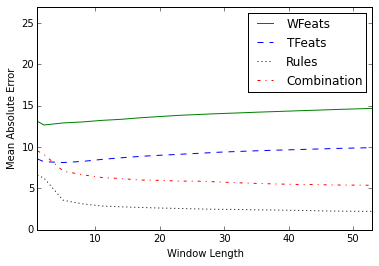

```python
medWTRdf = pd.DataFrame(resHistW.medMAE)
medWTRdf.columns = ['WFeats']
medWTRdf['TFeats'] = resHistT.medMAE
medWTRdf['Rules'] = resHistR.medMAE
medWTRdf['Combination'] = resHistRTW.medMAE

fig, ax = plt.subplots()
medWTRdf.plot(grid=False, ax=ax, ylim=(0,27), style=myLineStyles)
plt.xlabel('Window Length') ,plt.ylabel("Mean Absolute Error")
fig.savefig('histFuncWinSizeOptimPerModule.eps', format='eps')
```

```python
resHistIncR = resHistR.copy() # it uses just its own history.
resHistIncTR = getHyperHist(resultsDFTRDev, "rulesAndTrain", uptoWLen=54, step=3)
resHistIncTRW = getHyperHist(resultsDFTRDev, "rulesTFeatsWFeats", uptoWLen=54, step=3)
```

```
wlen:2,5,8,11,14,17,20,23,26,29,32,35,38,41,44,47,50,53,
wlen:2,5,8,11,14,17,20,23,26,29,32,35,38,41,44,47,50,53,
```

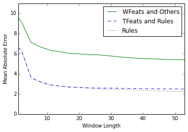

```python
medIncWTRdf = pd.DataFrame(resHistIncTRW.medMAE)
medIncWTRdf.columns = ['WFeats and Others']
medIncWTRdf['TFeats and Rules'] = resHistIncTR.medMAE
medIncWTRdf['Rules'] = resHistIncR.medMAE

fig, ax = plt.subplots()
medIncWTRdf.plot(grid=False, ax=ax, ylim=(0,11), style=myLineStyles)
plt.xlabel('Window Length') ,plt.ylabel("Mean Absolute Error")
fig.savefig('InchistFuncWinSizeOptimPerModule.eps', format='eps')
```

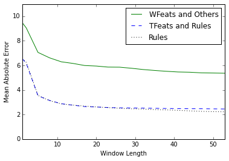

```python
medIncWTRdf = pd.DataFrame(resHistIncTRW.medMAE)
medIncWTRdf.columns = ['WFeats and Others']
medIncWTRdf['TFeats and Rules'] = resHistIncTR.medMAE
medIncWTRdf['Rules'] = resHistIncR.medMAE

fig, ax = plt.subplots()
medIncWTRdf.plot(grid=False, ax=ax, ylim=(0,11), style=myLineStyles)
plt.xlabel('Window Length') ,plt.ylabel("Mean Absolute Error")
fig.savefig('InchistFuncWinSizeOptimPerModule.eps', format='eps')
```

```python
resultsDFTRDev.columns
```

```
Index(['dt_etime', 'event', 'twID', 'user', 'ttext', 'time_to_event', 'time_to_eventhF', 'ttextlist', 'allFeats', 'featComb', 'medMedEstim', 'medMeaEstim', 'meaMedEstim', 'meaMeaEstim', 'exactTTEmea', 'dynHoursTTEmea', 'dynDaysTTEmea', 'dynMonthsTTEmea', 'rulesMeaEstim', 'medmedOutEstim', 'meameaOut…
```

```python
# optimized winLen=20
winLen=20
rulesHistDevDF = resultsDFTRDev.groupby("event").apply(calcExpandHistNorm, "rulesMeaSerie", winLen)
rulesTmxHistDevDF = resultsDFTRDev.groupby("event").apply(calcExpandHistNorm, "rulesAndTrain", winLen)
rulesTmxLexHistDevDF = resultsDFTRDev.groupby("event").apply(calcExpandHistNorm, "rulesTFeatsWFeats", winLen)

rulesHistDevDF.reset_index(drop=True, level=0, inplace=True)
rulesTmxHistDevDF.reset_index(drop=True, level=0, inplace=True)
rulesTmxLexHistDevDF.reset_index(drop=True, level=0, inplace=True)

try:
    resultsDFTRDev=resultsDFTRDev.join(rulesHistDevDF.histMed_rulesMeaSerie,how='left')
    resultsDFTRDev=resultsDFTRDev.join(rulesTmxHistDevDF.histMed_rulesAndTrain,how='left')
    resultsDFTRDev=resultsDFTRDev.join(rulesTmxLexHistDevDF.histMed_rulesTFeatsWFeats,how='left')
except:
    resultsDFTRDev.update(resultsDFTRDev.histMed_rulesMeaSerie,join='left')
    resultsDFTRDev.update(rulesTmxHistDevDF.histMed_rulesAndTrain,join='left')
    resultsDFTRDev.update(rulesTmxLexHistDevDF.histMed_rulesTFeatsWFeats,join='left')


resultsDFTRDev["priorityALLEst"] = np.where(resultsDFTRDev.histMed_rulesMeaSerie.notnull(), resultsDFTRDev.histMed_rulesMeaSerie, \
             np.where(resultsDFTRDev.medMedEstim.notnull(), resultsDFTRDev.histMed_rulesAndTrain,resultsDFTRDev.histMed_rulesTFeatsWFeats))

print('winLen:', winLen,'MAE:',getMAE(resultsDFTRDev.time_to_eventhF,resultsDFTRDev.priorityALLEst), 'RMSE:',getRMSE(resultsDFTRDev.time_to_eventhF,resultsDFTRDev.priorityALLEst))
# win Len:20: MAE: 6.61128507795 RMSE: 19.0696245348
```

```
winLen: 20 MAE: 4.20179075714 RMSE: 12.9218384669
```

## Parameter optimization on second median

### WFeats

```python
medLimit = experimentDev.time_to_eventhF.median()
exp_WDev2med = experimentDev[(experimentDev.time_to_eventhF > -504) & (medLimit > experimentDev.time_to_eventhF)]

use_wlistW = getOccWords(exp_WDev2med, useWordSet, thres=1)

exp_WDev2med = extractFeats(exp_WDev2med, use_wlistW)
print("Tweet set Length:",len(exp_WDev2med))
exp_WDev2med.head(1)
```

```
Tweet set Length: 9528
```

|  | dt_etime | event | twID | user | ttext | time_to_event | time_to_eventhF | ttextlist | allFeats |
| --- | --- | --- | --- | --- | --- | --- | --- | --- | --- |
| 5 | 2012-03-04 16:46:48 | ajapsv_s12 | 176332878232305664 | xN0TxP3RF3CTx | echt weer een heerlijk dagje gehad kijk uit naar 25 maart #ajapsv | 20 days, 23:43:12 | -503.72 | [echt, weer, een, heerlijk, dagje, gehad, kijk, uit, naar, 25, maart, #ajapsv] | [weer, heerlijk, dagje, gehad, kijk, maart] |

1 rows × 9 columns

```python
resDFW2MedDev = run_dev_set(exp_WDev2med, elimRulesFromTrain=False, usebefmed=medLimit)
restime = time.strftime("%Y%m%d-%H%M")
resDFW2MedDev.to_pickle(restime+"-DevSet2MedQntFtLn-WFeats")#20140330-resultDFBackUP is the complete results file
restime
```

```
  17/17 tasks finished after  467 s
done
7,
```

```
'20140605-1454'
```

```
'20140605-1510'
```

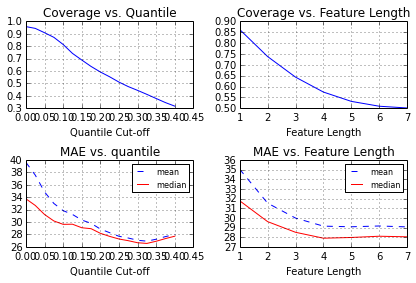

```python
myfig = getDevSetQntFtLnFig(resDFW2MedDev)
restime=time.strftime("%Y%m%d-%H%M")
myfig.savefig("../timexNelleke/"+restime+"-DevSet2MedQntFtLn-CovMae-WFeats")
restime
```

### MFeats

```python
medLimit = experimentDev.time_to_eventhF.median()
exp_MDev2med = experimentDev[(experimentDev.time_to_eventhF > -504) & (medLimit > experimentDev.time_to_eventhF)]

exp_MDev2med = extractFeats(exp_MDev2med, use_wlistM)
print("Tweet set Length:",len(exp_MDev2med))
exp_MDev2med.head(1)
```

```
Tweet set Length: 9528
```

|  | dt_etime | event | twID | user | ttext | time_to_event | time_to_eventhF | ttextlist | allFeats |
| --- | --- | --- | --- | --- | --- | --- | --- | --- | --- |
| 5 | 2012-03-04 16:46:48 | ajapsv_s12 | 176332878232305664 | xN0TxP3RF3CTx | echt weer een heerlijk dagje gehad kijk uit naar 25 maart #ajapsv | 20 days, 23:43:12 | -503.72 | [echt, weer, een, heerlijk, dagje, gehad, kijk, uit, naar, 25, maart, #ajapsv] | [heerlijk, gehad, kijk] |

1 rows × 9 columns

```python
resDFM2MedDev = run_dev_set(exp_MDev2med, elimRulesFromTrain=False, usebefmed=medLimit)
restime = time.strftime("%Y%m%d-%H%M")
resDFM2MedDev.to_pickle(restime+"-DevSet2MedQntFtLn-MFeats")#20140330-resultDFBackUP is the complete results file
restime
```

```
  17/17 tasks finished after  284 s
done
7,
```

```
'20140605-1557'
```

```
'20140605-1558'
```

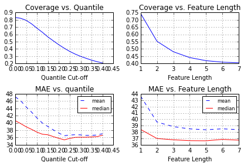

```python
myfig = getDevSetQntFtLnFig(resDFM2MedDev)
restime=time.strftime("%Y%m%d-%H%M")
myfig.savefig("../timexNelleke/"+restime+"-DevSet2MedQntFtLn-CovMae-MFeats")
restime
```

### WFeats + TFeats

```python
medLimit = experimentDev.time_to_eventhF.median()
exp_WTDev2med = experimentDev[(experimentDev.time_to_eventhF > -504) & (medLimit > experimentDev.time_to_eventhF)]

use_wlist = list(set(use_wlistW + use_wlistT))

exp_WTDev2med = extractFeats(exp_WTDev2med, use_wlist)
print("Tweet set Length:",len(exp_WTDev2med))
exp_WTDev2med.head(1)
```

```
Tweet set Length: 9528
```

|  | dt_etime | event | twID | user | ttext | time_to_event | time_to_eventhF | ttextlist | allFeats |
| --- | --- | --- | --- | --- | --- | --- | --- | --- | --- |
| 5 | 2012-03-04 16:46:48 | ajapsv_s12 | 176332878232305664 | xN0TxP3RF3CTx | echt weer een heerlijk dagje gehad kijk uit naar 25 maart #ajapsv | 20 days, 23:43:12 | -503.72 | [echt, weer, een, heerlijk, dagje, gehad, kijk, uit, naar, 25, maart, #ajapsv] | [weer, heerlijk, dagje, gehad, kijk, 25 maart] |

1 rows × 9 columns

```python
resDFWT2MedDev = run_dev_set(exp_WTDev2med, elimRulesFromTrain=False, usebefmed=medLimit)
restime = time.strftime("%Y%m%d-%H%M")
resDFWT2MedDev.to_pickle(restime+"-DevSet2MedQntFtLn-WTFeats")#20140330-resultDFBackUP is the complete results file
restime
```

```
  17/17 tasks finished after  334 s
done
7,
```

```
'20140605-1652'
```

```
'20140605-1652'
```

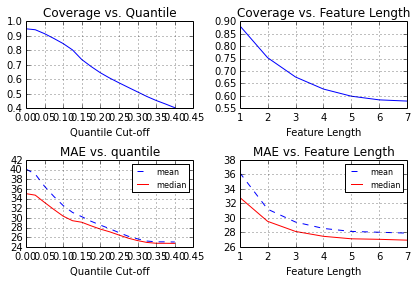

```python
myfig = getDevSetQntFtLnFig(resDFWT2MedDev)
restime=time.strftime("%Y%m%d-%H%M")
myfig.savefig("../timexNelleke/"+restime+"-DevSet2MedQntFtLn-CovMae-WTFeats")
restime
```

### TFeats

```python
medLimit = experimentDev.time_to_eventhF.median()
exp_TDev2med = experimentDev[(experimentDev.time_to_eventhF > -504) & (medLimit > experimentDev.time_to_eventhF)]

exp_TDev2med = extractFeats(exp_TDev2med, use_wlistT)
print("Tweet set Length:",len(exp_TDev2med))
exp_TDev2med.head(1)
```

```
Tweet set Length: 9528
```

|  | dt_etime | event | twID | user | ttext | time_to_event | time_to_eventhF | ttextlist | allFeats |
| --- | --- | --- | --- | --- | --- | --- | --- | --- | --- |
| 5 | 2012-03-04 16:46:48 | ajapsv_s12 | 176332878232305664 | xN0TxP3RF3CTx | echt weer een heerlijk dagje gehad kijk uit naar 25 maart #ajapsv | 20 days, 23:43:12 | -503.72 | [echt, weer, een, heerlijk, dagje, gehad, kijk, uit, naar, 25, maart, #ajapsv] | [weer, dagje, 25 maart] |

1 rows × 9 columns

```python
resDFT2MedDev = run_dev_set(exp_TDev2med, elimRulesFromTrain=False, usebefmed=medLimit)
restime = time.strftime("%Y%m%d-%H%M")
resDFT2MedDev.to_pickle(restime+"-DevSet2MedQntFtLn-TFeats")#20140330-resultDFBackUP is the complete results file
restime
```

```
  17/17 tasks finished after  310 s
done
7,
```

```
'20140605-1744'
```

```
'20140605-1756'
```

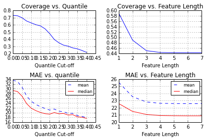

```python
myfig = getDevSetQntFtLnFig(resDFT2MedDev)
restime=time.strftime("%Y%m%d-%H%M")
myfig.savefig("../timexNelleke/"+restime+"-DevSet2MedQntFtLn-CovMae-WTFeats")
restime
```

### TFeats & Rules

```python
resDFTR2MedDev = run_loo_experiment(exp_TDev2med, lComb=1, stdThresh=0.85,throcc=1, excambtmp=True, elimRulesFromTrain=False, usebefmed=medLimit)

restime=time.strftime("%Y%m%d-%H%M")
resDFTR2MedDev.to_pickle(restime+"-DevSetRules-NoRuleElim2Med")#20140330-resultDFBackUP is the complete results file
restime
```

```
len features 1: 623
len features 2: 282
len features 3,std, medAD: 226 223
0,len features 1: 702
len features 2: 335
len features 3,std, medAD: 273 270
1,len features 1: 702
len features 2: 326
len features 3,std, medAD: 269 267
2,len features 1: 622
len features 2: 281
len features 3,std, medAD: 227 224
3,len features 1: 711
len features 2: 328
len features 3,std, medAD: 270 268
4,len features 1: 716
len features 2: 336
len features 3,std, medAD: 279 277
5,len features 1: 719
len features 2: 336
len features 3,std, medAD: 274 272
6,len features 1: 660
len features 2: 317
len features 3,std, medAD: 258 255
7,len features 1: 718
len features 2: 338
len features 3,std, medAD: 275 272
8,
```

```
'20140606-1816'
```

```python
lenres = len(resDFTR2MedDev)
lenres, resDFTR2MedDev.dynDaysTTEmea.count()
```

```
(9528, 1183)
```

```python
print("Exact rule MAE:", getMAE(resDFTR2MedDev.time_to_eventhF, resDFTR2MedDev.exactTTEmea), resDFTR2MedDev.exactTTEmea.count()/lenres)
print("Dynamic Hours MAE:", getMAE(resDFTR2MedDev.time_to_eventhF, resDFTR2MedDev.dynHoursTTEmea), resDFTR2MedDev.dynHoursTTEmea.count()/lenres)
print("Dynamic Days MAE:", getMAE(resDFTR2MedDev.time_to_eventhF, resDFTR2MedDev.dynDaysTTEmea), resDFTR2MedDev.dynDaysTTEmea.count()/lenres)
print("Dynamic Months MAE",getMAE(resDFTR2MedDev.time_to_eventhF, resDFTR2MedDev.dynMonthsTTEmea), resDFTR2MedDev.dynMonthsTTEmea.count()/lenres)
print("Median Training Mean Estimation MAE:", getMAE(resDFTR2MedDev.time_to_eventhF, resDFTR2MedDev.medMeaEstim), resDFTR2MedDev.medMeaEstim.count()/lenres)

resDFTR2MedDev["rulesMeaSerie"] = resDFTR2MedDev[["dynDaysTTEmea","dynHoursTTEmea","dynMonthsTTEmea","exactTTEmea"]].apply(np.mean,1)
print("Mean of Rules combination MAE:",getMAE(resDFTR2MedDev.time_to_eventhF, resDFTR2MedDev.rulesMeaSerie), resDFTR2MedDev.rulesMeaSerie.count()/lenres)

resDFTR2MedDev["rulesAndTrain"] = np.where(resDFTR2MedDev.rulesMeaSerie.notnull(),resDFTR2MedDev.rulesMeaSerie,resDFTR2MedDev.medMeaEstim)
print("Mean rule and Temporal exp. train combination MAE:",getMAE(resDFTR2MedDev.time_to_eventhF, resDFTR2MedDev.rulesAndTrain), resDFTR2MedDev.rulesAndTrain.count()/lenres)
```

```
Exact rule MAE: 21.7816480046 0.0406171284635
Dynamic Hours MAE: 9.9671217828 0.222921914358
Dynamic Days MAE: 9.49725274725 0.124160369437
Dynamic Months MAE 31.764957265 0.0122795969773
Median Training Mean Estimation MAE: 17.788503961 0.562132661629
Mean of Rules combination MAE: 9.98042422577 0.381821998321
Mean rule and Temporal exp. train combination MAE: 12.3381688468 0.587846347607
```

### WFeats, TFeats, Rules Combination

Use all tweets to train WFeats, but do not use the estimation on test if a Temp. estimation available for a tweet

```python
resDFW2MedDev = run_loo_experiment(exp_WDev2med, lComb=1, stdThresh=0.80,throcc=1, excambtmp=True, elimRulesFromTrain=False, usebefmed=medLimit) #last False means do not eliminate features which has a rule associated with it
restime = time.strftime("%Y%m%d-%H%M")
resDFW2MedDev.to_pickle(restime+"-DevSetWFeats-Optimized2Med")#20140330-resultDFBackUP is the complete results file
restime
```

[output not shown]

```python
getMAE(resDFW2MedDev.time_to_eventhF,resDFW2MedDev.medMeaEstim), getRMSE(resDFW2MedDev.time_to_eventhF,resDFW2MedDev.medMeaEstim)
```

```
(33.163692726912103, 69.644988671647582)
```

```python
resDFTR2MedDev["rulesTFeatsWFeats"] = np.where(resDFTR2MedDev.rulesAndTrain.notnull(),resDFTR2MedDev.rulesAndTrain,resDFW2MedDev.medMeaEstim)
print("priority:mean Rule, TFeats, WFeats -> MAE:", getMAE(resDFTR2MedDev.time_to_eventhF, resDFTR2MedDev.rulesTFeatsWFeats))
```

```
priority:mean Rule, TFeats, WFeats -> MAE: 23.8941560484
```

```python
resultsDFTRDevHist.info()
```

```python
estimSerie="rulesTFeatsWFeats"
resDFTR2MedDevHist = resDFTR2MedDev[resDFTR2MedDev[estimSerie].notnull()]
hstWlnErrDF = pd.DataFrame({"medMAE":getMAE(resDFTR2MedDevHist.time_to_eventhF, resDFTR2MedDevHist[estimSerie]),
                                                   "medRMSE":getRMSE(resDFTR2MedDevHist.time_to_eventhF, resDFTR2MedDevHist[estimSerie]),
                                                   "meaMAE":getMAE(resDFTR2MedDevHist.time_to_eventhF, resDFTR2MedDevHist[estimSerie]),
                                                   "meaRMSE":getRMSE(resDFTR2MedDevHist.time_to_eventhF, resDFTR2MedDevHist[estimSerie])}, index=[1])
for wlen in range(2,10):
    resDFTR2MedDevHist = resDFTR2MedDevHist.groupby("event").apply(calcExpandHistNorm, estimSerie, wlen)
    hstWlnErrDF = hstWlnErrDF.append(pd.DataFrame({"medMAE":getMAE(resDFTR2MedDevHist.time_to_eventhF, resDFTR2MedDevHist["histMed_"+estimSerie]),
                                                   "medRMSE":getRMSE(resDFTR2MedDevHist.time_to_eventhF, resDFTR2MedDevHist["histMed_"+estimSerie]),
                                                   "meaMAE":getMAE(resDFTR2MedDevHist.time_to_eventhF, resDFTR2MedDevHist["histMea_"+estimSerie]),
                                                   "meaRMSE":getRMSE(resDFTR2MedDevHist.time_to_eventhF, resDFTR2MedDevHist["histMea_"+estimSerie])}, index=[wlen]))

hstWlnErrDF
```

|  | meaMAE | meaRMSE | medMAE | medRMSE |
| --- | --- | --- | --- | --- |
| 1 | 23.894156 | 59.623710 | 23.894156 | 59.623710 |
| 2 | 22.873371 | 55.370340 | 22.873371 | 55.370340 |
| 3 | 22.472334 | 54.214285 | 21.657896 | 59.512214 |
| 4 | 22.332363 | 53.788336 | 21.301834 | 57.630429 |
| 5 | 22.295300 | 53.709464 | 21.236773 | 60.530811 |
| 6 | 22.307419 | 53.817206 | 21.084774 | 59.196633 |
| 7 | 22.354796 | 54.027205 | 21.250453 | 61.390124 |
| 8 | 22.423772 | 54.274952 | 21.231478 | 60.684661 |
| 9 | 22.504342 | 54.554880 | 21.405697 | 62.293351 |

9 rows × 4 columns

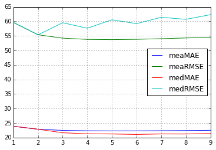

```python
hstWlnErrDF.plot()
```

## Hyper Parameter Optimization Result

for TFeatures featlen=2, Quant=0.25 for TFeats and 0.20 for WFeats, occurrence Threshold=1 Notes: WFeats trained on all tweets, which has timex as well. But it does not make any estimation if there is one by other modules. See below. Priority of estimations: rules, temp train estimations, word train estimation

# Experiment on test Set using optimized parameters

## try clock times in WFeats

some variables should be defined in the development set section

```python
# set the experiment
experimentCT = event_table[~event_table.event.isin(dev_set)] # just the devset!

# 8, 0 is between event time and 8 day before. -8, 0 is between event time and 8 days after. Use a range!
experimentCT = experimentCT[(experimentCT.time_to_event < np.timedelta64(8,'D')) & (experimentCT.time_to_event > np.timedelta64(0,'D'))]
#experiment = experiment[(experiment.time_to_event < np.timedelta64(21,'D')) & (experiment.time_to_event > np.timedelta64(2,'h'))]

experimentCT = getNonRT(experimentCT) # eliminate RT's
len(experimentCT)
```

```
119534
```

```python
experimentCT["ttext"] = experimentCT.ttext.replace(clck_times_ptrn, "clock_times")
experimentCT["ttextlist"] = experimentCT.ttext.str.split()

# prepare dev set experiment
use_wlistW = getOccWords(experimentCT, useWordSet, thres=1)

use_wlistW.append("clock_times")

print("Tweet set Length:",len(experimentCT))
experimentCT.head(1)
```

```
Tweet set Length: 119534
```

|  | dt_etime | event | twID | user | ttext | time_to_event | time_to_eventhF | ttextlist | allFeats |
| --- | --- | --- | --- | --- | --- | --- | --- | --- | --- |
| 25867 | 2012-01-23 21:06:29 | feyaja_s12 | 161540326731952129 | VELOD1 | van rhijn zou wel eens de klassieker kunnen spelen hij was er een keer eerder bij nederland finland #ajautr #feyaja #voetbalnieuws | 5 days, 15:23:31 | -135.391944 | [van, rhijn, zou, wel, eens, de, klassieker, kunnen, spelen, hij, was, er, een, keer, eerder, bij, nederland, finland, #ajautr, #feyaja, #voetbalnieuws] | [klassieker, spelen, eerder, finland] |

```python
experimentCT[experimentCT.ttext.str.contains("clock_times")]
```

|  | dt_etime | event | twID | user | ttext | time_to_event | time_to_eventhF | ttextlist | allFeats |
| --- | --- | --- | --- | --- | --- | --- | --- | --- | --- |
| 26035 | 2012-02-01 12:30:50 | ajautr_s12 | 164672050043166720 | ajax1nl | vandaag om clock_times uur maken wij de winnaar bekend van de 2 kaarten voor #ajautr vind ons leuk en win http://t.co/6paefylm #ajax | 3 days, 23:59:10 | -95.986111 | [vandaag, om, clock_times, uur, maken, wij, de, winnaar, bekend, van, de, 2, kaarten, voor, #ajautr, vind, ons, leuk, en, win, http://t.co/6paefylm, #ajax] | [vandaag, clock_times, uur, maken, winnaar, bekend, kaarten, vind, leuk, win] |
| 27012 | 2012-02-04 23:56:55 | ajautr_s12 | 165931872512253952 | caaaittvde | wekkertje om clock_times zodat ik optijd ben voor #ajautr die om clock_times beginnen | 0 days, 12:33:05 | -12.551389 | [wekkertje, om, clock_times, zodat, ik, optijd, ben, voor, #ajautr, die, om, clock_times, beginnen] | [wekkertje, clock_times, clock_times, beginnen] |
| 27042 | 2012-02-05 01:23:44 | ajautr_s12 | 165953717189885953 | J0sTi | morgen om clock_times ajax a 1 fc utrecht #ajautr | 0 days, 11:06:16 | -11.104444 | [morgen, om, clock_times, ajax, a, 1, fc, utrecht, #ajautr] | [morgen, clock_times] |
| 27092 | 2012-02-05 05:07:45 | ajautr_s12 | 166010094406991873 | o_fenomeno_RH | clock_times tempo pr ir dormir daqui um pouco #ajautr laatste keer voor #tenhaverotop in de arena schurkenboom ook ophoeren | 0 days, 07:22:15 | -7.370833 | [clock_times, tempo, pr, ir, dormir, daqui, um, pouco, #ajautr, laatste, keer, voor, #tenhaverotop, in, de, arena, schurkenboom, ook, ophoeren] | [clock_times, tempo, pr, laatste] |
| 27104 | 2012-02-05 07:27:40 | ajautr_s12 | 166045303974277121 | epreij | clock_times u #ajautr ★ wij zijn ajax ★wij zijn de beste ★ | 0 days, 05:02:20 | -5.038889 | [clock_times, u, #ajautr, ★, wij, zijn, ajax, ★wij, zijn, de, beste, ★] | [clock_times] |
| 27108 | 2012-02-05 07:48:00 | ajautr_s12 | 166050423688531968 | sanderafca | nog ff slaap pakken om clock_times is ajax a 2 utrecht weer #ajautr | 0 days, 04:42:00 | -4.700000 | [nog, ff, slaap, pakken, om, clock_times, is, ajax, a, 2, utrecht, weer, #ajautr] | [slaap, pakken, clock_times, weer] |
| 27157 | 2012-02-05 08:21:41 | ajautr_s12 | 166058900834103296 | ajax1nl | wakker worden matchday om clock_times uur speelt de hoofdstad tegen de domstad #ajautr #ajax | 0 days, 04:08:19 | -4.138611 | [wakker, worden, matchday, om, clock_times, uur, speelt, de, hoofdstad, tegen, de, domstad, #ajautr, #ajax] | [clock_times, uur, speelt, hoofdstad, domstad] |
| 27159 | 2012-02-05 08:22:00 | ajautr_s12 | 166058979179507712 | DennisvanTiel | vandaag maar 4 wedstrijden in de #eredivisie om clock_times #ajautr clock_times #herpsv maar ook #necfey en om clock_times komt ook gro op bezoek bij rkc | 0 days, 04:08:00 | -4.133333 | [vandaag, maar, 4, wedstrijden, in, de, #eredivisie, om, clock_times, #ajautr, clock_times, #herpsv, maar, ook, #necfey, en, om, clock_times, komt, ook, gro, op, bezoek, bij, rkc] | [vandaag, wedstrijden, eredivisie, clock_times, clock_times, clock_times, komt, bezoek] |
| 27181 | 2012-02-05 08:23:28 | ajautr_s12 | 166059347292590080 | giske90 | wakker worden matchday om clock_times uur speelt de hoofdstad tegen de domstad #ajautr #ajax | 0 days, 04:06:32 | -4.108889 | [wakker, worden, matchday, om, clock_times, uur, speelt, de, hoofdstad, tegen, de, domstad, #ajautr, #ajax] | [clock_times, uur, speelt, hoofdstad, domstad] |
| 27189 | 2012-02-05 08:24:09 | ajautr_s12 | 166059520450236416 | Svenson8 | “ @ajax1nl wakker worden matchday om clock_times uur speelt de hoofdstad tegen de domstad #ajautr #ajax ” | 0 days, 04:05:51 | -4.097500 | [“, @ajax1nl, wakker, worden, matchday, om, clock_times, uur, speelt, de, hoofdstad, tegen, de, domstad, #ajautr, #ajax, ”] | [clock_times, uur, speelt, hoofdstad, domstad] |
| 27203 | 2012-02-05 08:26:07 | ajautr_s12 | 166060015894020096 | AFCALariZ | wakker worden om clock_times speelt ajax tegen domstad gevoelstemp vanmiddag in de rij voor de controle -11 #ajautr | 0 days, 04:03:53 | -4.064722 | [wakker, worden, om, clock_times, speelt, ajax, tegen, domstad, gevoelstemp, vanmiddag, in, de, rij, voor, de, controle, -11, #ajautr] | [clock_times, speelt, domstad, vanmiddag, rij, controle] |
| 27223 | 2012-02-05 08:29:17 | ajautr_s12 | 166060812866297857 | philip0252 | @ajax1nl wakker worden matchday om clock_times uur speelt de hoofdstad tegen de domstad #ajautr #ajax en ik ben er bij | 0 days, 04:00:43 | -4.011944 | [@ajax1nl, wakker, worden, matchday, om, clock_times, uur, speelt, de, hoofdstad, tegen, de, domstad, #ajautr, #ajax, en, ik, ben, er, bij] | [clock_times, uur, speelt, hoofdstad, domstad] |
| 27247 | 2012-02-05 08:35:47 | ajautr_s12 | 166062448447733760 | Tommer99 | “ @ajax1nl wakker worden matchday om clock_times uur speelt de hoofdstad tegen de domstad #ajautr #ajax ” ga er heen | 0 days, 03:54:13 | -3.903611 | [“, @ajax1nl, wakker, worden, matchday, om, clock_times, uur, speelt, de, hoofdstad, tegen, de, domstad, #ajautr, #ajax, ”, ga, er, heen] | [clock_times, uur, speelt, hoofdstad, domstad, ga] |
| 27275 | 2012-02-05 08:43:06 | ajautr_s12 | 166064290846089217 | NLAFCA | @ajax1nl wakker worden matchday om clock_times uur speelt de hoofdstad tegen de domstad #ajautr #ajax | 0 days, 03:46:54 | -3.781667 | [@ajax1nl, wakker, worden, matchday, om, clock_times, uur, speelt, de, hoofdstad, tegen, de, domstad, #ajautr, #ajax] | [clock_times, uur, speelt, hoofdstad, domstad] |
| 27313 | 2012-02-05 08:53:02 | ajautr_s12 | 166066787304214528 | julianpol1 | rt “ @ajax1nl wakker worden matchday om clock_times uur speelt de hoofdstad tegen de domstad #ajautr #ajax ” | 0 days, 03:36:58 | -3.616111 | [rt, “, @ajax1nl, wakker, worden, matchday, om, clock_times, uur, speelt, de, hoofdstad, tegen, de, domstad, #ajautr, #ajax, ”] | [clock_times, uur, speelt, hoofdstad, domstad] |
| 27324 | 2012-02-05 08:57:35 | ajautr_s12 | 166067934895157248 | paulinthedark | wat een stomme grap rt “ @ajax1nl wakker worden matchday om clock_times uur speelt de hoofdstad tegen de domstad #ajautr #ajax ” | 0 days, 03:32:25 | -3.540278 | [wat, een, stomme, grap, rt, “, @ajax1nl, wakker, worden, matchday, om, clock_times, uur, speelt, de, hoofdstad, tegen, de, domstad, #ajautr, #ajax, ”] | [stomme, grap, clock_times, uur, speelt, hoofdstad, domstad] |
| 27366 | 2012-02-05 09:07:42 | ajautr_s12 | 166070478698577920 | KoenAFCA14 | haalt ajax vandaag hun 1e zege van 2012 dat gaan we zien clock_times #ajautr | 0 days, 03:22:18 | -3.371667 | [haalt, ajax, vandaag, hun, 1e, zege, van, 2012, dat, gaan, we, zien, clock_times, #ajautr] | [haalt, vandaag, zege, gaan, zien, clock_times] |
| 27410 | 2012-02-05 09:18:45 | ajautr_s12 | 166073260168056832 | frenk1e | @ajax1nl wakker worden matchday om clock_times uur speelt de hoofdstad tegen de domstad #ajautr #ajax | 0 days, 03:11:15 | -3.187500 | [@ajax1nl, wakker, worden, matchday, om, clock_times, uur, speelt, de, hoofdstad, tegen, de, domstad, #ajautr, #ajax] | [clock_times, uur, speelt, hoofdstad, domstad] |
| 27420 | 2012-02-05 09:22:26 | ajautr_s12 | 166074187188932608 | ronaldplas1977 | ik zeg 3 punten en niets minder @ajax1nl wakker worden matchday om clock_times uur speelt de hoofdstad tegen de domstad #ajautr #ajax | 0 days, 03:07:34 | -3.126111 | [ik, zeg, 3, punten, en, niets, minder, @ajax1nl, wakker, worden, matchday, om, clock_times, uur, speelt, de, hoofdstad, tegen, de, domstad, #ajautr, #ajax] | [zeg, punten, minder, clock_times, uur, speelt, hoofdstad, domstad] |
| 27479 | 2012-02-05 09:35:59 | ajautr_s12 | 166077599137800194 | Chaja98 | @ajax1nl wakker worden matchday om clock_times uur speelt de hoofdstad tegen de domstad #ajautr #ajax yeaaah :) | 0 days, 02:54:01 | -2.900278 | [@ajax1nl, wakker, worden, matchday, om, clock_times, uur, speelt, de, hoofdstad, tegen, de, domstad, #ajautr, #ajax, yeaaah, :)] | [clock_times, uur, speelt, hoofdstad, domstad] |
| 27491 | 2012-02-05 09:37:52 | ajautr_s12 | 166078073656193026 | JSietzema | dan straks maar van bed af ontbijten tv kijken en om clock_times #ajautr kijken | 0 days, 02:52:08 | -2.868889 | [dan, straks, maar, van, bed, af, ontbijten, tv, kijken, en, om, clock_times, #ajautr, kijken] | [straks, bed, ontbijten, tv, kijken, clock_times, kijken] |
| 28094 | 2012-02-05 10:23:28 | ajautr_s12 | 166089548370165760 | MJBeijeman | ik wens mijn fcu-volgers veel plezier maar geen punten straks onze smoesjes kou blessures clock_times #tenhave jullie al voorbereid #ajautr | 0 days, 02:06:32 | -2.108889 | [ik, wens, mijn, fcu-volgers, veel, plezier, maar, geen, punten, straks, onze, smoesjes, kou, blessures, clock_times, #tenhave, jullie, al, voorbereid, #ajautr] | [volgers, plezier, punten, straks, smoesjes, kou, blessures, clock_times, voorbereid] |
| 28108 | 2012-02-05 10:24:44 | ajautr_s12 | 166089866952708096 | KoenAFCA14 | clock_times #matchday voor #ajax de hoofdstad speelt tegen de domstad #ajautr | 0 days, 02:05:16 | -2.087778 | [clock_times, #matchday, voor, #ajax, de, hoofdstad, speelt, tegen, de, domstad, #ajautr] | [clock_times, hoofdstad, speelt, domstad] |
| 28160 | 2012-02-05 10:30:13 | ajautr_s12 | 166091244336971776 | NielsNesta | “ @ajax1nl wakker worden matchday om clock_times uur speelt de hoofdstad tegen de domstad #ajautr #ajax ” | 0 days, 01:59:47 | -1.996389 | [“, @ajax1nl, wakker, worden, matchday, om, clock_times, uur, speelt, de, hoofdstad, tegen, de, domstad, #ajautr, #ajax, ”] | [clock_times, uur, speelt, hoofdstad, domstad] |
| 28190 | 2012-02-05 10:33:27 | ajautr_s12 | 166092060494020609 | SaidVanenburg | zoontje heeft vandaag een feestje of ik hem daar om clock_times wil brengen ik denk dat hij een beetje te vroeg zal zijn #ajautr | 0 days, 01:56:33 | -1.942500 | [zoontje, heeft, vandaag, een, feestje, of, ik, hem, daar, om, clock_times, wil, brengen, ik, denk, dat, hij, een, beetje, te, vroeg, zal, zijn, #ajautr] | [zoontje, vandaag, feestje, clock_times, brengen, denk, beetje, vroeg] |
| 28199 | 2012-02-05 10:34:35 | ajautr_s12 | 166092344112848896 | JeffMOD | mooiste verjaardagscadeau van vandaag krijg ik om clock_times een grote overwinning op utrecht :) #ajautr @ajaxlife @ajax1nl | 0 days, 01:55:25 | -1.923611 | [mooiste, verjaardagscadeau, van, vandaag, krijg, ik, om, clock_times, een, grote, overwinning, op, utrecht, :), #ajautr, @ajaxlife, @ajax1nl] | [mooiste, verjaardagscadeau, vandaag, krijg, clock_times, grote, overwinning] |
| 28306 | 2012-02-05 10:47:45 | ajautr_s12 | 166095656371494912 | Marvin_AFCA | “ @ajax1nl wakker worden matchday om clock_times uur speelt de hoofdstad tegen de domstad #ajautr #ajax ” | 0 days, 01:42:15 | -1.704167 | [“, @ajax1nl, wakker, worden, matchday, om, clock_times, uur, speelt, de, hoofdstad, tegen, de, domstad, #ajautr, #ajax, ”] | [clock_times, uur, speelt, hoofdstad, domstad] |
| 28465 | 2012-02-05 11:03:23 | ajautr_s12 | 166099592709021696 | Gescoord | vanaf clock_times uur #ajax #fcutrecht te volgen via @gescoord #ajautr #eredivisie #voetbal http://t.co/xpci31pq | 0 days, 01:26:37 | -1.443611 | [vanaf, clock_times, uur, #ajax, #fcutrecht, te, volgen, via, @gescoord, #ajautr, #eredivisie, #voetbal, http://t.co/xpci31pq] | [clock_times, uur, volgen, gescoord, eredivisie, voetbal] |
| 28577 | 2012-02-05 11:16:28 | ajautr_s12 | 166102885992636416 | jeroentw | @jespwell zie ik jou om clock_times in de woonkamer om #ajautr te kijken | 0 days, 01:13:32 | -1.225556 | [@jespwell, zie, ik, jou, om, clock_times, in, de, woonkamer, om, #ajautr, te, kijken] | [zie, clock_times, woonkamer, kijken] |
| 28818 | 2012-02-05 11:41:08 | ajautr_s12 | 166109090664296448 | AjaxFSideNL | straks natuurlijk weer een live-twitterverslag van ajax fc utrecht aftrap is om clock_times uur #ajautr #ajax #020isdebaasinamsterdam | 0 days, 00:48:52 | -0.814444 | [straks, natuurlijk, weer, een, live-twitterverslag, van, ajax, fc, utrecht, aftrap, is, om, clock_times, uur, #ajautr, #ajax, #020isdebaasinamsterdam] | [straks, weer, live, aftrap, clock_times, uur] |
| ... | ... | ... | ... | ... | ... | ... | ... | ... | ... |
| 675162 | 2011-11-06 08:52:50 | utraja_f11 | 133089441337188352 | movalleivogels | @ajax1nl matchday om clock_times uur #utraja wat wordt de uitslag #ajax 1 -3 | 0 days, 03:37:10 | -3.619444 | [@ajax1nl, matchday, om, clock_times, uur, #utraja, wat, wordt, de, uitslag, #ajax, 1, -3] | [clock_times, uur, uitslag] |
| 675228 | 2011-11-06 09:20:40 | utraja_f11 | 133096449322926080 | sjoerdjjee | @ajax1nl matchday om clock_times uur #utraja wat wordt de uitslag #ajax | 0 days, 03:09:20 | -3.155556 | [@ajax1nl, matchday, om, clock_times, uur, #utraja, wat, wordt, de, uitslag, #ajax] | [clock_times, uur, uitslag] |
| 675264 | 2011-11-06 09:32:45 | utraja_f11 | 133099489002143744 | floris66 | “ @ajax1nl matchday om clock_times uur #utraja wat wordt de uitslag #ajax ” 1 -3 | 0 days, 02:57:15 | -2.954167 | [“, @ajax1nl, matchday, om, clock_times, uur, #utraja, wat, wordt, de, uitslag, #ajax, ”, 1, -3] | [clock_times, uur, uitslag] |
| 675300 | 2011-11-06 09:42:15 | utraja_f11 | 133101877511467009 | Brian0172TA | @ajax1nl matchday om clock_times uur #utraja wat wordt de uitslag #ajax 0 -3 | 0 days, 02:47:45 | -2.795833 | [@ajax1nl, matchday, om, clock_times, uur, #utraja, wat, wordt, de, uitslag, #ajax, 0, -3] | [clock_times, uur, uitslag] |
| 675412 | 2011-11-06 10:16:46 | utraja_f11 | 133110565202702336 | MelvinStuifzand | matchday om clock_times uur #utraja #ajax | 0 days, 02:13:14 | -2.220556 | [matchday, om, clock_times, uur, #utraja, #ajax] | [clock_times, uur] |
| 675442 | 2011-11-06 10:25:58 | utraja_f11 | 133112879049216000 | mikkel11 | clock_times #utraja kijken :) | 0 days, 02:04:02 | -2.067222 | [clock_times, #utraja, kijken, :)] | [clock_times, kijken] |
| 675454 | 2011-11-06 10:29:11 | utraja_f11 | 133113691724984321 | jossseee01234 | om clock_times #utraja kijken | 0 days, 02:00:49 | -2.013611 | [om, clock_times, #utraja, kijken] | [clock_times, kijken] |
| 675738 | 2011-11-06 10:38:48 | utraja_f11 | 133116111880339457 | duncanthekingz | rt “ @ajax1nl matchday om clock_times uur #utraja wat wordt de uitslag #ajax ” 3 -2 voor #utrecht | 0 days, 01:51:12 | -1.853333 | [rt, “, @ajax1nl, matchday, om, clock_times, uur, #utraja, wat, wordt, de, uitslag, #ajax, ”, 3, -2, voor, #utrecht] | [clock_times, uur, uitslag] |
| 675815 | 2011-11-06 10:44:36 | utraja_f11 | 133117571225485313 | Fifa12_nl | clock_times trappen we af met ajax-utrecht pakt de regerend kampioen 3 punten of zorgt wouters voor een stunt #utraja | 0 days, 01:45:24 | -1.756667 | [clock_times, trappen, we, af, met, ajax-utrecht, pakt, de, regerend, kampioen, 3, punten, of, zorgt, wouters, voor, een, stunt, #utraja] | [clock_times, trappen, pakt, regerend, kampioen, punten, zorgt, stunt] |
| 675922 | 2011-11-06 10:52:32 | utraja_f11 | 133119565608648704 | sam_vk | om clock_times #utraja en er kunnen hele goeie zaken gedaan worden in utreg #letsdothis | 0 days, 01:37:28 | -1.624444 | [om, clock_times, #utraja, en, er, kunnen, hele, goeie, zaken, gedaan, worden, in, utreg, #letsdothis] | [clock_times, hele, zaken, gedaan] |
| 676047 | 2011-11-06 11:02:37 | utraja_f11 | 133122105570115584 | Gescoord | vanaf clock_times uur #fcutrecht #ajax te volgen via @gescoord #utraja #eredivisie #voetbal http://t.co/pz4okmbg | 0 days, 01:27:23 | -1.456389 | [vanaf, clock_times, uur, #fcutrecht, #ajax, te, volgen, via, @gescoord, #utraja, #eredivisie, #voetbal, http://t.co/pz4okmbg] | [clock_times, uur, volgen, gescoord, eredivisie, voetbal] |
| 676106 | 2011-11-06 11:09:12 | utraja_f11 | 133123759690350593 | patrickuitzettr | vanmiddag clock_times #utraja heb er zin in | 0 days, 01:20:48 | -1.346667 | [vanmiddag, clock_times, #utraja, heb, er, zin, in] | [vanmiddag, clock_times, zin] |
| 676348 | 2011-11-06 11:25:50 | utraja_f11 | 133127944565567489 | JanGrasdijk | al een tijdje wakker & zomaar eens naar beneden & dan clock_times #ajax kijken met frankie #utraja | 0 days, 01:04:10 | -1.069444 | [al, een, tijdje, wakker, &, zomaar, eens, naar, beneden, &, dan, clock_times, #ajax, kijken, met, frankie, #utraja] | [tijdje, zomaar, clock_times, kijken] |
| 676473 | 2011-11-06 11:34:00 | utraja_f11 | 133130002093977600 | CafeHilander | vandaag de top 4 vd eredivisie live op het grote scherm #utraja om clock_times uur we zijn al open dus kom maar op let's do this #zondag | 0 days, 00:56:00 | -0.933333 | [vandaag, de, top, 4, vd, eredivisie, live, op, het, grote, scherm, #utraja, om, clock_times, uur, we, zijn, al, open, dus, kom, maar, op, let's, do, this, #zondag] | [vandaag, eredivisie, live, grote, scherm, clock_times, uur, kom, let, zondag] |
| 676607 | 2011-11-06 11:48:21 | utraja_f11 | 133133611783303169 | JS8823 | matchday om clock_times uur utrecht #ajax #utraja | 0 days, 00:41:39 | -0.694167 | [matchday, om, clock_times, uur, utrecht, #ajax, #utraja] | [clock_times, uur] |
| 676708 | 2011-11-06 11:57:00 | utraja_f11 | 133135791856685056 | StevenZ_ | ga maar even leren en dan clock_times #utraja | 0 days, 00:33:00 | -0.550000 | [ga, maar, even, leren, en, dan, clock_times, #utraja] | [ga, leren, clock_times] |
| 676746 | 2011-11-06 11:59:48 | utraja_f11 | 133136495916752896 | StephanvRooijen | om clock_times #utraja nu al spanning in het stadion ajax maakt veel los hoop op een mooie pot | 0 days, 00:30:12 | -0.503333 | [om, clock_times, #utraja, nu, al, spanning, in, het, stadion, ajax, maakt, veel, los, hoop, op, een, mooie, pot] | [clock_times, spanning, stadion, maakt, los, hoop, mooie, pot] |
| 676803 | 2011-11-06 12:04:11 | utraja_f11 | 133137598637019136 | soccerforfree | #fcutrecht #ajax clock_times vandaag op dsc 1 http://t.co/zsyzh7cr en dsc 5 http://t.co/lkdfjztd #utraja #voetbal #eredivisie | 0 days, 00:25:49 | -0.430278 | [#fcutrecht, #ajax, clock_times, vandaag, op, dsc, 1, http://t.co/zsyzh7cr, en, dsc, 5, http://t.co/lkdfjztd, #utraja, #voetbal, #eredivisie] | [clock_times, vandaag, voetbal, eredivisie] |
| 676835 | 2011-11-06 12:06:50 | utraja_f11 | 133138266458304512 | Jensdezwarte | clock_times bed uit clock_times op de bank voor #utraja | 0 days, 00:23:10 | -0.386111 | [clock_times, bed, uit, clock_times, op, de, bank, voor, #utraja] | [clock_times, bed, clock_times, bank] |
| 676851 | 2011-11-06 12:07:55 | utraja_f11 | 133138538647650304 | TheovanRijn1 | @careldem in leidschendam beginnen de televisieuitzendingen altijd pas om clock_times #utraja | 0 days, 00:22:05 | -0.368056 | [@careldem, in, leidschendam, beginnen, de, televisieuitzendingen, altijd, pas, om, clock_times, #utraja] | [beginnen, altijd, pas, clock_times] |
| 677005 | 2011-11-06 12:17:36 | utraja_f11 | 133140973990576129 | Gescoord | er kan nog tot clock_times ingezet worden op #utraja tweet bijv. @gescoord #utraja 2 -1 http://t.co/dbjlttpo | 0 days, 00:12:24 | -0.206667 | [er, kan, nog, tot, clock_times, ingezet, worden, op, #utraja, tweet, bijv., @gescoord, #utraja, 2, -1, http://t.co/dbjlttpo] | [clock_times, ingezet, gescoord] |
| 698878 | 2011-11-29 19:28:23 | utrtwe_f11 | 141584305938907137 | LiveEredivisie_ | vanmiddag vanaf clock_times fc utrecht fc twente hiervan wordt alleen de eindstand vermeld voorspellen kan wel gewoon #utrtwe | 4 days, 19:01:37 | -115.026944 | [vanmiddag, vanaf, clock_times, fc, utrecht, fc, twente, hiervan, wordt, alleen, de, eindstand, vermeld, voorspellen, kan, wel, gewoon, #utrtwe] | [vanmiddag, clock_times, eindstand, vermeld, voorspellen, gewoon] |
| 698962 | 2011-12-03 22:25:38 | utrtwe_f11 | 143078461437779968 | BRRYDDDM | zo naar bed morgen #feypsv #utrtwe & #heeaz kijken vanaf clock_times u op eredivisie live #praatmee | 0 days, 16:04:22 | -16.072778 | [zo, naar, bed, morgen, #feypsv, #utrtwe, &, #heeaz, kijken, vanaf, clock_times, u, op, eredivisie, live, #praatmee] | [bed, morgen, kijken, clock_times, eredivisie, live] |
| 698964 | 2011-12-03 22:42:42 | utrtwe_f11 | 143082756107280384 | Fctstijn93 | weet iemand of fctdenekamp bus morgen gewoon clock_times in tilgte weggaat #utrtwe | 0 days, 15:47:18 | -15.788333 | [weet, iemand, of, fctdenekamp, bus, morgen, gewoon, clock_times, in, tilgte, weggaat, #utrtwe] | [weet, morgen, gewoon, clock_times, weggaat] |
| 698984 | 2011-12-04 08:24:19 | utrtwe_f11 | 143229125769965568 | LiveVoetbal_NL | vandaag clock_times #feypsv clock_times #vitrkc #utrtwe clock_times #heeaz | 0 days, 06:05:41 | -6.094722 | [vandaag, clock_times, #feypsv, clock_times, #vitrkc, #utrtwe, clock_times, #heeaz] | [vandaag, clock_times, clock_times, clock_times] |
| 699065 | 2011-12-04 10:06:43 | utrtwe_f11 | 143254897964498944 | LiveEredivisie_ | vanmiddag vanaf clock_times fc utrecht fc twente hiervan wordt alleen de eindstand vermeld voorspellen kan wel gewoon #utrtwe | 0 days, 04:23:17 | -4.388056 | [vanmiddag, vanaf, clock_times, fc, utrecht, fc, twente, hiervan, wordt, alleen, de, eindstand, vermeld, voorspellen, kan, wel, gewoon, #utrtwe] | [vanmiddag, clock_times, eindstand, vermeld, voorspellen, gewoon] |
| 699117 | 2011-12-04 11:02:50 | utrtwe_f11 | 143269019858907136 | Gescoord | vanaf clock_times uur #fcutrecht #fctwente te volgen via @gescoord #utrtwe #eredivisie #voetbal http://t.co/p7sxwhar | 0 days, 03:27:10 | -3.452778 | [vanaf, clock_times, uur, #fcutrecht, #fctwente, te, volgen, via, @gescoord, #utrtwe, #eredivisie, #voetbal, http://t.co/p7sxwhar] | [clock_times, uur, volgen, gescoord, eredivisie, voetbal] |
| 699166 | 2011-12-04 11:48:13 | utrtwe_f11 | 143280437622620160 | soccerforfree | #fcutrecht #fctwente clock_times vandaag op dsc 5 http://t.co/lkdfjztd en 13 th stream http://t.co/8czlolrg #utrtwe #voetbal #eredivsiie | 0 days, 02:41:47 | -2.696389 | [#fcutrecht, #fctwente, clock_times, vandaag, op, dsc, 5, http://t.co/lkdfjztd, en, 13, th, stream, http://t.co/8czlolrg, #utrtwe, #voetbal, #eredivsiie] | [clock_times, vandaag, voetbal] |
| 699167 | 2011-12-04 11:48:51 | utrtwe_f11 | 143280600374181888 | soccerforfree | #fcutrecht #fctwente clock_times vandaag op dsc 5 http://t.co/lkdfjztd en 13 th stream http://t.co/8czlolrg #utrtwe #voetbal #eredivsie | 0 days, 02:41:09 | -2.685833 | [#fcutrecht, #fctwente, clock_times, vandaag, op, dsc, 5, http://t.co/lkdfjztd, en, 13, th, stream, http://t.co/8czlolrg, #utrtwe, #voetbal, #eredivsie] | [clock_times, vandaag, voetbal] |
| 699382 | 2011-12-04 14:23:55 | utrtwe_f11 | 143319622110806016 | LennAndriesse | clock_times fc utrecht fc twente kijken #utrtwe | 0 days, 00:06:05 | -0.101389 | [clock_times, fc, utrecht, fc, twente, kijken, #utrtwe] | [clock_times, kijken] |

1614 rows × 9 columns

```python
experimentWCT = extractFeats(experimentCT, use_wlistW)
print(len(experimentCT))
tstResultDFWCT = run_loo_experimentP(experimentCT, lComb=2, stdThresh=0.80,throcc=1,excambtmp=False,elimRulesFromTrain=False) # run it with optimized parameters
tstResultDFWCT.to_pickle(time.strftime("%Y%m%d-%H%M")+"-testWFeatsFLen3Qnt75ExcTmpFlsElimRulesTrCT")
```

```
  25/25 tasks finished after  569 s
done
```

```python
getMAE(tstResultDFWCT.time_to_eventhF, tstResultDFWCT.medMeaEstim), tstResultDFWCT.medMeaEstim.count()/len(tstResultDFWCT)
```

```
(13.628940172530926, 0.82708685394950388)
```

## Actual experiment

```python
fm_resultsDict = {"Rules":{},"TFeats":{},"WFeats":{},"Combination":{},"Median Baseline":{},"Mean Baseline":{}}
```

```python
experiment = event_table[~event_table.event.isin(dev_set)] # # set the experiment, just the devset!
# 8, 0 is between event time and 8 day before. -8, 0 is between event time and 8 days after. Use a range!
experiment = experiment[(experiment.time_to_event < np.timedelta64(8,'D')) & (experiment.time_to_event > np.timedelta64(0,'D'))]
experiment = getNonRT(experiment) # eliminate RT's
len(experiment)
```

```
120930
```

```python
# len of occurred keyterms with frequency threshold=0 and selected ones threshold=1
use_wlistW = getOccWords(experiment, useWordSet, thres=1)
len(getOccWords(experiment, useWordSet, thres=0)), len(use_wlistW)
```

```
(16685, 9615)
```

```python
# extract features!
experimentW = extractFeats(experiment, use_wlistW)
```

```python
tstResultDFW_excAmb = run_loo_experimentP(experimentW, lComb=2, stdThresh=0.80,throcc=1,excambtmp=True,elimRulesFromTrain=False) # run it with optimized parameters
tstResultDFW_excAmb.to_pickle(time.strftime("%Y%m%d-%H%M")+"-testWFeatsFLen2Qnt80ExcTmpFlsElimRulesFls_excAmb")
```

```
  26/26 tasks finished after 1016 s
done
```

```python
WFeatsResPerEvent_excAmb = tstResultDFW_excAmb.groupby("event").apply(lambda g:pd.Series({"MAE":getMAE(g.time_to_eventhF,g.medMedEstim),"RMSE":getRMSE(g.time_to_eventhF,g.medMedEstim), "twCount":len(g)}))
WFeatsResPerEvent_excAmb.sort("MAE")
```

| event | MAE | RMSE | twCount |
| --- | --- | --- | --- |
| azpsv_s11 | 5.645907 | 14.135448 | 346 |
| tweaz_f12 | 6.285954 | 17.668636 | 547 |
| utrtwe_s11 | 7.006603 | 19.910808 | 688 |
| psvaja_s11 | 7.257634 | 21.886630 | 4550 |
| utrpsv_s12 | 7.279442 | 19.123552 | 719 |
| azpsv_f11 | 7.341297 | 22.588289 | 899 |
| azfey_f11 | 7.352511 | 21.329752 | 1578 |
| utraz_s12 | 7.391703 | 19.795740 | 243 |
| utrfey_f12 | 7.456912 | 21.245565 | 1241 |
| utrtwe_f11 | 7.543897 | 22.470704 | 481 |
| psvaz_f12 | 7.706222 | 21.156648 | 735 |
| ajaaz_s11 | 7.977786 | 19.212949 | 1189 |
| aztwe_s12 | 8.154207 | 20.852789 | 925 |
| ajaaz_f11 | 8.169315 | 23.569449 | 1852 |
| psvutr_s11 | 8.217946 | 20.919602 | 430 |
| twefey_f12 | 8.283871 | 21.563368 | 1824 |
| ajafey_s11 | 8.408741 | 21.864757 | 4771 |
| azutr_f11 | 8.656222 | 18.234261 | 233 |
| azaja_s12 | 8.657754 | 22.168009 | 1668 |
| utraja_f11 | 8.850955 | 24.085808 | 1450 |
| utraz_f12 | 8.859081 | 17.248508 | 191 |
| ajatwe_f11 | 8.884140 | 23.751143 | 3171 |
| feyutr_s12 | 9.258037 | 22.816169 | 949 |
| tweaz_f11 | 9.546181 | 24.681497 | 799 |
| psvaja_f11 | 9.653606 | 26.079483 | 4646 |
| tweutr_s12 | 9.775374 | 28.855333 | 539 |
| utraja_s11 | 9.783259 | 23.709866 | 1188 |
| twefey_s11 | 10.162022 | 29.702780 | 799 |
| twefey_s12 | 10.347065 | 26.459677 | 1618 |
| utrpsv_f12 | 10.567271 | 27.475761 | 673 |
| psvaz_s12 | 10.602626 | 23.871213 | 756 |
| ajautr_s12 | 10.852719 | 28.625380 | 1691 |
| tweaja_s12 | 11.144692 | 28.906665 | 3361 |
| feytwe_f11 | 11.147779 | 28.240941 | 1963 |
| ajatwe_f12 | 11.163389 | 23.579786 | 2491 |
| ajafey_f11 | 11.467713 | 29.641711 | 7938 |
| twepsv_f11 | 11.576452 | 25.325664 | 2028 |
| utraz_s11 | 12.045587 | 26.549442 | 279 |
| utrfey_s11 | 12.254839 | 31.826988 | 456 |
| psvutr_f11 | 12.731262 | 31.480416 | 713 |
| azfey_f12 | 12.873468 | 31.469238 | 956 |
| feypsv_f11 | 14.535192 | 34.421703 | 3746 |
| feypsv_s11 | 14.738629 | 37.447974 | 2647 |
| psvtwe_f12 | 15.612273 | 35.766155 | 1537 |
| feyaja_s12 | 16.280351 | 37.157729 | 7198 |
| feyaz_s12 | 17.437706 | 40.109293 | 2446 |
| utrtwe_f12 | 17.878423 | 36.738986 | 371 |
| psvfey_f12 | 18.890719 | 42.011004 | 2807 |
| ajatwe_s11 | 19.177271 | 44.348401 | 23976 |
| feyaja_f12 | 19.686776 | 40.882676 | 9420 |
| psvfey_s12 | 20.039279 | 47.048701 | 3208 |

```python
WFeatsResPerEvent = tstResultDFW.groupby("event").apply(lambda g:pd.Series({"MAE":getMAE(g.time_to_eventhF,g.medMedEstim),"RMSE":getRMSE(g.time_to_eventhF,g.medMedEstim), "twCount":len(g)}))
WFeatsResPerEvent.sort("MAE")
```

| event | MAE | RMSE | twCount |
| --- | --- | --- | --- |
| azpsv_s11 | 5.789612 | 14.709071 | 346 |
| tweaz_f12 | 6.248794 | 17.572624 | 547 |
| utrtwe_s11 | 7.035521 | 19.852580 | 688 |
| azpsv_f11 | 7.244163 | 22.344562 | 899 |
| psvaja_s11 | 7.254250 | 22.111741 | 4550 |
| utrpsv_s12 | 7.257773 | 19.066224 | 719 |
| utraz_s12 | 7.297083 | 19.871282 | 243 |
| utrfey_f12 | 7.344031 | 21.047307 | 1241 |
| azfey_f11 | 7.401726 | 21.448005 | 1578 |
| utrtwe_f11 | 7.602102 | 22.508517 | 481 |
| psvaz_f12 | 7.746305 | 21.381519 | 735 |
| ajaaz_s11 | 7.894518 | 18.959070 | 1189 |
| psvutr_s11 | 7.967597 | 19.583329 | 430 |
| aztwe_s12 | 8.187893 | 20.916939 | 925 |
| ajaaz_f11 | 8.190451 | 23.424883 | 1852 |
| twefey_f12 | 8.303672 | 21.536226 | 1824 |
| ajafey_s11 | 8.398758 | 21.849863 | 4771 |
| utraja_f11 | 8.747476 | 24.032448 | 1450 |
| azaja_s12 | 8.753792 | 22.355513 | 1668 |
| ajatwe_f11 | 8.965943 | 24.003683 | 3171 |
| utraz_f12 | 9.232457 | 17.600589 | 191 |
| feyutr_s12 | 9.328027 | 22.859730 | 949 |
| tweaz_f11 | 9.479679 | 24.104899 | 799 |
| psvaja_f11 | 9.535241 | 25.775625 | 4646 |
| azutr_f11 | 9.581253 | 20.351035 | 233 |
| tweutr_s12 | 9.825881 | 28.773425 | 539 |
| utraja_s11 | 9.951368 | 24.347028 | 1188 |
| twefey_s11 | 9.995778 | 29.354983 | 799 |
| utrpsv_f12 | 10.351996 | 27.227468 | 673 |
| twefey_s12 | 10.355763 | 26.359477 | 1618 |
| psvaz_s12 | 10.421564 | 23.782225 | 756 |
| ajautr_s12 | 10.862344 | 28.643326 | 1691 |
| tweaja_s12 | 11.097737 | 28.815779 | 3361 |
| ajatwe_f12 | 11.147185 | 23.452953 | 2491 |
| feytwe_f11 | 11.233657 | 28.411718 | 1963 |
| ajafey_f11 | 11.521984 | 29.718252 | 7938 |
| twepsv_f11 | 11.553064 | 25.268675 | 2028 |
| utrfey_s11 | 12.060499 | 31.460412 | 456 |
| utraz_s11 | 12.093400 | 26.561132 | 279 |
| azfey_f12 | 12.677836 | 31.106855 | 956 |
| psvutr_f11 | 12.708284 | 31.326090 | 713 |
| feypsv_f11 | 14.381342 | 34.196254 | 3746 |
| feypsv_s11 | 14.681322 | 37.307129 | 2647 |
| psvtwe_f12 | 15.660846 | 35.762828 | 1537 |
| feyaja_s12 | 16.233361 | 37.053370 | 7198 |
| feyaz_s12 | 17.331052 | 40.001624 | 2446 |
| utrtwe_f12 | 18.031074 | 37.429765 | 371 |
| psvfey_f12 | 18.815455 | 42.072362 | 2807 |
| ajatwe_s11 | 19.361806 | 44.629836 | 23976 |
| feyaja_f12 | 19.775679 | 41.043015 | 9420 |
| psvfey_s12 | 19.948252 | 46.939197 | 3208 |

```python
#!! CAUTION !!
##tstResultDFW.to_pickle(time.strftime("%Y%m%d-%H%M"+"-tstResultDFW_journalPaperResults"))
##tstResultDFT.to_pickle(time.strftime("%Y%m%d-%H%M"+"-tstResultDFT_journalPaperResults"))

##tstResultDFW = pd.read_pickle("20141024-1104-tstResultDFW_journalPaperResults")
##tstResultDFT = pd.read_pickle("20141024-1104-tstResultDFT_journalPaperResults")
```

```python
# 4 - eliminate ambiguous terms
getMAE(tstResultDFW_excAmb.time_to_eventhF, tstResultDFW_excAmb.medMedEstim), \
getRMSE(tstResultDFW_excAmb.time_to_eventhF, tstResultDFW_excAmb.medMedEstim), tstResultDFW_excAmb.medMedEstim.count()/len(tstResultDFW_excAmb)
```

```
(13.603613337776734, 33.870704699168513, 0.80954271065905892)
```

```python
# 3 - duble feature delete
getMAE(tstResultDFW.time_to_eventhF, tstResultDFW.medMedEstim), \
getRMSE(tstResultDFW.time_to_eventhF, tstResultDFW.medMedEstim), tstResultDFW.medMedEstim.count()/len(tstResultDFW)
```

```
(13.627424673110907, 33.939779167668775, 0.82509716364839158)
```

```python
# 2 - results, correct azfey_f11 start time
getMAE(tstResultDFW.time_to_eventhF, tstResultDFW.medMedEstim), \
getRMSE(tstResultDFW.time_to_eventhF, tstResultDFW.medMedEstim), tstResultDFW.medMedEstim.count()/len(tstResultDFW)
```

```
(13.638633795382457, 33.944602496613413, 0.82529562556851066)
```

```python
# 1 - result, wrong azfey_f11 start time
getMAE(tstResultDFW.time_to_eventhF, tstResultDFW.medMedEstim), \
getRMSE(tstResultDFW.time_to_eventhF, tstResultDFW.medMedEstim), tstResultDFW.medMedEstim.count()/len(tstResultDFW)
```

```
(13.6822810440806, 33.91282224522147, 0.82621680860675628)
```

```python
#tstResultDFW = pd.read_pickle("20140914-0149-testWFeatsFLen2Qnt80ExcTmpFlsElimRulesFls")
```

```python
trainFeatsW = getTrainFeatures(tstResultDFW, thresQuantile=0.80, thresOcc=1, excAmbTemp=False)
```

```
len features 1: 395244
len features 2: 113904
len features 3,std, medAD: 85472 83615
```

```python
featTSerieLen = trainFeatsW.TSerie.apply(lambda x: len(x))
featTSerieStd = trainFeatsW.TSerie.apply(lambda x: x.std())
trainFeatsW[(featTSerieLen>8) & (trainFeatsW.medianTTE<-10) & (trainFeatsW.medianTTE>-30)][0:20]#[150:180]#[32:53] #
```

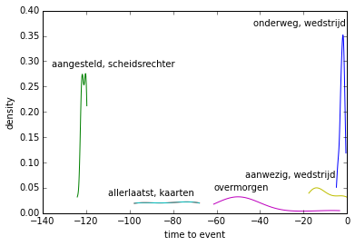

```python
fig, ax = plt.subplots()
featListW = ["onderweg_wedstrijd","aangesteld_scheidsrechter","allerlaatste_kaarten","allerlaatste_kaarten","overmorgen","aanwezig_wedstrijd"]
trainFeatsW.ix[featListW]["TSerie"].apply(lambda x: plt.plot(linspace(min(x),max(x),100), gaussian_kde(x)(linspace(min(x),max(x),100))))
plt.text(-136,.29,r'aangesteld, scheidsrechter')
plt.text(-43,.37,r'onderweg, wedstrijd')
plt.text(-47,.07,r'aanwezig, wedstrijd')
plt.text(-61,.045,r'overmorgen')
plt.text(-110,.035,r'allerlaatst, kaarten')
plt.xlabel('time to event')
plt.ylabel('density')
fig.savefig('WFeatsExamples.eps', format='eps')
```

```
([-140, 0, 0, 0.4],
 None)
```

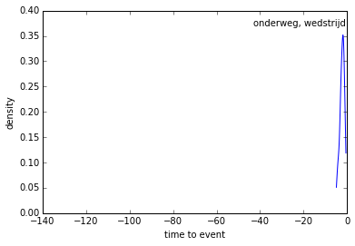

```python
data = trainFeatsW.ix["onderweg_wedstrijd"]["TSerie"] # get the data
kde = gaussian_kde(data) # this create the kernel, given an array it will estimate the probability over that values
dist_space = linspace(min(data), max(data), 100) # these are the values over wich your kernel will be evaluated
plt.plot(dist_space, kde(dist_space)) # plot the results
plt.text(-43,.37,r'onderweg, wedstrijd')
plt.axis([-140, 0, 0, 0.40]), plt.xlabel('time to event'), plt.ylabel('density'), plt.legend()
```

```python
tstResultDFT.columns
```

```
Index(['dt_etime', 'event', 'twID', 'user', 'ttext', 'time_to_event', 'time_to_eventhF', 'ttextlist', 'allFeats', 'featComb', 'medMedEstim', 'medMeaEstim', 'meaMedEstim', 'meaMeaEstim', 'exactTTEmea', 'dynHoursTTEmea', 'dynDaysTTEmea', 'dynMonthsTTEmea', 'rulesMeaEstim', 'medmedOutEstim', 'meameaOut…
```

```python
resultsDFTRWHist2J = tstResultDFT.join(tstResultDFW[["histMed_medMedEstim","medMedEstim", "usedFeats"]], rsuffix='_w')
```

```python
includeColumns = ['ttext', 'time_to_eventhF', 'medMedEstim', 'rulesMeaSerie', 'usedFeats', 'priorityALLEst', 'medMedEstim_w', 'usedFeats_w']
sampleTweets = resultsDFTRWHist2J[(resultsDFTRWHist2J.ttext.str.contains("onderweg naar de galgenwaard voor de wedstrijd fc utrecht feyenoord")) | \
             (resultsDFTRWHist2J.ttext.str.contains("we leven er naar toe de 31ste titel wij zitten er klaar voor #tweaja")) | \
             (resultsDFTRWHist2J.ttext.str.contains("nog 4 uurtje tot de klasieker #feyaja volgen via radio want ik ben @ work")) | \
             (resultsDFTRWHist2J.ttext.str.contains("nu #ajaaz kijken dadelijk #psvutr kijken")) | \
             (resultsDFTRWHist2J.ttext.str.contains("aanstaande zondag naar fc utrecht-afc ajax #utraja \#afcajax")) \
             ][includeColumns]
fcols = ['time_to_eventhF', 'medMedEstim', 'rulesMeaSerie', 'priorityALLEst', 'medMedEstim_w']
sampleTweets[fcols]=sampleTweets[fcols].apply(lambda x: np.abs(np.round(x,2)))
sampleTweets.index = [1,2,3,4,5,6]
sampleTweets['RFeats'] = pd.Series([np.nan,np.nan,'aanstande zondag',np.nan,np.nan,np.nan],index=[1,2,3,4,5,6])
sampleTweets
```

|  | ttext | time_to_eventhF | medMedEstim | rulesMeaSerie | usedFeats | priorityALLEst | medMedEstim_w | usedFeats_w | RFeats |
| --- | --- | --- | --- | --- | --- | --- | --- | --- | --- |
| 1 | nog 4 uurtje tot de klasieker #feyaja volgen via radio want ik ben @ work | 4.05 | 0.86 | NaN | [nog_uurtje, uurtje] | 4.33 | 1.09 | [radio, volgen_radio, uurtje_radio, uurtje] | NaN |
| 2 | we leven er naar toe de 31ste titel wij zitten er klaar voor #tweaja | 1.07 | NaN | NaN | [] | 0.90 | 0.51 | [klaar, zitten_klaar, zitten] | NaN |
| 3 | aanstaande zondag naar fc utrecht-afc ajax #utraja #afcajax | 112.87 | NaN | 115.37 | [] | 115.13 | NaN | [] | aanstande zondag |
| 4 | onderweg naar de galgenwaard voor de wedstrijd fc utrecht feyenoord #utrfey | 2.88 | NaN | NaN | [] | 3.37 | 2.07 | [onderweg, onderweg_wedstrijd] | NaN |
| 5 | nu #ajaaz kijken dadelijk #psvutr kijken | 1.85 | 1.07 | NaN | [nu_dadelijk, dadelijk] | 1.88 | 0.91 | [kijken_dadelijk, dadelijk_kijken, kijken_kijken, dadelijk, kijken] | NaN |
| 6 | nu #ajaaz kijken dadelijk #psvutr kijken | 1.85 | 1.07 | NaN | [nu_dadelijk, dadelijk] | 1.95 | 0.91 | [kijken_dadelijk, dadelijk_kijken, kijken_kijken, dadelijk, kijken] | NaN |

```python
sampleTweets2 = sampleTweets.copy()
sampleTweets2.columns = ['Tweet','TTE','TFeats Est.','Rules Est.','TFeats','Integ. Est.','WFeats Est.','WFeats','RFeats']
#sampleTweets2['Rule Features'] = sampleTweets2['Rule Features'].apply(lambda x: ", ".join(x))
sampleTweets2['TFeats'] = sampleTweets2['TFeats'].apply(lambda x: ", ".join(x))
sampleTweets2['WFeats'] = sampleTweets2['WFeats'].apply(lambda x: ", ".join(x) if type(x)==list else x)
print(sampleTweets2.to_latex(columns=['Tweet','RFeats', 'WFeats','TFeats','TTE','Rules Est.','TFeats Est.','WFeats Est.','Integ. Est.']))
```

```
\begin{tabular}{lllllrrrrr}
\toprule
{} &                                                                        Tweet &            RFeats &                                                             WFeats &                 TFeats &     TTE &  Rules Est. &  TFeats Est. &  WFeats Est. &  Integ. Est. \\
\midrule
1 &    nog 4 uurtje tot de klasieker \#feyaja volgen via radio want ik ben @ work &               NaN &                          radio, volgen\_radio, uurtje\_radio, uurtje &     nog\_uurtje, uurtje &    4.05 &         NaN &         0.86 &         1.09 &         4.33 \\
2 &         we leven er naar toe de 31ste titel wij zitten er klaar voor \#tweaja &               NaN &                                        klaar, zitten\_klaar, zitten &                        &    1.07 &         NaN &          NaN &         0.51 &         0.90 \\
3 &                  aanstaande zondag naar fc utrecht-afc ajax \#utraja \#afcajax &  aanstande zondag &                                                                    &                        &  112.87 &      115.37 &          NaN &          NaN &       115.13 \\
4 &  onderweg naar de galgenwaard voor de wedstrijd fc utrecht feyenoord \#utrfey &               NaN &                                       onderweg, onderweg\_wedstrijd &                        &    2.88 &         NaN &          NaN &         2.07 &         3.37 \\
5 &                                     nu \#ajaaz kijken dadelijk \#psvutr kijken &               NaN &  kijken\_dadelijk, dadelijk\_kijken, kijken\_kijken, dadelijk, kijken &  nu\_dadelijk, dadelijk &    1.85 &         NaN &         1.07 &         0.91 &         1.88 \\
6 &                                     nu \#ajaaz kijken dadelijk \#psvutr kijken &               NaN &  kijken\_dadelijk, dadelijk\_kijken, kijken\_kijken, dadelijk, kijken &  nu\_dadelijk, dadelijk &    1.85 &         NaN &         1.07 &         0.91 &         1.95 \\
\bottomrule
\end{tabular}
```

```python
# find effect of WFeats
q2= resultsDFTRWHist2J.rulesMeaSerie.isnull() & resultsDFTRWHist2J.medMedEstim.isnull() & \
    (resultsDFTRWHist2J.ttext.str.contains('zitten')) & (resultsDFTRWHist2J.ttext.str.contains('klaar'))

excCols= set(['rulesMeaEstim','medMedEstim','usedFeats', 'histMed_rulesTFeatsWFeats','histMea_rulesTFeatsWFeats',\
              'histMed_rulesMeaSerie','dynMonthsTTEmea','allFeats','histMed_meanBase', 'user','histMed_medianBase'])
colsQ2 = list(set(resultsDFTRWHist2J.columns) - excCols)

resultsDFTRWHist2J[q2 & (np.abs(resultsDFTRWHist2J.time_to_eventhF - resultsDFTRWHist2J.medMedEstim_w)>np.abs(resultsDFTRWHist2J.time_to_eventhF - resultsDFTRWHist2J.priorityALLEst))][includeColumns][0:15]#histMed_
```

```python
# find effect of TFeats
q3= resultsDFTRWHist2J.rulesMeaSerie.isnull() & resultsDFTRWHist2J.medMedEstim.notnull() & \
    (resultsDFTRWHist2J.ttext.str.contains('nog')) & (resultsDFTRWHist2J.ttext.str.contains('uur'))
colsQ3 = list(set(resultsDFTRWHist2J.columns) - set(['rulesMeaSerie','medMedEstim_w','usedFeats_w','time_to_eventhF'])) #
resultsDFTRWHist2J[q3 & (np.abs(resultsDFTRWHist2J.time_to_eventhF - resultsDFTRWHist2J.medMedEstim)>np.abs(resultsDFTRWHist2J.time_to_eventhF - resultsDFTRWHist2J.priorityALLEst))][includeColumns] #[0:15]#histMed_
```

|  | ttext | time_to_eventhF | medMedEstim | rulesMeaSerie | usedFeats | priorityALLEst | medMedEstim_w | usedFeats_w |
| --- | --- | --- | --- | --- | --- | --- | --- | --- |
| 2455 | matchday ...! nog een kleine 12 uur #020isdebaasin010 #feyaja #29-31 | -11.875833 | -11.310000 | NaN | [nog_12 uur, 12 uur] | -11.852778 | -3.805694 | [uur, kleine_uur] |
| 2548 | nog een paar uurtjes #snavelsgaaneraan #feyaja #feyenoord | -10.821389 | -5.105556 | NaN | [nog een paar uurtjes] | -13.321389 | -4.017222 | [paar_uurtjes, paar, uurtjes] |
| 2550 | knooppunt zonzeel breda nog een paar kilometertjes nog een paar uurtjes #feyaja #jodenjankdag | -10.796667 | -5.105556 | NaN | [nog een paar uurtjes] | -13.296667 | -4.017222 | [paar_uurtjes, knooppunt, paar, uurtjes] |
| 2585 | 2 mooie avondjes gehad nu nog even 5 uurtjes slaap mee pikken en morgen werken #feyaja | -10.199722 | -9.228333 | NaN | [nu_morgen, nu_uurtjes, uurtjes_morgen, morgen, nog even_uurtjes] | -11.038750 | -8.767361 | [gehad_morgen, uurtjes_morgen, uurtjes_slaap, mooie_morgen, morgen, slaap, mooie_gehad, pikken, gehad, uurtjes, gehad_uurtjes, slaap_morgen] |
| 2715 | @pascalredeker zit je ook in de kuip dan morgenmiddag pff nog een dikke drie uur slapen en op tijd zijn voor feyaja #zinin trusten | -6.036944 | -15.375000 | NaN | [morgenmiddag_nog, morgenmiddag_op tijd, nog_drie uur, morgenmiddag, drie uur] | -6.217500 | -12.185556 | [slapen, morgenmiddag_tijd, morgenmiddag_uur, slapen_tijd, tijd, uur, morgenmiddag, zit_uur, dikke_uur] |
| 2804 | nog 6 1 2 uur en dan vieren wij feest in de kuip dan is de overwinning van @feyenoord een feit @fr12live @megafeyenoord @ #feyaja | -4.494444 | -1.931250 | NaN | [nog_2 uur, 2 uur_dan, 2 uur] | -5.511528 | -3.924167 | [feest_kuip, uur_overwinning, uur_feit, uur, uur_kuip, feit, vieren_feest] |
| 2904 | nog 4 uurtje tot de klasieker #feyaja volgen via radio want ik ben @ work | -4.051944 | -0.856528 | NaN | [nog_uurtje, uurtje] | -4.333611 | -1.094236 | [radio, volgen_radio, uurtje_radio, uurtje] |
| 3683 | eerst was het 3 maanden 3 weken 3 dagen nu zijn et nog een kleine 3 uurtjes #feyaja #cantwait | -2.651944 | -5.396528 | NaN | [nu_uurtjes, eerst_uurtjes, maanden_nu, weken_nu] | -5.151944 | -4.006111 | [eerst_kleine, eerst_uurtjes, kleine_uurtjes, uurtjes, eerst_weken, eerst_maanden, eerst] |
| 4531 | @desley_93 nog ruim 1,5 uur en dan gaat het gebeuren #feyaja winnen #djonad is nu 5 -5 gaat mooi gelijk op | -1.541667 | -3.341597 | NaN | [nog_5 uur, 5 uur_nu] | -3.102569 | -2.976597 | [gebeuren_gaat, uur_gelijk, ruim, uur_gebeuren, uur, ruim_uur, uur_gaat] |
| 9766 | nog ongeveer anderhalf uur en dan gaat het beginnen straks naar #azaja retteteket az | -1.394722 | -2.243611 | NaN | [dan_straks, nog_straks, straks] | -1.894722 | -2.076806 | [uur, beginnen, uur_beginnen, gaat_beginnen, gaat_straks, beginnen_straks, uur_straks, straks, uur_gaat] |
| 10945 | supersunday is begonnen nu eerst #vitnec daarna #azaja en #utrpsv en natuurlijk ook nog premier league met #mantot en #arsman #lekkahlekkah | -3.724167 | -1.948611 | NaN | [nu_daarna] | -2.224167 | -3.002778 | [begonnen_daarna, eerst, daarna, eerst_daarna] |
| 10946 | supersunday is begonnen nu eerst #vitnec daarna #azaja en #utrpsv en natuurlijk ook nog premier league met #mantot en #arsman #lekkahlekkah | -3.724167 | -1.948611 | NaN | [nu_daarna] | -2.224167 | -3.002778 | [begonnen_daarna, eerst, daarna, eerst_daarna] |
| 11917 | 19.00 #aztwe kijke 19.30 trainen daarna nog ff half uurtje #heraja kijke #fijnavondje | -0.939167 | -3.600764 | NaN | [daarna_uurtje, uurtje, nog ff_uurtje, 19.30] | -1.939167 | -2.443403 | [daarna_uurtje, uurtje, half, trainen_daarna, daarna_half, trainen, half_uurtje, daarna] |
| 13798 | “ @cheshala1 maar eens gaan slapen matchday #feyaz over een paar uur naar de kuip om 2e plaats te veroveren alleen dat slapen nog niet haha | -11.234167 | -5.727222 | NaN | [over een paar uur] | -11.734167 | -9.712639 | [slapen_paar, gaan_slapen, uur_plaats, slapen, gaan_uur, uur, paar_uur, slapen_uur, paar_kuip, uur_kuip, veroveren] |
| 14116 | nog zo'n kleine 3 uurtjes en dan richting de kuip voor misschien wel de belangrijkste wedstrijd van het seizoen #feyenoordrotterdam #feyaz | -4.996111 | -6.535833 | NaN | [zo_uurtjes, uurtjes_dan] | -5.496111 | -3.329583 | [richting_kuip, kuip_wedstrijd, uurtjes_richting, kleine_uurtjes, kuip_seizoen, kleine_wedstrijd, richting_seizoen, richting, uurtjes, richting_wedstrijd, uurtjes_kuip] |
| 15614 | nog minder dan 48 uur en dan het #nog3wedstrijdenfilmpje alleen steve is er niet zo blij mee ;-) #tweaja #ajax http://t.co/jhzodnqa | -91.515833 | -8.891667 | NaN | [48 uur] | -92.015833 | -3.096944 | [uur, minder_uur] |
| 16158 | “ @ajaxfanzonenl is #ajaxkampioen nog steeds niet trending topic oh wacht dat is morgen natuurlijk pas #tweaja #ajax ” true story | -14.888056 | -17.360972 | NaN | [nog steeds_morgen, morgen] | -17.239028 | -20.967778 | [steeds_morgen, topic_pas, topic_morgen, morgen, wacht_morgen] |
| 17177 | bussie leiden #paling #zalm #bier #mixjes en het moet nog twaalf uur worden #nmnh #tweaja | -2.758333 | -11.617222 | NaN | [twaalf uur] | -3.258333 | -3.965833 | [uur, bier_uur, bier] |
| 19098 | matchday nog een paar uurtjes en dan naar de kuip daar hebben we dus wel zin in op naar een goed resultaat tegen utrecht #feyutr #dhig | -5.602778 | -4.955139 | NaN | [nog een paar uurtjes_dan, nog een paar uurtjes] | -6.102778 | -5.301250 | [paar_goed, paar_zin, paar_uurtjes, kuip_resultaat, uurtjes_zin, paar_kuip, uurtjes_kuip, uurtjes_goed, uurtjes, kuip_goed] |
| 19288 | zo nog ff een uur aan de studie en dan naar een zonovergoten kuip #feyutr http://t.co/8z7ofbyw | -3.366667 | -1.688750 | NaN | [een uur, een uur_dan] | -3.866667 | -3.969167 | [uur_kuip, uur, zonovergoten] |
| 20269 | #f1 gehad nog een paar uurtjes en dan begint weer een mooie voetbalmiddag #adoaja #psvhee #twefey | -5.686389 | -4.981667 | NaN | [nog een paar uurtjes_weer, nog een paar uurtjes_dan, nog een paar uurtjes] | -6.186389 | -3.623403 | [begint_mooie, uurtjes_mooie, voetbalmiddag, paar_begint, paar_weer, begint, gehad_weer, gehad_mooie, paar_uurtjes, gehad, paar_mooie, weer_mooie, gehad_paar, uurtjes_weer, uurtjes, weer_voetbalmiddag… |
| 21968 | nog even 2 uurtjes bikkelen hier op het werk en lekker weekend hopelijk stem wat rust geven oh nee #psvfey dat wordt weer 10 x juichen | -46.874167 | -8.693194 | NaN | [nog even_uurtjes, nog even_weekend, uurtjes_weer] | -47.374167 | -4.014444 | [bikkelen, uurtjes_lekker, lekker_juichen, uurtjes_hopelijk, uurtjes_weer, lekker_rust, uurtjes, lekker_weekend, uurtjes_weekend, lekker_hopelijk, werk_lekker] |
| 22338 | nog een paar uurtjes #psvfey #matchday | -14.328889 | -4.981667 | NaN | [nog een paar uurtjes] | -15.832639 | -5.004028 | [uurtjes, paar_uurtjes] |
| 22452 | zo nog ff paar uur silence is golden op p 5 en dan #feyenoord en dagje vrij #psvfey | -7.190833 | -3.651667 | NaN | [zo_dagje] | -7.690833 | -5.394722 | [uur, golden, dagje, paar_uur] |
| 23518 | half uurtje nog werkdag zit er weer bijna op en dan heeeel snel naar eindhoven #psvfey | -1.591389 | -1.178472 | NaN | [uurtje_weer, uurtje_dan, uurtje, uurtje_nog] | -1.977778 | -1.952222 | [uurtje_weer, half_uurtje, werkdag_zit, uurtje, half, werkdag, half_zit, uurtje_zit, half_weer, zit_weer, werkdag_weer] |
| 26969 | chadli ik heb nu een uur gespeeld en heb nog drie dagen om me voor te bereiden op een volledige wedstrijd http://t.co/gb4zhruj #psvtwe | -55.745278 | -38.170972 | NaN | [een uur, nog drie dagen] | -54.245278 | -4.655000 | [uur_dagen, uur_wedstrijd, uur, bereiden_wedstrijd, dagen_wedstrijd, uur_bereiden] |
| 27399 | nog 6 uurtjes dann #psvtwe | -5.988889 | -9.471944 | NaN | [nog 6 uurtjes] | -4.488889 | -4.005417 | [uurtjes] |
| 28405 | nog één daggie lees negentien uur werken en dan weekend weinig heel weinig doen naast #ajatwe | -92.974167 | -46.742778 | NaN | [uur_weekend] | -87.224167 | -4.779722 | [uur, één_uur, uur_weekend, één] |
| 29018 | nog 12 uurtjes #ajatwe | -11.998333 | -12.066250 | NaN | [nog 12 uurtjes] | -11.988611 | -3.993611 | [uurtjes] |
| 29511 | nog uurtje werken en dan naar ajax twente #comeontwente #ajatwe | -5.892500 | -1.116250 | NaN | [uurtje, uurtje_dan, nog_uurtje] | -5.142500 | -1.003333 | [uurtje] |
| ... | ... | ... | ... | ... | ... | ... | ... | ... |
| 106642 | nog vijf uur dan staat #ajax zes punten voor op #psv #psvaja ” | -3.230833 | -4.839861 | NaN | [nog_vijf uur] | -4.818472 | -4.077500 | [uur_punten, uur, uur_staat] |
| 106660 | @shhaaroon @ ajax 1 nl nog vijf uur dan staat #ajax zes punten voor op #psv #psvaja | -3.171944 | -4.839861 | NaN | [nog_vijf uur] | -4.760417 | -4.077500 | [uur_punten, uur, uur_staat] |
| 106662 | nog vijf uur dan staat #ajax zes punten voor op #psv #psvaja | -3.167778 | -4.839861 | NaN | [nog_vijf uur] | -4.776806 | -4.077500 | [uur_punten, uur, uur_staat] |
| 106664 | nog vijf uur dan staat #ajax zes punten voor op #psv #psvaja | -3.164444 | -4.839861 | NaN | [nog_vijf uur] | -4.773472 | -4.077500 | [uur_punten, uur, uur_staat] |
| 106669 | nog vijf uur dan staat #ajax zes punten voor op #psv #psvaja | -3.148889 | -4.839861 | NaN | [nog_vijf uur] | -4.820972 | -4.077500 | [uur_punten, uur, uur_staat] |
| 106674 | @ajax1nl nog vijf uur dan staat #ajax zes punten voor op #psv #psvaja | -3.130556 | -4.839861 | NaN | [nog_vijf uur] | -4.805972 | -4.077500 | [uur_punten, uur, uur_staat] |
| 106677 | nog vijf uur dan staat #ajax zes punten voor op #psv #psvaja | -3.123889 | -4.839861 | NaN | [nog_vijf uur] | -4.814861 | -4.077500 | [uur_punten, uur, uur_staat] |
| 106694 | nog vijf uur dan staat #ajax zes punten voor op #psv #psvaja | -3.071389 | -4.839861 | NaN | [nog_vijf uur] | -4.804583 | -4.077500 | [uur_punten, uur, uur_staat] |
| 106696 | “ @ajax1nl nog vijf uur dan staat #ajax zes punten voor op #psv #psvaja ” lol | -3.063056 | -4.839861 | NaN | [nog_vijf uur] | -4.831528 | -3.436111 | [uur_staat, uur_punten, uur, uur_lol, staat_lol] |
| 106793 | @ajax1nl nog vijf uur dan staat #ajax zes punten voor op #psv #psvaja @timbloetjes | -2.795000 | -4.839861 | NaN | [nog_vijf uur] | -3.751389 | -4.077500 | [uur_punten, uur, uur_staat] |
| 106811 | rt “ @ajax1nl nog vijf uur dan staat #ajax zes punten voor op #psv #psvaja ” | -2.754167 | -4.839861 | NaN | [nog_vijf uur] | -4.799028 | -4.077500 | [uur_punten, uur, uur_staat] |
| 106961 | café #laroute is nu een uur open nog 2,5 tot kick off #psv #psvaja #psvforlife | -2.412500 | -2.126389 | NaN | [een uur, een uur_nog] | -2.477778 | -1.993889 | [café, uur, café_uur] |
| 106980 | nu nog 2 en een half uur wachtten #psvaja | -2.390000 | -1.725972 | NaN | [nu_uur] | -2.390000 | -2.016111 | [uur, half, half_uur] |
| 107184 | nog twee uur #psvaja | -2.030000 | -1.984028 | NaN | [twee uur, nog_twee uur] | -2.070556 | -4.077500 | [uur] |
| 107188 | @ajax1nl nog vijf uur dan staat #ajax zes punten voor op #psv #psvaja | -2.026667 | -4.839861 | NaN | [nog_vijf uur] | -2.495347 | -4.077500 | [uur_punten, uur, uur_staat] |
| 107399 | “ @ajax1nl nog vijf uur dan staat #ajax zes punten voor op #psv #psvaja ” | -1.728889 | -4.839861 | NaN | [nog_vijf uur] | -4.228889 | -4.077500 | [uur_punten, uur, uur_staat] |
| 107817 | nog iets meer dan een klein uurtje en mensen liggen nog steeds stil maar goed #psvaja | -1.213889 | -4.947639 | NaN | [nog_nog steeds, dan_nog steeds, een klein uurtje] | -3.713889 | -2.376250 | [uurtje_liggen, uurtje, uurtje_mensen, uurtje_goed, mensen_goed, mensen_steeds] |
| 107980 | nog uurtje tot #psvaja | -1.014444 | -0.862708 | NaN | [uurtje, nog_uurtje] | -1.133889 | -1.004444 | [uurtje] |
| 108146 | “ @ajax1nl nog vijf uur dan staat #ajax zes punten voor op #psv #psvaja ” denk het ook niet :p | -0.867222 | -4.839861 | NaN | [nog_vijf uur] | -2.061111 | -4.077500 | [punten_denk, uur_punten, uur, uur_denk, uur_staat] |
| 108650 | nog maar n half uurtje #psvaja | -0.464444 | -0.862708 | NaN | [uurtje, nog_uurtje] | -0.485278 | -1.004444 | [half, uurtje, half_uurtje] |
| 110797 | @lauvoort ik geniet nog even van een weekendje in het heijderbos maar volg nu natuurlijk even de wedstrijd #azpsv | -0.027778 | -5.434236 | NaN | [nog even_nu, weekendje_nu] | -1.776389 | -0.610278 | [geniet_wedstrijd, volg_wedstrijd, weekendje] |
| 111160 | nog uurtje werken dan lekker naar huis snel boodschappen doen dan #tweaz kijken op @eredivisielive | -3.488333 | -1.216944 | NaN | [nog_uurtje, uurtje, uurtje_dan] | -4.738333 | -2.105556 | [uurtje_huis, boodschappen_kijken, lekker_kijken, kijken, lekker_boodschappen, uurtje_lekker, uurtje, uurtje_kijken, boodschappen, huis_kijken] |
| 112338 | nog 68 uur en 37 min en dan is het eindelijk zover feyenoord psv #feypsv | -68.589167 | -7.522222 | NaN | [uur_eindelijk] | -71.089167 | -3.963611 | [zover, uur_zover, uur] |
| 112865 | #feyenoordpsv #eredivisielive nog zo'n 15 uur en dan de wedstrijd van het weekend heb er zin in :) #feypsv #moeteneringelovenkunnenwinnen | -15.125000 | -8.715972 | NaN | [15 uur_dan, nog_15 uur, 15 uur] | -17.167639 | -3.971944 | [uur_weekend, wedstrijd_zin, uur_zin, uur, uur_wedstrijd] |
| 112900 | #wwe12 gedaan nu in bed slapen nog een paar uurtjes tot #feypsv | -13.876944 | -4.836250 | NaN | [nog een paar uurtjes] | -16.376944 | -9.220556 | [slapen, gedaan_bed, slapen_paar, slapen_uurtjes, bed, paar_uurtjes, bed_slapen, uurtjes, bed_uurtjes, bed_paar] |
| 113158 | morge kuiper nog een paar uurtjes daar werd ík mee wakker kan een mens dan nog slapen #feypsv @ feyen_headlinez @feyenoord | -5.434722 | -4.882431 | NaN | [nog een paar uurtjes, nog een paar uurtjes_dan] | -5.523333 | -5.993611 | [paar_uurtjes, uurtjes_slapen, mens, slapen, uurtjes] |
| 113513 | en bijna wakker nog drie uurtjes #feypsv | -2.975833 | -2.971111 | NaN | [nog drie uurtjes] | -2.975833 | -4.015833 | [uurtjes] |
| 116680 | @megafeyenoord dat twente nog gekomen is ze verliezen toch had ze een bustrip van 2 uur bespaard #feytwe | -7.389722 | -3.420833 | NaN | [van 2 uur] | -5.356944 | -3.968333 | [uur] |
| 117647 | beetje saaie wedstrijd #ajaado het vuurwerk van de middag moet nog komen #feytwe #katinutbakkie | -0.827222 | -2.000417 | NaN | [van de middag] | -1.327222 | -0.673611 | [beetje_middag, wedstrijd_middag, beetje_vuurwerk, middag, saaie_wedstrijd, vuurwerk, wedstrijd_vuurwerk] |
| 118364 | yeah matchday maar eerst nog een paar uurtjes pitten zo #utraja | -12.227500 | -4.456181 | NaN | [nog een paar uurtjes_zo, nog een paar uurtjes] | -14.727500 | -10.225278 | [eerst_uurtjes, pitten, eerst_paar, eerst_pitten, uurtjes, paar_pitten, uurtjes_pitten, paar_uurtjes, eerst] |

233 rows × 8 columns

```python
# find effect of TFeats
q4= resultsDFTRWHist2J.rulesMeaSerie.notnull()  & resultsDFTRWHist2J.medMedEstim_trw.isnull() & resultsDFTRWHist2J.medMedEstim_w.isnull()
colsQ4 = list(set(resultsDFTRWHist2J.columns) - set(['medMedEstim_trw','medMedEstim_w','usedFeats_w','usedFeats_trw','time_to_eventhF'])) #
resultsDFTRWHist2J[q4 & (np.abs(resultsDFTRWHist2J.time_to_eventhF - resultsDFTRWHist2J.rulesMeaSerie)<3)][includeColumns][0:15]#histMed_
```

|  | featComb | rulesTFeatsWFeats | histMed_medMedEstim | histMed_rulesTFeatsWFeats | ttext | rulesMeaSerie |
| --- | --- | --- | --- | --- | --- | --- |
| 120 | [woensdagavond] | -76.971667 | NaN | -39.236111 | @danielle0572 hahaha :) ik kan niet wachten tot woensdagavond :) #ajafey | -76.971667 |
| 182 | [al, zondag, al_zondag] | -148.349167 | NaN | -135.175556 | heey @leboeuf71 zit je al te zweten voor zondag #zondaggehaktdag #utraja #utrproat | -148.349167 |
| 223 | [nog, woensdagavond, nog_woensdagavond] | -49.709444 | NaN | -44.709444 | @leongoedegebuur moet ik nog kaartjes kopen bij je voor woensdagavond #ajafey | -49.709444 |
| 244 | [over 2 dagen, nog, over 2 dagen_nog] | -48.000000 | NaN | -41.923611 | over 2 dagen #ajafey kan niet wachten maar er kan nog van alles gebeuren op de transfermarkt afwachten maar #ajax | -48.000000 |
| 428 | [1 dag, dan, nog, 1 dag_dan, 1 dag_nog, dan_nog] | -24.000000 | NaN | -20.672778 | respectloos van #beenhakker om de vuile was 1 dag voor #ajafey buiten te hangen en dan blijkt het ook nog eens niet waar te zijn #wrok | -24.000000 |
| 452 | [aanstaande zondag] | -115.373333 | NaN | -4.349236 | aanstaande zondag naar fc utrecht-afc ajax #utraja #afcajax | -115.373333 |
| 660 | [woensdagavond] | -11.838056 | NaN | -7.726528 | zin in de klassieker alhoewel dit is geen klassieker meer woensdagavond de toestand bij 010 #ajafey | -11.838056 |
| 736 | [al, 20:45, al_20:45] | -11.756389 | NaN | -11.006389 | is het al 20:45 #ajafey | -11.756389 |
| 1546 | [al, 20:45, al_20:45] | -5.096944 | NaN | -4.346944 | is het al 20:45 #ajafey | -5.096944 |
| 1614 | [20:45] | -4.771944 | NaN | -4.021944 | @tijnborm aight thnx als het maar voor 20:45 is #ajafey | -4.771944 |
| 3148 | [nog 3 kwartier] | -0.750000 | NaN | -1.090944 | nog 3 kwartier #ajafey | -0.750000 |
| 3173 | [nog 3 kwartier, nog 3 kwartier, nog 3 kwartier_nog 3 kwartier] | -0.766667 | NaN | -0.755278 | nog 3 kwartier ik herhaal nog 3 kwartier #ajafey | -0.766667 |
| 3242 | [om 20:45] | -0.647778 | NaN | -0.998194 | strax bij #eredivisielive om 20:45 #ajax #feyenoord wat gaat het worden #ajafey | -0.647778 |
| 3556 | [nog een kwartier] | -0.300000 | NaN | -1.350931 | nog een kwartier #ajafey kom op feyenoord do your thing | -0.300000 |
| 3579 | [nog een kwartier] | -0.300000 | NaN | -2.498750 | nog een kwartier #ajafey #aftellen | -0.300000 |

```python
sampleTweets = resultsDFTRWHist2J.ix[[12472,3793,50011,46442,452]][['ttext', 'time_to_eventhF', 'medMedEstim_trw', 'rulesMeaSerie', 'usedFeats_trw', 'rulesTFeatsWFeats', 'histMed_rulesTFeatsWFeats', 'featComb', 'medMedEstim_w', 'usedFeats_w']].copy()
fcols = ['time_to_eventhF', 'medMedEstim_trw', 'rulesMeaSerie', 'rulesTFeatsWFeats', 'histMed_rulesTFeatsWFeats', 'medMedEstim_w']
sampleTweets[fcols]=sampleTweets[fcols].apply(lambda x: np.abs(np.round(x,2)))
sampleTweets.index = [1,2,3,4,5]
sampleTweets
```

[output not shown]

```python
sampleTweets2 = sampleTweets.copy()
sampleTweets2.columns = ['Tweet','TTE','TFeats Est.','Rules Est.','TFeats','Comb. Est.','Hist. Est.','Rule Features','WFeats Est.','WFeats']
sampleTweets2['Rule Features'] = sampleTweets2['Rule Features'].apply(lambda x: ", ".join(x))
sampleTweets2['TFeats'] = sampleTweets2['TFeats'].apply(lambda x: ", ".join(x))
sampleTweets2['WFeats'] = sampleTweets2['WFeats'].apply(lambda x: ", ".join(x) if type(x)==list else x)
print(sampleTweets2.to_latex(columns=['Tweet','Rule Features', 'WFeats','TFeats','TTE','Rules Est.','TFeats Est.','WFeats Est.','Comb. Est.','Hist. Est.']))
```

```python
sampleTweets2 = sampleTweets.copy()
sampleTweets2.columns = ['Tweet','TTE','TFeats Est.','Rules Est.','TFeats','Comb. Est.','Hist. Est.','Rule Features','WFeats Est.','WFeats']
sampleTweets2['Rule Features'] = sampleTweets2['Rule Features'].apply(lambda x: ", ".join(x))
sampleTweets2['TFeats'] = sampleTweets2['TFeats'].apply(lambda x: ", ".join(x))
sampleTweets2['WFeats'] = sampleTweets2['WFeats'].apply(lambda x: ", ".join(x) if type(x)==list else x)
print(sampleTweets2.to_latex(columns=['Tweet','Rule Features', 'WFeats','TFeats','TTE','Rules Est.','TFeats Est.','WFeats Est.','Comb. Est.','Hist. Est.']))
```

```
\begin{tabular}{lllllrrrrrr}
\toprule
{} &                                                                        Tweet &                Rule Features &                                                             WFeats &                  TFeats &     TTE &  Rules Est. &  TFeats Est. &  WFeats Est. &  Comb. Est. &  Hist. Est. \\
\midrule
1 &  onderweg naar de galgenwaard voor de wedstrijd fc utrecht feyenoord \#utrfey &            voor de wedstrijd &                                       onderweg, onderweg\_wedstrijd &                         &    2.88 &         NaN &          NaN &         2.07 &        2.07 &        3.18 \\
2 &                      wij zitten er klaar voor \#ajafey op de beamer at \#loods &                              &                         zitten\_klaar, zitten, beamer, loods, klaar &                         &    0.10 &         NaN &          NaN &         0.70 &        0.82 &        1.94 \\
3 &                                              nog een kleine twee uur \#ajafey &  nog, twee uur, nog\_twee uur &                                                    kleine\_uur, uur &  twee uur, nog\_twee uur &    1.87 &         NaN &         2.01 &         3.84 &        2.01 &        2.08 \\
4 &                                     nu \#ajaaz kijken dadelijk \#psvutr kijken &    nu, dadelijk, nu\_dadelijk &  kijken\_dadelijk, kijken\_kijken, kijken, dadelijk, dadelijk\_kijken &   dadelijk, nu\_dadelijk &    1.85 &         NaN &         1.07 &         0.91 &        1.07 &        1.83 \\
5 &                  aanstaande zondag naar fc utrecht-afc ajax \#utraja \#afcajax &            aanstaande zondag &                                                                NaN &                         &  112.87 &      115.37 &          NaN &          NaN &      115.37 &        4.35 \\
\bottomrule
\end{tabular}
```

```python
resultsDFWHist = tstResultDFW.groupby("event").apply(calcExpandHistNorm, "medMedEstim", 15)

resultsDFWHist.reset_index(drop=True, level=0, inplace=True)
tstResultDFW = tstResultDFW.join(resultsDFWHist.histMed_medMedEstim,how='left')

fm_resultsDict["WFeats"]["MAE"] = getMAE(resultsDFWHist.time_to_eventhF,resultsDFWHist.histMed_medMedEstim)
fm_resultsDict["WFeats"]["RMSE"] = getRMSE(resultsDFWHist.time_to_eventhF,resultsDFWHist.histMed_medMedEstim)
fm_resultsDict["WFeats"]["Coverage"] = resultsDFWHist.histMed_medMedEstim.count()/len(tstResultDFW)
fm_resultsDict["WFeats"]["NRMSE"] = fm_resultsDict["WFeats"]["RMSE"]/192
fm_resultsDict["WFeats"]
```

```
{'MAE': 13.981299380495505,
 'NRMSE': 0.18516406944144284,
 'Coverage': 0.82467543206813865,
 'RMSE': 35.551501332757027}
```

```python
experimentT = extractFeats(experiment, use_wlistT)
print(len(experimentT))
```

```python
#experimentT.to_pickle(time.strftime("%Y%m%d-%H%M")+"-experimentT")
```

```python
tstResultDFT_noElimRules = run_loo_experimentP(experimentT, lComb=2, stdThresh=0.75,throcc=1, excambtmp=True, elimRulesFromTrain=False) # run it with optimized parameters
tstResultDFT.to_pickle(time.strftime("%Y%m%d-%H%M")+"-testTFeatsFLen2Qnt85ExcTmpTrElimRulesTr_noElimRules")
#tstResultDFT = pd.read_pickle("??-testTFeatsFLen2Qnt85ExcTmpTrElimRulesTr") # it should be a new one! Domain terms deleted!
```

```
  26/26 tasks finished after  975 s
done
```

```python
# number of occurred time expressions in FM!
matchedTmxSet = set()
for aF in tstResultDFT.allFeats:
    matchedTmxSet.update(aF)
for aF in resultsDFTRDev:
    matchedTmxSet.update(aF)
len(matchedTmxSet)
```

```python
trainFeatsT = getTrainFeatures(tstResultDFT, thresQuantile=0.75, thresOcc=1, excAmbTemp=True)
```

```
len features 1: 17694
len features 2: 6330
len features 3,std, medAD: 4550 4470
```

```python
featTSerieLen = trainFeatsT.TSerie.apply(lambda x: len(x))
featTSerieStd = trainFeatsT.TSerie.apply(lambda x: x.std())
trainFeatsT[(featTSerieLen>6) & (trainFeatsT.medianTTE<-5) & (trainFeatsT.medianTTE>-10)][0:30]#[150:180]#[32:53] #
```

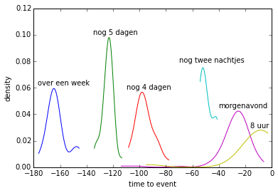

```python
fig, ax = plt.subplots()
featListT = ["over een week","nog 5 dagen","nog 4 dagen","nog twee nachtjes",'morgenavond','8 uur'] #,"allerlaatste_kaarten","allerlaatste_kaarten","overmorgen","aanwezig_wedstrijd"]
trainFeatsT.ix[featListT]["TSerie"].apply(lambda x: plt.plot(linspace(min(x),max(x),100), gaussian_kde(x)(linspace(min(x),max(x),100))))
plt.text(-177,.062,r'over een week')
plt.text(-135,.1,r'nog 5 dagen')
plt.text(-110,.059,r'nog 4 dagen')
plt.text(-70,.079,r'nog twee nachtjes')
plt.text(-40,.045,r'morgenavond')
plt.text(-16,.030,r'8 uur')
plt.xlabel('time to event')
plt.ylabel('density')
ax.set_ylim([0,0.12])
fig.savefig('TFeatsExamples.eps', format='eps')
```

```python
tstResultDFT = tstResultDFT_noElimRules.copy()
```

```python
# corrected azfey_f11 and allow 1 tıme of occurrence for each feature
lenres = len(tstResultDFT)
print("Exact rule MAE:", getMAE(tstResultDFT.time_to_eventhF, tstResultDFT.exactTTEmea), tstResultDFT.exactTTEmea.count()/lenres)
print("Dynamic Hours MAE:", getMAE(tstResultDFT.time_to_eventhF, tstResultDFT.dynHoursTTEmea), tstResultDFT.dynHoursTTEmea.count()/lenres)
print("Dynamic Days MAE:", getMAE(tstResultDFT.time_to_eventhF, tstResultDFT.dynDaysTTEmea), tstResultDFT.dynDaysTTEmea.count()/lenres)
print("Dynamic Months MAE",getMAE(tstResultDFT.time_to_eventhF, tstResultDFT.dynMonthsTTEmea), tstResultDFT.dynMonthsTTEmea.count()/lenres)
print("Median Training & Estimation MAE:", getMAE(tstResultDFT.time_to_eventhF, tstResultDFT.medMedEstim), tstResultDFT.medMedEstim.count()/lenres)

tstResultDFT["rulesMeaSerie"] = tstResultDFT[["dynDaysTTEmea","dynHoursTTEmea","dynMonthsTTEmea","exactTTEmea"]].apply(np.mean,1)
print("Mean of Rules combination MAE:",getMAE(tstResultDFT.time_to_eventhF, tstResultDFT.rulesMeaSerie), tstResultDFT.rulesMeaSerie.count()/lenres)

tstResultDFT["rulesMeaSerie2"] = tstResultDFT[["dynDaysTTEmea","dynHoursTTEmea","dynMonthsTTEmea","exactTTEmea","medMedEstim"]].apply(np.mean,1)
print("Mean of Rules combination MAE2:",getMAE(tstResultDFT.time_to_eventhF, tstResultDFT.rulesMeaSerie2), tstResultDFT.rulesMeaSerie2.count()/lenres)

tstResultDFT["rulesAndTrain"] = np.where(tstResultDFT.rulesMeaSerie.notnull(),tstResultDFT.rulesMeaSerie,tstResultDFT.medMedEstim)
print("Mean rule and Temporal exp. train combination MAE:",getMAE(tstResultDFT.time_to_eventhF, tstResultDFT.rulesAndTrain), tstResultDFT.rulesAndTrain.count()/lenres)
```

```
Exact rule MAE: 6.93622648699 0.0473662449351
Dynamic Hours MAE: 6.81617675015 0.173993219218
Dynamic Days MAE: 8.83165708812 0.0604316546763
Dynamic Months MAE 10.512345679 0.0013396179608
Median Training & Estimation MAE: 7.53507149758 0.315496568263
Mean of Rules combination MAE: 6.49997943036 0.273240717771
Mean of Rules combination MAE2: 6.79052799094 0.405945588357
Mean rule and Temporal exp. train combination MAE: 6.58678478145 0.405945588357
```

```python
tstResultDFT["rulesTFeatsWFeats"] = np.where(tstResultDFT.rulesAndTrain.notnull(),tstResultDFT.rulesAndTrain,tstResultDFW.medMedEstim)
print("MAE:",getMAE(tstResultDFT.time_to_eventhF,tstResultDFT.rulesTFeatsWFeats), \
      "RMSE:",getRMSE(tstResultDFT.time_to_eventhF,tstResultDFT.rulesTFeatsWFeats))
```

```
MAE: 10.3676453696 RMSE: 28.9999067113
```

```python
# get the rules History function. Rules will be adjusted just according the history of rules etc.
# This is the priority based history integration!
winLen = 15
rulesHistDF = tstResultDFT.groupby("event").apply(calcExpandHistNorm, "rulesMeaSerie", winLen)
rulesTmxHistDF = tstResultDFT.groupby("event").apply(calcExpandHistNorm, "rulesAndTrain", winLen)
rulesTmxLexHistDF = tstResultDFT.groupby("event").apply(calcExpandHistNorm, "rulesTFeatsWFeats", winLen)

print('#Winlen:',winLen,'MAE:',getMAE(rulesHistDF.time_to_eventhF,rulesHistDF.histMed_rulesMeaSerie),\
      'RMSE',getRMSE(rulesHistDF.time_to_eventhF,rulesHistDF.histMed_rulesMeaSerie))

print('#Winlen:',winLen,'MAE:',getMAE(rulesTmxHistDF.time_to_eventhF,rulesTmxHistDF.histMed_rulesAndTrain),\
      'RMSE',getRMSE(rulesTmxHistDF.time_to_eventhF,rulesTmxHistDF.histMed_rulesAndTrain))

print('#Winlen:',winLen,'MAE:',getMAE(rulesTmxLexHistDF.time_to_eventhF,rulesTmxLexHistDF.histMed_rulesTFeatsWFeats),\
      'RMSE',getRMSE(rulesTmxLexHistDF.time_to_eventhF,rulesTmxLexHistDF.histMed_rulesTFeatsWFeats))

rulesHistDF.reset_index(drop=True, level=0, inplace=True)#.set_index("twID").head(1)
rulesTmxHistDF.reset_index(drop=True, level=0, inplace=True)#.set_index("twID").head(1)
rulesTmxLexHistDF.reset_index(drop=True, level=0, inplace=True)#.set_index("twID").head(1)

try:
    tstResultDFT=tstResultDFT.join(rulesHistDF.histMed_rulesMeaSerie,how='left')
    tstResultDFT=tstResultDFT.join(rulesTmxHistDF.histMed_rulesAndTrain,how='left')
    tstResultDFT=tstResultDFT.join(rulesTmxLexHistDF.histMed_rulesTFeatsWFeats,how='left')
    print('new column joined')
except:
    tstResultDFT.update(rulesHistDF.histMed_rulesMeaSerie,join='left')
    tstResultDFT.update(rulesTmxHistDF.histMed_rulesAndTrain,join='left')
    tstResultDFT.update(rulesTmxLexHistDF.histMed_rulesTFeatsWFeats,join='left')
    print("columns updated")
# before azfey_f11 correction, and duplicate feature deletion in a tweet
#Winlen: 15 MAE: 3.48129380523 RMSE 14.9201494548
#Winlen: 15 MAE: 3.4280577133 RMSE 14.6595261405
#Winlen: 15 MAE: 8.02547082993 RMSE 25.2867076235
```

```
#Winlen: 15 MAE: 3.42113182671 RMSE 14.7801517744
#Winlen: 15 MAE: 3.37944327264 RMSE 14.5461502491
#Winlen: 15 MAE: 7.95759153403 RMSE 25.1438633428
new column joined
```

```python
tstResultDFT["priorityALLEst"] = np.where(tstResultDFT.histMed_rulesMeaSerie.notnull(), tstResultDFT.histMed_rulesMeaSerie, \
             np.where(tstResultDFT.medMedEstim.notnull(), tstResultDFT.histMed_rulesAndTrain,tstResultDFT.histMed_rulesTFeatsWFeats))
getMAE(tstResultDFT.time_to_eventhF,tstResultDFT.priorityALLEst), getRMSE(tstResultDFT.time_to_eventhF,tstResultDFT.priorityALLEst)
```

```
(5.952426100457731, 21.624782841649939)
```

```python
fm_resultsDict["Rules"]["MAE"] = getMAE(tstResultDFT.time_to_eventhF,tstResultDFT.histMed_rulesMeaSerie)
fm_resultsDict["Rules"]["RMSE"] = getRMSE(tstResultDFT.time_to_eventhF,tstResultDFT.histMed_rulesMeaSerie)
fm_resultsDict["Rules"]["Coverage"] = tstResultDFT.histMed_rulesMeaSerie.count()/len(tstResultDFT)
fm_resultsDict["Rules"]["NRMSE"] = fm_resultsDict["Rules"]["RMSE"]/192
fm_resultsDict["Rules"]
```

```
{'MAE': 3.4211318267108064,
 'NRMSE': 0.07697995715816118,
 'Coverage': 0.27281898619035805,
 'RMSE': 14.780151774366946}
```

```python
tstResultDFTHist = tstResultDFT.groupby("event").apply(calcExpandHistNorm, "medMedEstim", winLen)

tstResultDFTHist.reset_index(drop=True, level=0, inplace=True)
tstResultDFT=tstResultDFT.join(tstResultDFTHist.histMed_medMedEstim,how='left')

fm_resultsDict["TFeats"]["MAE"] = getMAE(tstResultDFTHist.time_to_eventhF,tstResultDFTHist.histMed_medMedEstim)
fm_resultsDict["TFeats"]["RMSE"] = getRMSE(tstResultDFTHist.time_to_eventhF,tstResultDFTHist.histMed_medMedEstim)
fm_resultsDict["TFeats"]["Coverage"] = tstResultDFTHist.histMed_medMedEstim.count()/len(tstResultDFT)
fm_resultsDict["TFeats"]["NRMSE"] = fm_resultsDict["TFeats"]["RMSE"]/192
fm_resultsDict["TFeats"]
```

```
{'MAE': 7.5271674988627018,
 'NRMSE': 0.12703907937092715,
 'Coverage': 0.31507483668237823,
 'RMSE': 24.391503239218014}
```

```python
fm_resultsDict["Combination"]["MAE"] = getMAE(tstResultDFT.time_to_eventhF,tstResultDFT.priorityALLEst)
fm_resultsDict["Combination"]["RMSE"] = getRMSE(tstResultDFT.time_to_eventhF,tstResultDFT.priorityALLEst)
fm_resultsDict["Combination"]["Coverage"] = tstResultDFT.priorityALLEst.count()/len(tstResultDFT)
fm_resultsDict["Combination"]["NRMSE"] = fm_resultsDict["Combination"]["RMSE"]/192
fm_resultsDict["Combination"]
```

```
{'MAE': 5.952426100457731,
 'NRMSE': 0.1126290773002601,
 'Coverage': 0.84628297362110316,
 'RMSE': 21.624782841649939}
```

```python
IFeatsResPerEvent = tstResultDFT.groupby("event").apply(lambda g:pd.Series({"MAE":getMAE(g.time_to_eventhF,g.priorityALLEst),"RMSE":getRMSE(g.time_to_eventhF,g.priorityALLEst), "twCount":len(g)}))
IFeatsResPerEvent.sort("MAE")
```

| event | MAE | RMSE | twCount |
| --- | --- | --- | --- |
| utrtwe_s11 | 1.030570 | 2.313143 | 688 |
| feyutr_s12 | 1.353806 | 4.613626 | 949 |
| twefey_f12 | 1.713681 | 6.094307 | 1824 |
| psvaja_s11 | 1.777158 | 7.851950 | 4550 |
| twefey_s12 | 2.008833 | 7.997034 | 1618 |
| twefey_s11 | 2.119753 | 8.859295 | 799 |
| azutr_f11 | 2.128204 | 5.238967 | 233 |
| utrpsv_s12 | 2.316027 | 4.405025 | 719 |
| azpsv_s11 | 2.459545 | 4.683060 | 346 |
| psvutr_s11 | 2.477044 | 6.937432 | 430 |
| psvaz_f12 | 2.530796 | 10.066782 | 735 |
| tweutr_s12 | 2.713262 | 10.765829 | 539 |
| tweaz_f12 | 2.857533 | 6.625101 | 547 |
| azpsv_f11 | 2.858675 | 10.996329 | 899 |
| feytwe_f11 | 2.898891 | 10.167802 | 1963 |
| utraja_f11 | 3.058321 | 9.094432 | 1450 |
| ajafey_s11 | 3.079259 | 11.299787 | 4771 |
| azaja_s12 | 3.141882 | 11.059358 | 1668 |
| utraz_s12 | 3.160249 | 14.137395 | 243 |
| feyaz_s12 | 3.160834 | 12.868686 | 2446 |
| utraz_f12 | 3.227279 | 8.663457 | 191 |
| tweaz_f11 | 3.232671 | 8.761976 | 799 |
| utrfey_f12 | 3.351935 | 11.576373 | 1241 |
| psvaja_f11 | 3.428639 | 10.149016 | 4646 |
| ajatwe_f11 | 3.511122 | 12.301215 | 3171 |
| ajaaz_f11 | 3.537017 | 12.853051 | 1852 |
| azfey_f12 | 3.546240 | 14.774795 | 956 |
| utrtwe_f11 | 3.557656 | 18.126583 | 481 |
| ajafey_f11 | 3.974160 | 11.015994 | 7938 |
| feypsv_s11 | 4.162458 | 16.817290 | 2647 |
| feypsv_f11 | 4.208313 | 12.636335 | 3746 |
| azfey_f11 | 4.245452 | 13.698690 | 1578 |
| ajautr_s12 | 4.293754 | 12.529512 | 1691 |
| ajaaz_s11 | 4.328478 | 11.221250 | 1189 |
| utraz_s11 | 4.445977 | 15.465074 | 279 |
| utrpsv_f12 | 4.536664 | 14.932326 | 673 |
| ajatwe_f12 | 4.614519 | 10.707223 | 2491 |
| tweaja_s12 | 4.686518 | 17.006561 | 3361 |
| utraja_s11 | 4.752811 | 15.632325 | 1188 |
| aztwe_s12 | 4.778473 | 15.432928 | 925 |
| psvaz_s12 | 5.201423 | 16.193365 | 756 |
| twepsv_f11 | 5.256339 | 11.650828 | 2028 |
| utrfey_s11 | 5.496210 | 17.781743 | 456 |
| psvfey_f12 | 6.179450 | 21.828090 | 2807 |
| psvtwe_f12 | 6.408872 | 18.506880 | 1537 |
| feyaja_s12 | 6.428009 | 19.532734 | 7198 |
| psvfey_s12 | 6.959444 | 25.192149 | 3208 |
| psvutr_f11 | 8.632846 | 27.492945 | 713 |
| feyaja_f12 | 8.664829 | 23.835874 | 9420 |
| ajatwe_s11 | 11.735838 | 37.392075 | 23976 |
| utrtwe_f12 | 11.896218 | 29.793910 | 371 |

```python
tstResultDFT[(tstResultDFT.event == 'azfey_f11') & (tstResultDFT.hist_priAll_error>20)][['dt_etime','twWeekDay','ttext','time_to_eventh','allFeats','usedFeats','rulesMeaSerie','histMed_rulesMeaSerie','priorityALLEst']][35:55]#[120:145] #["time_to_eventh"]
```

```python
# get the contribution of each feature
featPerfDFW = getFeatPerfDF(tstResultDFT,'medMedEstim')
featPerfDFW.head(7)
```

```python
meaBaseHistDF = tstResultDFT.groupby("event").apply(calcExpandHistNorm, "meanBase", winLen)
medBaseHistDF = tstResultDFT.groupby("event").apply(calcExpandHistNorm, "medianBase", winLen)

meaBaseHistDF.reset_index(drop=True, level=0, inplace=True)#.set_index("twID").head(1)
medBaseHistDF.reset_index(drop=True, level=0, inplace=True)#.set_index("twID").head(1)

try:
    tstResultDFT=tstResultDFT.join(meaBaseHistDF.histMed_meanBase,how='left')
    tstResultDFT=tstResultDFT.join(medBaseHistDF.histMed_medianBase,how='left')
except:
    tstResultDFT.update(meaBaseHistDF.histMed_meanBase,how='left')
    tstResultDFT.update(medBaseHistDF.histMed_medianBase,how='left')
```

```python
fm_resultsDict["Mean Baseline"]["MAE"] = getMAE(meaBaseHistDF.time_to_eventhF,meaBaseHistDF.histMed_meanBase)
fm_resultsDict["Mean Baseline"]["RMSE"] = getRMSE(meaBaseHistDF.time_to_eventhF,meaBaseHistDF.histMed_meanBase)
fm_resultsDict["Mean Baseline"]["NRMSE"] = fm_resultsDict["Mean Baseline"]["RMSE"]/192
fm_resultsDict["Mean Baseline"]["Coverage"] = 1

fm_resultsDict["Median Baseline"]["MAE"] = getMAE(medBaseHistDF.time_to_eventhF,medBaseHistDF.histMed_medianBase)
fm_resultsDict["Median Baseline"]["RMSE"] = getRMSE(medBaseHistDF.time_to_eventhF,medBaseHistDF.histMed_medianBase)
fm_resultsDict["Median Baseline"]["NRMSE"] = fm_resultsDict["Median Baseline"]["RMSE"]/192
fm_resultsDict["Median Baseline"]["Coverage"] = 1

fm_resultsDict["Mean Baseline"], fm_resultsDict["Median Baseline"]
```

```
({'MAE': 24.43890965624454,
  'NRMSE': 0.19968234059625178,
  'Coverage': 1,
  'RMSE': 38.339009394480343},
 {'MAE': 18.276281091697758,
  'NRMSE': 0.21702133847106816,
  'Coverage': 1,
  'RMSE': 41.668096986445086})
```

```python
fm_resultsDF = pd.DataFrame(fm_resultsDict).apply(lambda x: np.round(x,2))
print(fm_resultsDF.sort_index(ascending=False).to_latex(columns=['Rules','TFeats','WFeats','Combination','Mean Baseline','Median Baseline']))
```

```
\begin{tabular}{lrrrrrr}
\toprule
{} &  Rules &  TFeats &  WFeats &  Combination &  Mean Baseline &  Median Baseline \\
\midrule
RMSE     &  14.78 &   24.39 &   35.55 &        21.62 &          38.34 &            41.67 \\
NRMSE    &   0.08 &    0.13 &    0.19 &         0.11 &           0.20 &             0.22 \\
MAE      &   3.42 &    7.53 &   13.98 &         5.95 &          24.44 &            18.28 \\
Coverage &   0.27 &    0.32 &    0.82 &         0.85 &           1.00 &             1.00 \\
\bottomrule
\end{tabular}
```

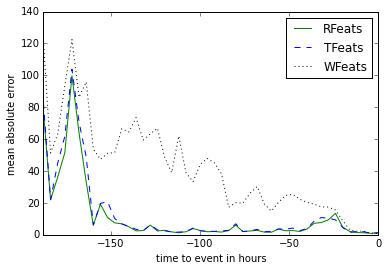

```python
myLineStyles = ['g-','b--','k:', 'r-.']
rulesHistDF['error'] = np.abs(rulesHistDF.time_to_eventhF - rulesHistDF.histMed_rulesMeaSerie)
rulesTmxHistDF['error'] = np.abs(rulesTmxHistDF.time_to_eventhF - rulesTmxHistDF.histMed_rulesAndTrain)
rulesTmxLexHistDF['error'] = np.abs(rulesTmxLexHistDF.time_to_eventhF - rulesTmxLexHistDF.histMed_rulesTFeatsWFeats)

gatherPeriod=4
fieldName = 'time_to_event'+str(gatherPeriod)+'h'
rulesHistDF[fieldName] = rulesHistDF.time_to_event.apply(lambda x: int(-x/np.timedelta64(gatherPeriod, 'h')))
rulesTmxHistDF[fieldName] = rulesTmxHistDF.time_to_event.apply(lambda x: int(-x/np.timedelta64(gatherPeriod, 'h')))
rulesTmxLexHistDF[fieldName] = rulesTmxLexHistDF.time_to_event.apply(lambda x: int(-x/np.timedelta64(gatherPeriod, 'h')))

averagedPeriod = pd.DataFrame([rulesHistDF.groupby(fieldName)['error'].mean(),rulesTmxHistDF.groupby(fieldName)['error'].mean(),\
              rulesTmxLexHistDF.groupby(fieldName)['error'].mean()], index=['RFeats','TFeats','WFeats']).T

averagedPeriod.index = averagedPeriod.index*gatherPeriod
fig, ax = plt.subplots()
averagedPeriod.plot(grid=False, ax=ax, style=myLineStyles)
plt.xlabel("time to event in hours"), plt.ylabel('mean absolute error')
fig.savefig("FSetBasedPerfRelStartTime.eps", format='eps')
```

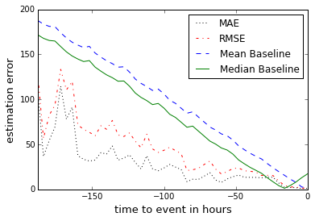

```python
myfig, myDF = getErrorPerTTEFig(tstResultDFT.time_to_event, tstResultDFT.time_to_eventhF, tstResultDFT.priorityALLEst,\
                                medBaseHistDF.histMed_medianBase, meaBaseHistDF.histMed_meanBase, gather_period=4)
myfig.savefig('MAE_RMSE_RelativeToStartTime.eps', format='eps')
```

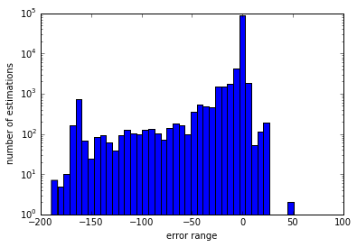

```python
errorTRW = tstResultDFT.time_to_eventhF - tstResultDFT.priorityALLEst
errorTRW.dropna(inplace=True)

fig, ax = plt.subplots()
errorTRW.hist(ax=ax,bins=40,bottom=0, grid=False)
plt.xlabel("error range"), plt.ylabel("number of estimations")
ax.set_yscale('log')
fig.savefig('ErrorCountDistribution.eps', format='eps')
```

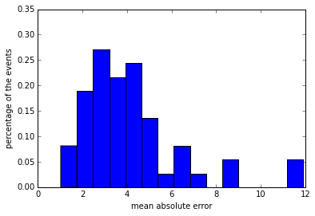

```python
fig, ax = plt.subplots()
plt.xlabel("mean absolute error"), plt.ylabel("percentage of the events")
plt.hist(list(tstResultDFT.groupby("event").apply(lambda g: (getMAE(g.time_to_eventhF,g.priorityALLEst)))), bins=15, normed=True)
ax.set_ylim([0,0.35])
fig.savefig('perEventMAEFigure.eps', format='eps')
```

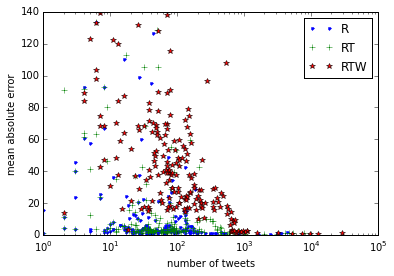

```python
rulesHistDF["time_to_eventh"] = rulesHistDF.time_to_event.apply(lambda x: int(-x/np.timedelta64(1, 'h')))
twCntErrR = pd.DataFrame([rulesHistDF.groupby("time_to_eventh")["error"].mean(), rulesHistDF.groupby("time_to_eventh").apply(lambda x:len(x))], index=['mean error','tweet count']).T
#twCntErr.plot(y='mean error', x='tweet count', style='bo', logx=True) # rulesTmxHistDF

rulesTmxHistDF["time_to_eventh"] = rulesTmxHistDF.time_to_event.apply(lambda x: int(-x/np.timedelta64(1, 'h')))
twCntErrRT = pd.DataFrame([rulesTmxHistDF.groupby("time_to_eventh")["error"].mean(), rulesTmxHistDF.groupby("time_to_eventh").apply(lambda x:len(x))], index=['mean error','tweet count']).T
#twCntErr.plot(y='mean error', x='tweet count', style='bo', logx=True) # rulesTmxHistDFM

rulesTmxLexHistDF["time_to_eventh"] = rulesTmxLexHistDF.time_to_event.apply(lambda x: int(-x/np.timedelta64(1, 'h')))
twCntErrRTW = pd.DataFrame([rulesTmxLexHistDF.groupby("time_to_eventh")["error"].mean(), rulesTmxLexHistDF.groupby("time_to_eventh").apply(lambda x:len(x))], index=['mean error','tweet count']).T
#twCntErr.plot(y='mean error', x='tweet count', style='bo', logx=True) # rulesTmxHistDF

fig, ax = plt.subplots()
#ax.margins(0.05) # Optional, just adds 5% padding to the autoscaling
my_markers=['.','+','*']
my_labels=['R','RT','RTW']
plt.xlabel("number of tweets"), plt.ylabel("mean absolute error")
for my_serie, my_mrk, my_l in zip([twCntErrR,twCntErrRT,twCntErrRTW], my_markers, my_labels):
    ax.plot(my_serie["tweet count"], my_serie['mean error'], marker=my_mrk, label=my_l, linestyle='') # linestyle='', ms=12,

ax.set_xscale('log')
ax.legend()
```

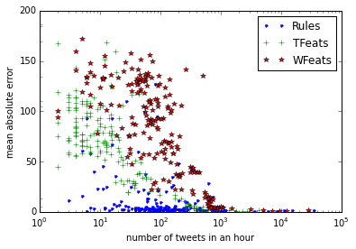

```python
tstResultDFT["time_to_eventh"] = tstResultDFT.time_to_event.apply(lambda x: int(-x/np.timedelta64(1, 'h')))
tstResultDFT["hist_rules_error"] = np.abs(tstResultDFT.time_to_eventhF - tstResultDFT.histMed_rulesMeaSerie)
twCntErrR = pd.DataFrame([tstResultDFT.groupby("time_to_eventh")["hist_rules_error"].mean(), tstResultDFT.groupby("time_to_eventh").apply(lambda x:len(x))], index=['mean error','tweet count']).T

tstResultDFTHist["time_to_eventh"] = tstResultDFTHist.time_to_event.apply(lambda x: int(-x/np.timedelta64(1, 'h')))
tstResultDFTHist["hist_medmed_error"] = np.abs(tstResultDFTHist.time_to_eventhF - tstResultDFTHist.histMed_medMedEstim)
twCntErrRT = pd.DataFrame([tstResultDFTHist.groupby("time_to_eventh")["hist_medmed_error"].mean(), tstResultDFTHist.groupby("time_to_eventh").apply(lambda x:len(x))], index=['mean error','tweet count']).T

resultsDFWHist["time_to_eventh"] = resultsDFWHist.time_to_event.apply(lambda x: int(-x/np.timedelta64(1, 'h')))
resultsDFWHist["hist_medmed_error"] = np.abs(resultsDFWHist.time_to_eventhF - resultsDFWHist.histMed_medMedEstim)
twCntErrRTW = pd.DataFrame([resultsDFWHist.groupby("time_to_eventh")["hist_medmed_error"].mean(), resultsDFWHist.groupby("time_to_eventh").apply(lambda x:len(x))], index=['mean error','tweet count']).T

fig, ax = plt.subplots()
my_markers=['.','+','*']
my_labels=['Rules','TFeats','WFeats']
plt.xlabel("number of tweets in an hour"), plt.ylabel("mean absolute error")
for my_serie, my_mrk, my_l in zip([twCntErrR,twCntErrRT,twCntErrRTW], my_markers, my_labels):
    ax.plot(my_serie["tweet count"], my_serie['mean error'], marker=my_mrk, label=my_l, linestyle='') # linestyle='', ms=12,

ax.set_xscale('log'), ax.legend()
fig.savefig('MAEvsTweetCountCoverage.eps', format='eps')
```

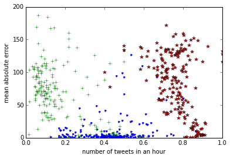

```python
tstResultDFT["time_to_eventh"] = tstResultDFT.time_to_event.apply(lambda x: int(-x/np.timedelta64(1, 'h')))
tstResultDFT["hist_rules_error"] = np.abs(tstResultDFT.time_to_eventhF - tstResultDFT.histMed_rulesMeaSerie)
twCntErrR = pd.DataFrame([tstResultDFT.groupby("time_to_eventh")["hist_rules_error"].mean(), tstResultDFT.groupby("time_to_eventh")["histMed_rulesMeaSerie"].apply(lambda x:x.count()/len(x))], index=['mean error','tweet count']).T

tstResultDFT["time_to_eventh"] = tstResultDFT.time_to_event.apply(lambda x: int(-x/np.timedelta64(1, 'h')))
tstResultDFT["hist_medmed_error"] = np.abs(tstResultDFT.time_to_eventhF - tstResultDFT.histMed_medMedEstim)
twCntErrRT = pd.DataFrame([tstResultDFT.groupby("time_to_eventh")["hist_medmed_error"].mean(), tstResultDFT.groupby("time_to_eventh")["histMed_medMedEstim"].apply(lambda x:x.count()/len(x))], index=['mean error','tweet count']).T

tstResultDFW["time_to_eventh"] = tstResultDFW.time_to_event.apply(lambda x: int(-x/np.timedelta64(1, 'h')))
tstResultDFW["hist_medmed_error"] = np.abs(tstResultDFW.time_to_eventhF - tstResultDFW.histMed_medMedEstim)
twCntErrRTW = pd.DataFrame([tstResultDFW.groupby("time_to_eventh")["hist_medmed_error"].mean(), tstResultDFW.groupby("time_to_eventh")["histMed_medMedEstim"].apply(lambda x:x.count()/len(x))], index=['mean error','tweet count']).T

fig, ax = plt.subplots()
my_markers=['.','+','*']
my_labels=['Rules','TFeats','WFeats']
plt.xlabel("number of tweets in an hour"), plt.ylabel("mean absolute error")
for my_serie, my_mrk, my_l in zip([twCntErrR,twCntErrRT,twCntErrRTW], my_markers, my_labels):
    ax.plot(my_serie["tweet count"], my_serie['mean error'], marker=my_mrk, label=my_l, linestyle='') # linestyle='', ms=12,

#ax.set_xscale('log'),
#ax.legend()
#fig.savefig('MAEvsTweetCountCoverageRelative.eps', format='eps')
```

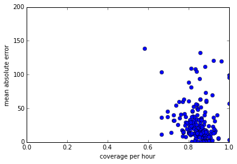

```python
tstResultDFT["time_to_eventh"] = tstResultDFT.time_to_event.apply(lambda x: int(-x/np.timedelta64(1, 'h')))
tstResultDFT["hist_priAll_error"] = np.abs(tstResultDFT.time_to_eventhF - tstResultDFT.priorityALLEst)
twCntErr = pd.DataFrame([tstResultDFT.groupby("time_to_eventh")["hist_priAll_error"].mean(), tstResultDFT.groupby("time_to_eventh")["priorityALLEst"].apply(lambda x:x.count()/len(x))], index=['mean error','coverage']).T

fig, ax = plt.subplots()
twCntErr.plot(y='mean error', x='coverage', style='bo',grid=False, xlim=(0,1), ylim=(0,200), ax=ax)
ax.set_xlabel("coverage per hour"), ax.set_ylabel("mean absolute error")
fig.savefig('coverageMAERelation_FM.eps', format='eps')
```

```python
import scipy
import scipy.stats as stats
```

```python
def p_corr(df1, df2):
    """
    Computes Pearson correlation and its significance (using a t
    distribution) on a pandas.DataFrame.

    Ignores null values when computing significance. Based on
    http://en.wikipedia.org/wiki/Pearson_product-moment_correlation_coefficient#Testing_using_Student.27s_t-distribution

    Args:
        df1 (pandas.DataFrame): one dataset
        df2 (pandas.DataFrame): another dataset

    Returns:
        corr (float): correlation between the two datasets
        t (float): an associated t-value
        p (float): one-tailed p-value that the two datasets differ
    """
    corr = df1.corr(df2)
    N = np.sum(df1.notnull())
    t = corr*np.sqrt((N-2)/(1-corr**2))
    p = 1-scipy.stats.t.cdf(abs(t),N-2)  # one-tailed
    return corr, t, p
```

# Prepare Soccer and Concert Exp Data

ToDo: train soccer, test concert train concert, test concert concert, test merge all and leave one out use_wlistW, use_wlistT, useWordSet : should have been defined!

```python
# Prepare train FM: Football Match
# use train from the previous section FM: Football Match
usePreviousFM_exp = True
if usePreviousFM_exp:
    exp_trainFMW = experimentW.copy()
    exp_trainFMT = experimentT.copy()
    print('The FM data used from previous experiment')
else:
    exp_trainFM = event_table.copy()
    exp_trainFM = exp_trainFM[(exp_trainFM.time_to_event < np.timedelta64(8,'D')) & (exp_trainFM.time_to_event > np.timedelta64(0,'D'))]

    exp_train = getNonRT(exp_train)

    exp_trainFMW = extractFeats(exp_trainFM, use_wlistW)
    exp_trainFMT = extractFeats(exp_trainFM, use_wlistT)
    print('FM data set prepared NOW!')
```

```
The FM data used from previous experiment
```

```python
# prepare test with football WFeats and TFeats list! MC: Music concert
exp_testMC = concert_table.copy()
exp_testMC = exp_testMC[(exp_testMC.time_to_event < np.timedelta64(8,'D')) & (exp_testMC.time_to_event > np.timedelta64(0,'D'))]

exp_testMC = getNonRT(exp_testMC)

exp_testMCW = extractFeats(exp_testMC, use_wlistW)
exp_testMCT = extractFeats(exp_testMC, use_wlistT)
```

## Concert LOO

```python
mc_resultsDict = {"Rules":{},"TFeats":{},"WFeats":{},"Combination":{},"Median Baseline":{},"Mean Baseline":{}}
```

```python
# prepare test with football WFeats and TFeats list!
exp_concert = concert_table.copy()
exp_concertW = extractFeats(exp_concert, use_wlistW)
```

```python
len(exp_concertW.groupby("event").size())
```

[output not shown]

```python
conLOOResultW = run_loo_experimentP(exp_concertW, lComb=2, stdThresh=0.80,throcc=1,excambtmp=False,elimRulesFromTrain=False) # run it with optimized parameters
conLOOResultW.to_pickle(time.strftime("%Y%m%d-%H%M")+"-concertLooW")
```

```
  26/26 tasks finished after  112 s
done
```

```python
#conLOOResultW.to_pickle(time.strftime("%Y%m%d-%H%M"+"-conLOOResultW_journalPaperResults"))
#conLOOResultT.to_pickle(time.strftime("%Y%m%d-%H%M"+"-conLOOResultT_journalPaperResults"))
```

```python
# conLOOResultW = pd.read_pickle('20141024-1105-conLOOResultW_journalPaperResults')
# conLOOResultT = pd.read_pickle('20141024-1105-conLOOResultT_journalPaperResults')
```

```python
#conLOOResultW = pd.read_pickle("20141020-1513-concertLooW")
```

```python
getMAE(conLOOResultW.time_to_eventhF, conLOOResultW.medMeaEstim), conLOOResultW.medMeaEstim.count()/len(conLOOResultW)
```

```
(22.015135682993865, 0.7732106927277953)
```

```python
conLOOResultWHist = conLOOResultW.groupby("event").apply(calcExpandHistNorm, "medMedEstim", 15)

conLOOResultWHist.reset_index(drop=True, level=0, inplace=True)
conLOOResultW = conLOOResultW.join(conLOOResultWHist.histMed_medMedEstim,how='left')

mc_resultsDict["WFeats"]["MAE"] = getMAE(conLOOResultW.time_to_eventhF,conLOOResultW.histMed_medMedEstim)
mc_resultsDict["WFeats"]["RMSE"] = getRMSE(conLOOResultW.time_to_eventhF,conLOOResultW.histMed_medMedEstim)
mc_resultsDict["WFeats"]["Coverage"] = conLOOResultW.histMed_medMedEstim.count()/len(conLOOResultW)
mc_resultsDict["WFeats"]["NRMSE"] = mc_resultsDict["WFeats"]["RMSE"]/192
mc_resultsDict["WFeats"]
```

```
{'MAE': 26.130368214927682,
 'NRMSE': 0.26396690882927065,
 'Coverage': 0.76401264731244611,
 'RMSE': 50.681646495219965}
```

```python
conLOOResultW.groupby("event").apply(lambda g:(getMAE(g.time_to_eventhF,g.medMedEstim),len(g)))
```

```
event
arminvanbuuren_20110409       (44.0204647436, 16)
arminvanbuuren_20130406       (18.3561375661, 31)
arminvanbuuren_20130430       (39.8355138889, 26)
arminvanbuuren_20131116       (20.3423070988, 68)
bastille_20130604             (48.3698015873, 40)
britneyspears_20111019        (15.2350683594, 76)
brucespringsteen_20130622    (17.3994124947, 321)
brunomars_20131015            (14.8781861526, 83)
depechemode_20131207         (11.3947354497, 144)
deus_20111209                 (67.5171219136, 15)
deus_20120630                 (37.4803742284, 23)
drake_20140305                (22.3559207375, 81)
editors_20130708             (38.3720850067, 135)
elbow_20110611                (12.8344331066, 75)
floggingmolly_20111112        (20.8405648148, 16)
guusmeeuwis_20131025          (61.2371478175, 22)
hardwell_20110612             (28.1449198718, 16)
hardwell_20130706             (36.4375752315, 19)
ironmaiden_20110608          (16.1874086006, 358)
johnmayer_20131022            (13.9425772849, 76)
maroon5_20140120              (14.2879555556, 58)
muse_20130604                (14.5468117349, 293)
nickelback_20131118           (20.8851082516, 39)
onedirection_20130503        (26.8376206276, 674)
pink_20130419                (31.8185488889, 167)
racoon_20110617               (91.8971367521, 14)
racoon_20120526               (45.8867063492, 12)
racoon_20131212               (66.6844328704, 14)
rihanna_20111109             (20.7390816993, 336)
rogerwaters_20130718           (19.855703125, 31)
rogerwaters_20130908          (15.4090972222, 50)
sting_20120703                (25.2434740497, 53)
systemofadown_20130821        (12.0440277778, 18)
vanvelzen_20110709             (72.140390625, 26)
volbeat_20111115              (10.5370287037, 93)
dtype: object
```

```python
conLOOResultT[conLOOResultT.event.isin(['wende_20130419'])][["dt_etime","time_to_event","allFeats","ttext",'meaMeaEstim', 'exactTTEmea', 'dynHoursTTEmea', 'dynDaysTTEmea',\
                                                             'dynMonthsTTEmea']][10:15]
```

```python
exp_concertT = extractFeats(exp_concert, use_wlistT)
conLOOResultT = run_loo_experimentP(exp_concertT,lComb=2, stdThresh=0.75,throcc=1, excambtmp=True, elimRulesFromTrain=False) # run it with optimized parameters
conLOOResultT.to_pickle(time.strftime("%Y%m%d-%H%M")+"-concertLooT")
```

```
  26/26 tasks finished after  114 s
done
```

```python
conLOOResultT[conLOOResultT.ttext.str.contains("binnen ")][["dt_etime","time_to_eventhF","exactTTEmea","ttext","allFeats"]][x:x+10]
```

|  | dt_etime | time_to_eventhF | exactTTEmea | ttext | allFeats |
| --- | --- | --- | --- | --- | --- |
| 4339 | 2013-04-21 18:24:04 | -25.598889 | NaN | we zijn er! nu maar hopen dat we binnen komen met die bewerkte kaartjes! #beyonce http://t.co/8bm9dpblx6 | [nu] |
| 4569 | 2013-04-22 08:41:14 | -11.312778 | NaN | #beyonce ligt gewoon nu te slapen in hetzelfde land als ik!! waarschijnlijk gewoon binnen een straal van 60 km. | [nu] |
| 4647 | 2013-04-22 13:13:18 | -6.778333 | NaN | mwiihii in de rij voor ziggodome, nog 5 uur te gaan en dan mogen we naar binnen #beyonce | [nog 5 uur, dan] |
| 4726 | 2013-04-22 17:20:26 | -2.659444 | NaN | nu in amsterdam, over uurtje naar binnen #ziggodome #beyonce | [nu, uurtje] |
| 4767 | 2013-04-22 18:56:10 | -1.063889 | NaN | eindelijk binnen #beyonce | [eindelijk] |

```python
conLOOResultT[np.abs(conLOOResultT.time_to_eventhF - conLOOResultT.exactTTEmea)>100][["dt_etime","time_to_eventhF", "exactTTEmea", "allFeats","ttext"]][0:30]
```

|  | dt_etime | time_to_eventhF | exactTTEmea | allFeats | ttext |
| --- | --- | --- | --- | --- | --- |
| 34 | 2012-06-14 08:59:50 | -467.002778 | -24.00 | [nog 1 nachtje, dan] | nog 1 nachtje slapen en dan naar #oslo #sting |
| 1643 | 2013-04-20 19:40:37 | -311.823056 | -168.00 | [volgende week] | yheaaaa nieuwe 1d ketting volgende week binnen #happy #onedirection #love |
| 1655 | 2013-04-22 09:32:06 | -273.965000 | -144.00 | [nog 6 dagen, 3 mei] | #win je hebt nog 6 dagen om kans te maken op de super vip kaarten voor het concert van #onedirection op 3 mei! http://t.co/pglqaabuz9 |
| 1688 | 2013-04-24 20:15:02 | -215.249444 | -432.00 | [nog 18 dagen] | nog 18 dagen ! &lt;3 #onedirection |
| 1695 | 2013-04-25 08:42:25 | -202.793056 | -96.00 | [nog 4 dagen, 3 mei] | je hebt nog 4 dagen om 2 superkaarten voor #onedirection op 3 mei te winnen! #winactie http://t.co/eawr0kq3wg |
| 1762 | 2013-04-27 09:12:57 | -154.284167 | -48.00 | [nog 2 dagen] | #winactie je hebt nog 2 dagen om kans te maken op de #onedirection vip kaarten http://t.co/bq3gaeyn1s |
| 1782 | 2013-04-28 10:57:20 | -128.544444 | -6.00 | [nog 6 uur, 16.00 uur, vandaag] | #winactie je hebt nog 6 uur om 2 #onedirection vip kaarten te winnen! bestellingen die voor 16.00 uur binnen zijn, worden vandaag verstuurd |
| 1790 | 2013-04-28 13:53:22 | -125.610556 | -3.00 | [nog 3 uur] | even een mooie foto, het zijn er 2 en jij kan deze #onedirection vip kaarten winnen! je hebt nog 3 uur! http://t.co/prlykjmjw0 |
| 1791 | 2013-04-28 14:01:44 | -125.471111 | -3.00 | [nog 3 uur] | aftellen is begonnen.. nog 3 uur kans op 2 vip kaarten voor het concert van #onedirection |
| 1793 | 2013-04-28 15:03:22 | -124.443889 | -2.00 | [nog 2 uur] | je hebt nog 2 uur om een t-shirt te bestellen en kans te maken op de 2 vip #onedirection kaarten |
| 1796 | 2013-04-28 16:10:09 | -123.330833 | -1.00 | [nu, al, nog 1 uur] | nu wordt het echt spannend, doe jij al mee? je hebt nog 1 uur om de #onedirection vip kaarten te winnen! |
| 1802 | 2013-04-28 17:50:48 | -121.653333 | -336.00 | [nog 2 weken] | nog 2 weken!! #onedirection |
| 1804 | 2013-04-28 18:16:55 | -121.218056 | -0.10 | [nog 5 minuten, dan] | nog 5 minuten en dan weet je of jij de #onedirection kaarten hebt gewonnen...... |
| 1819 | 2013-04-29 06:45:28 | -108.742222 | 0.00 | [nu, straks] | @mattiewietse plzzz maak het nu bekend ik moet straks werken #onedirection |
| 1824 | 2013-04-29 07:25:57 | -108.067500 | -0.25 | [nog een kwartiertje] | echte grapjassen die @mattiewietze , naja nog een kwartiertje wachten! ookal vanaf 6uur wakker... #qmusic #onedirection |
| 1827 | 2013-04-29 07:41:35 | -107.806944 | -0.10 | [nog 5 min, zo] | @mattiewietze nog 5 min!!! whaaaaa!! duurt zo lang #onedirection &lt;3 |
| 2370 | 2013-05-03 11:46:20 | -7.727778 | -168.00 | [volgende week] | zin in volgende week (: #lovee #onedirection |
| 2567 | 2013-05-03 17:16:54 | -2.218333 | -216.00 | [nog 9 dagen] | nog 9 dagen:o #onedirection |
| 2706 | 2014-01-18 16:55:49 | -50.569722 | -168.00 | [volgende week] | zin in volgende week! #maroon5 #family #171#dinner #sushi #party |
| 2965 | 2013-10-20 12:15:26 | -54.992778 | -168.00 | [zondag, volgende week, weekje] | geniet van de zondag! volgende week een leuk afwisselend druk weekje: #lilwayne #johnmayer #editors http://t.co/m8gx5wzke1 |
| 2966 | 2013-10-20 12:18:02 | -54.949444 | -168.00 | [zondag, volgende week] | @ziggodome: geniet van de zondag! volgende week een leuk afwisselend programma: #lilwayne #johnmayer #editors http://t.co/m8gx5wzke1 |
| 3667 | 2013-10-14 17:25:05 | -26.581944 | -192.00 | [nog 8 dagen, morgen, al] | “@rosa5o1: nog 8 dagen :)))#brunomars #excited 😄 @xlauraoverwijk @christinnaaa_x &amp; @annasophieromx” morgen al :d |
| 3830 | 2013-04-09 17:57:59 | -314.033611 | -168.00 | [volgende week] | elke keer als ik de pepsi reclame zie denk ik aan volgende week , #beyonce |
| 3839 | 2013-04-11 12:19:57 | -271.667500 | -168.00 | [zo, volgende week, dan, jaar] | ohhh ik heb zo'n zin in volgende week zondaggg! dan heb ik gwn mr. ennn mrs. carter in 1 jaar gezien! &amp;lt;3 #jayz #beyonce |
| 4713 | 2013-04-22 16:45:34 | -3.240556 | -336.00 | [nog 2 weken] | ik word zit als ik die filmpjes zie van #beyonce in amsterdam! nog 2 weken en 't is aan belgie!!!!! |

```python
lenres = len(conLOOResultT)
print("Exact rule MAE:", getMAE(conLOOResultT.time_to_eventhF, conLOOResultT.exactTTEmea), conLOOResultT.exactTTEmea.count()/lenres)
print("Dynamic Hours MAE:", getMAE(conLOOResultT.time_to_eventhF, conLOOResultT.dynHoursTTEmea), conLOOResultT.dynHoursTTEmea.count()/lenres)
print("Dynamic Days MAE:", getMAE(conLOOResultT.time_to_eventhF, conLOOResultT.dynDaysTTEmea), conLOOResultT.dynDaysTTEmea.count()/lenres)
print("Dynamic Months MAE",getMAE(conLOOResultT.time_to_eventhF, conLOOResultT.dynMonthsTTEmea), conLOOResultT.dynMonthsTTEmea.count()/lenres)
print("Median Training & Estimation MAE:", getMAE(conLOOResultT.time_to_eventhF, conLOOResultT.medMedEstim), conLOOResultT.medMedEstim.count()/lenres)

conLOOResultT["rulesMeaSerie"] = conLOOResultT[["dynDaysTTEmea","dynHoursTTEmea","dynMonthsTTEmea","exactTTEmea"]].apply(np.mean,1)
print("Mean of Rules combination MAE:",getMAE(conLOOResultT.time_to_eventhF, conLOOResultT.rulesMeaSerie), conLOOResultT.rulesMeaSerie.count()/lenres)

conLOOResultT["rulesAndTrain"] = np.where(conLOOResultT.rulesMeaSerie.notnull(),conLOOResultT.rulesMeaSerie,conLOOResultT.medMedEstim)
print("Mean rule and Temporal exp. train combination MAE:",getMAE(conLOOResultT.time_to_eventhF, conLOOResultT.rulesAndTrain), conLOOResultT.rulesAndTrain.count()/lenres)
```

```
Exact rule MAE: 20.8476298488 0.0485771773498
Dynamic Hours MAE: 8.8046822711 0.169876401265
Dynamic Days MAE: 15.9095629866 0.0451279103191
Dynamic Months MAE 10.8166734417 0.0117849956884
Median Training & Estimation MAE: 11.9024821085 0.282265018684
Mean of Rules combination MAE: 11.6021847063 0.266743317045
Mean rule and Temporal exp. train combination MAE: 11.289418833 0.367346938776
```

```python
conLOOResultTHist = conLOOResultT.groupby("event").apply(calcExpandHistNorm, "medMedEstim", 15)

conLOOResultTHist.reset_index(drop=True, level=0, inplace=True)
conLOOResultT = conLOOResultT.join(conLOOResultTHist.histMed_medMedEstim,how='left')

mc_resultsDict["TFeats"]["MAE"] = getMAE(conLOOResultT.time_to_eventhF,conLOOResultT.histMed_medMedEstim)
mc_resultsDict["TFeats"]["RMSE"] = getRMSE(conLOOResultT.time_to_eventhF,conLOOResultT.histMed_medMedEstim)
mc_resultsDict["TFeats"]["Coverage"] = conLOOResultT.histMed_medMedEstim.count()/len(conLOOResultT)
mc_resultsDict["TFeats"]["NRMSE"] = mc_resultsDict["TFeats"]["RMSE"]/192
mc_resultsDict["TFeats"]
```

```
{'MAE': 13.826614346010047,
 'NRMSE': 0.16338498711506186,
 'Coverage': 0.27335441218741019,
 'RMSE': 31.369917526091879}
```

```python
conLOOResultTHist = conLOOResultT.groupby("event").apply(calcExpandHistNorm, "medMedEstim", 15)

conLOOResultTHist.reset_index(drop=True, level=0, inplace=True)
conLOOResultT = conLOOResultT.join(conLOOResultTHist.histMed_medMedEstim,how='left')

mc_resultsDict["TFeats"]["MAE"] = getMAE(conLOOResultT.time_to_eventhF,conLOOResultT.histMed_medMedEstim)
mc_resultsDict["TFeats"]["RMSE"] = getRMSE(conLOOResultT.time_to_eventhF,conLOOResultT.histMed_medMedEstim)
mc_resultsDict["TFeats"]["Coverage"] = conLOOResultT.histMed_medMedEstim.count()/len(conLOOResultT)
mc_resultsDict["TFeats"]["NRMSE"] = mc_resultsDict["TFeats"]["RMSE"]/192
mc_resultsDict["TFeats"]
```

```
{'MAE': 13.640566367699989,
 'NRMSE': 0.16021126408774605,
 'Coverage': 0.27195225916453536,
 'RMSE': 30.760562704847242}
```

```python
conLOOResultRHist = conLOOResultT.groupby("event").apply(calcExpandHistNorm, "rulesMeaSerie", 15)

conLOOResultRHist.reset_index(drop=True, level=0, inplace=True)
conLOOResultT = conLOOResultT.join(conLOOResultRHist.histMed_rulesMeaSerie,how='left')

mc_resultsDict["Rules"]["MAE"] = getMAE(conLOOResultT.time_to_eventhF,conLOOResultT.histMed_rulesMeaSerie)
mc_resultsDict["Rules"]["RMSE"] = getRMSE(conLOOResultT.time_to_eventhF,conLOOResultT.histMed_rulesMeaSerie)
mc_resultsDict["Rules"]["Coverage"] = conLOOResultT.histMed_rulesMeaSerie.count()/len(conLOOResultT)
mc_resultsDict["Rules"]["NRMSE"] = mc_resultsDict["Rules"]["RMSE"]/192
mc_resultsDict["Rules"]
```

```
{'MAE': 9.5948684576837966,
 'NRMSE': 0.13278293118361975,
 'Coverage': 0.25812014946823802,
 'RMSE': 25.494322787254994}
```

```python
conLOOResultT["rulesTFeatsWFeats"] = np.where(conLOOResultT.rulesAndTrain.notnull(),conLOOResultT.rulesAndTrain,conLOOResultW.medMedEstim)
print("MAE:",getMAE(conLOOResultT.time_to_eventhF,conLOOResultT.rulesTFeatsWFeats), \
      "RMSE:",getRMSE(conLOOResultT.time_to_eventhF,conLOOResultT.rulesTFeatsWFeats))
```

```
MAE: 17.8418269856 RMSE: 38.6781642808
```

```python
# get the rules History function. Rules will be adjusted just according the history of rules etc.
# This is the priority based history integration!
winLen = 15
rulesHistMcDF = conLOOResultT.groupby("event").apply(calcExpandHistNorm, "rulesMeaSerie", winLen)
rulesTmxHistMcDF = conLOOResultT.groupby("event").apply(calcExpandHistNorm, "rulesAndTrain", winLen)
rulesTmxLexHistMcDF = conLOOResultT.groupby("event").apply(calcExpandHistNorm, "rulesTFeatsWFeats", winLen)

print('#Winlen:',winLen,'MAE:',getMAE(rulesHistMcDF.time_to_eventhF,rulesHistMcDF.histMed_rulesMeaSerie),\
      'RMSE',getRMSE(rulesHistMcDF.time_to_eventhF,rulesHistMcDF.histMed_rulesMeaSerie))

print('#Winlen:',winLen,'MAE:',getMAE(rulesTmxHistMcDF.time_to_eventhF,rulesTmxHistMcDF.histMed_rulesAndTrain),\
      'RMSE',getRMSE(rulesTmxHistMcDF.time_to_eventhF,rulesTmxHistMcDF.histMed_rulesAndTrain))

print('#Winlen:',winLen,'MAE:',getMAE(rulesTmxLexHistMcDF.time_to_eventhF,rulesTmxLexHistMcDF.histMed_rulesTFeatsWFeats),\
      'RMSE',getRMSE(rulesTmxLexHistMcDF.time_to_eventhF,rulesTmxLexHistMcDF.histMed_rulesTFeatsWFeats))

rulesHistMcDF.reset_index(drop=True, level=0, inplace=True)#.set_index("twID").head(1)
rulesTmxHistMcDF.reset_index(drop=True, level=0, inplace=True)#.set_index("twID").head(1)
rulesTmxLexHistMcDF.reset_index(drop=True, level=0, inplace=True)#.set_index("twID").head(1)

try:
    conLOOResultT=conLOOResultT.join(rulesHistMcDF.histMed_rulesMeaSerie,how='left')
    conLOOResultT=conLOOResultT.join(rulesTmxHistMcDF.histMed_rulesAndTrain,how='left')
    conLOOResultT=conLOOResultT.join(rulesTmxLexHistMcDF.histMed_rulesTFeatsWFeats,how='left')
    print('new column joined')
except:
    conLOOResultT.update(rulesHistMcDF.histMed_rulesMeaSerie,join='left')
    conLOOResultT.update(rulesTmxHistMcDF.histMed_rulesAndTrain,join='left')
    conLOOResultT.update(rulesTmxLexHistMcDF.histMed_rulesTFeatsWFeats,join='left')
    print("columns updated")
# results before azfey_f11 update
#Winlen: 15 MAE: 9.52402723945 RMSE 25.1184193751
#Winlen: 15 MAE: 9.45563842335 RMSE 25.1595935765
#Winlen: 15 MAE: 19.9208073334 RMSE 43.8230041002

# results before accepting rules in TFeats
#Winlen: 15 MAE: 9.67711294143 RMSE 25.5167139126
#Winlen: 15 MAE: 9.56884147935 RMSE 25.4659874072
#Winlen: 15 MAE: 20.152167768 RMSE 44.1700057005
```

```
#Winlen: 15 MAE: 9.59486845768 RMSE 25.4943227873
#Winlen: 15 MAE: 9.33617123689 RMSE 24.8635105175
#Winlen: 15 MAE: 19.2251078106 RMSE 42.7293446112
columns updated
```

```python
conLOOResultT=conLOOResultT.join(rulesTmxHistMcDF.histMed_rulesAndTrain,how='left')
conLOOResultT=conLOOResultT.join(rulesTmxLexHistMcDF.histMed_rulesTFeatsWFeats,how='left')
```

```python
conLOOResultT["priorityALLEst"] = np.where(conLOOResultT.histMed_rulesMeaSerie.notnull(), conLOOResultT.histMed_rulesMeaSerie, \
             np.where(conLOOResultT.medMedEstim.notnull(), conLOOResultT.histMed_rulesAndTrain,conLOOResultT.histMed_rulesTFeatsWFeats))
getMAE(conLOOResultT.time_to_eventhF,conLOOResultT.priorityALLEst), getRMSE(conLOOResultT.time_to_eventhF,conLOOResultT.priorityALLEst)
```

```
(15.800392190207447, 38.444172363986212)
```

```python
mc_resultsDict["Combination"]["MAE"] = getMAE(conLOOResultT.time_to_eventhF,conLOOResultT.priorityALLEst)
mc_resultsDict["Combination"]["RMSE"] = getRMSE(conLOOResultT.time_to_eventhF,conLOOResultT.priorityALLEst)
mc_resultsDict["Combination"]["Coverage"] = conLOOResultT.priorityALLEst.count()/len(conLOOResultT)
mc_resultsDict["Combination"]["NRMSE"] = mc_resultsDict["Combination"]["RMSE"]/192
mc_resultsDict["Combination"]
```

```
{'MAE': 15.800392190207447,
 'NRMSE': 0.20023006439576152,
 'Coverage': 0.78643288301235992,
 'RMSE': 38.444172363986212}
```

```python
sorted(conLOOResultT.groupby("event").apply(lambda g:(getMAE(g.time_to_eventhF,g.priorityALLEst),len(g))))
```

```
[(2.0037991898148637, 18),
 (2.5563782051278774, 16),
 (2.962465665014403, 321),
 (3.1843709150326704, 58),
 (3.3947460317460463, 144),
 (3.5697814542483335, 83),
 (4.2983672017302563, 293),
 (4.7788372093021794, 50),
 (5.3715715811971645, 76),
 (6.1056693376071092, 76),
 (7.0379895717979704, 358),
 (8.1358130390669245, 93),
 (9.6347888321994706, 75),
 (9.7421913580249448, 68),
 (13.005205761316585, 31),
 (14.539004983036703, 336),
 (16.345913194444524, 31),
 (19.247031249999985, 81),
 (20.160283595761477, 674),
 (26.992932539682407, 39),
 (30.740090811965981, 53),
 (31.046690705129041, 16),
 (32.75056059587827, 167),
 (43.095628387533871, 135),
 (46.980347222221965, 12),
 (54.748268518518564, 26),
 (64.376343954248455, 23),
 (65.265657051282034, 40),
 (66.915468750000002, 16),
 (67.059062499999996, 19),
 (88.523376736111175, 26),
 (94.152756410256274, 22),
 (108.68293749999998, 14),
 (108.93059895833332, 15),
 (114.62647168803412, 14)]
```

```python
meaBaseHistMcDF = conLOOResultT.groupby("event").apply(calcExpandHistNorm, "meanBase", winLen)
medBaseHistMcDF = conLOOResultT.groupby("event").apply(calcExpandHistNorm, "medianBase", winLen)

meaBaseHistMcDF.reset_index(drop=True, level=0, inplace=True)#.set_index("twID").head(1)
medBaseHistMcDF.reset_index(drop=True, level=0, inplace=True)#.set_index("twID").head(1)

try:
    conLOOResultT=conLOOResultT.join(meaBaseHistMcDF.histMed_meanBase,how='left')
    conLOOResultT=conLOOResultT.join(medBaseHistMcDF.histMed_medianBase,how='left')
except:
    conLOOResultT.update(meaBaseHistMcDF.histMed_meanBase,how='left')
    conLOOResultT.update(medBaseHistMcDF.histMed_medianBase,how='left')
```